# Home Credit Default Risk (HCDR)

The course project is based on the [Home Credit Default Risk (HCDR) Kaggle Competition](https://www.kaggle.com/c/home-credit-default-risk/). The goal of this project is to predict whether or not a client will repay a loan. In order to make sure that people who struggle to get loans due to insufficient or non-existent credit histories have a positive loan experience, Home Credit makes use of a variety of alternative data--including telco and transactional information--to predict their clients' repayment abilities.

## Team - Group 4

- Ayush Srivastava
- David Drummond
- Ritu Sanjay
- Vishal Bhalla

# Dataset and how to download

## Back ground Home Credit Group

Many people struggle to get loans due to insufficient or non-existent credit histories. And, unfortunately, this population is often taken advantage of by untrustworthy lenders.

### Home Credit Group

Home Credit strives to broaden financial inclusion for the unbanked population by providing a positive and safe borrowing experience. In order to make sure this underserved population has a positive loan experience, Home Credit makes use of a variety of alternative data--including telco and transactional information--to predict their clients' repayment abilities.

While Home Credit is currently using various statistical and machine learning methods to make these predictions, they're challenging Kagglers to help them unlock the full potential of their data. Doing so will ensure that clients capable of repayment are not rejected and that loans are given with a principal, maturity, and repayment calendar that will empower their clients to be successful.

## Background on the dataset

Home Credit is a non-banking financial institution, founded in 1997 in the Czech Republic.

The company operates in 14 countries (including United States, Russia, Kazahstan, Belarus, China, India) and focuses on lending primarily to people with little or no credit history which will either not obtain loans or became victims of untrustworthly lenders.

Home Credit group has over 29 million customers, total assests of 21 billions Euro, over 160 millions loans, with the majority in Asia and and almost half of them in China (as of 19-05-2018).

While Home Credit is currently using various statistical and machine learning methods to make these predictions, they're challenging Kagglers to help them unlock the full potential of their data. Doing so will ensure that clients capable of repayment are not rejected and that loans are given with a principal, maturity, and repayment calendar that will empower their clients to be successful.

## Data files overview

There are 7 different sources of data:

- **application_train/application_test:** the main training and testing data with information about each loan application at Home Credit. Every loan has its own row and is identified by the feature SK_ID_CURR. The training application data comes with the TARGET indicating **0: the loan was repaid** or **1: the loan was not repaid**. The target variable defines if the client had payment difficulties meaning he/she had late payment more than X days on at least one of the first Y installments of the loan. Such case is marked as 1 while other all other cases as 0.
- **bureau:** data concerning client's previous credits from other financial institutions. Each previous credit has its own row in bureau, but one loan in the application data can have multiple previous credits.
- **bureau_balance:** monthly data about the previous credits in bureau. Each row is one month of a previous credit, and a single previous credit can have multiple rows, one for each month of the credit length.
- **previous_application:** previous applications for loans at Home Credit of clients who have loans in the application data. Each current loan in the application data can have multiple previous loans. Each previous application has one row and is identified by the feature SK_ID_PREV.
- **POS_CASH_BALANCE:** monthly data about previous point of sale or cash loans clients have had with Home Credit. Each row is one month of a previous point of sale or cash loan, and a single previous loan can have many rows.
- **credit_card_balance:** monthly data about previous credit cards clients have had with Home Credit. Each row is one month of a credit card balance, and a single credit card can have many rows.
- **installments_payment:** payment history for previous loans at Home Credit. There is one row for every made payment and one row for every missed payment.

[figure not shown]

### Connect to Google Drive

```python
from google.colab import drive
drive.mount('/content/drive')
```

```python
#DATA_DIR = "/content/drive/My Drive/HCDR" # VB: Changed to load from google drive
DATA_DIR = "C:/Users/Ayush/Desktop/sem 4/aml/project/HCRD"
```

### Imports

```python
import numpy as np
import pandas as pd
from sklearn.preprocessing import LabelEncoder
from sklearn.metrics import roc_auc_score
#from xgboost import XGBClassifier
from lightgbm import LGBMClassifier
import os
import zipfile
from sklearn.metrics import accuracy_score
from sklearn.base import BaseEstimator, TransformerMixin
import matplotlib.pyplot as plt
import seaborn as sns
from sklearn.linear_model import LogisticRegression
from sklearn.model_selection import train_test_split
from sklearn.model_selection import KFold
from sklearn.model_selection import cross_val_score
from sklearn.model_selection import GridSearchCV
from sklearn.impute import SimpleImputer
from sklearn.preprocessing import MinMaxScaler
from sklearn.pipeline import Pipeline, FeatureUnion, make_pipeline
from pandas.plotting import scatter_matrix
from sklearn.preprocessing import StandardScaler
from sklearn.preprocessing import OneHotEncoder
import warnings
from sklearn.feature_selection import SelectKBest
from sklearn.feature_selection import chi2
warnings.filterwarnings('ignore')
pd.set_option('display.max_columns', None) # Allows to display all columns of a DF
'''from keras.models import Sequential
from keras.layers import Dense
from sklearn.metrics import accuracy_score, confusion_matrix, classification_report
from sklearn.model_selection import RandomizedSearchCV'''
```

```
'from keras.models import Sequential\nfrom keras.layers import Dense\nfrom sklearn.metrics import accuracy_score, confusion_matrix, classification_report\nfrom sklearn.model_selection import RandomizedSearchCV'
```

### Helper Functions

```python
def data_stats(ds_name):
    df =  datasets[ds_name]
    print("\n",ds_name,"\n")
    col_list=['Unique','NAN','Nan%','MaxVal','MinVal','Mean']
    dfx=pd.DataFrame(index=df.columns,columns=col_list)
    dfx['Unique']= df.apply(lambda x: len(x.unique()))
    dfx['NAN'] = df.isna().sum()
    dfx['Nan%']= (df.isnull().sum()/df.isnull().count()*100).round(2)

    # Loop to find the Max, Min and calculate the mean
    for i,col in enumerate(df.columns):
        if 'float' in str(df[col].dtype) or 'int' in str(df[col].dtype):
            dfx.at[col,'MaxVal']=str(round(df[col].max(),2))
            dfx.at[col,'MinVal']=str(round(df[col].min(),2))
            dfx.at[col,'Mean']=df[col].mean()
    dfx.fillna('-',inplace=True)
    print("\n",dfx,"\n")

def day_convert(df):
    col_list = list(df.columns)
    for col in col_list:
        if 'DAYS_' in col:
            df[col]=df[col].abs()
    return df

def load_data(in_path, name):
    df = pd.read_csv(in_path)
    reduce_mem_usage(df)
    print("\n")
    print(f"{name}: shape is {df.shape}")
    display(df.head(5))
    return df




# This code has been taken from https://www.mikulskibartosz.name/how-to-reduce-memory-usage-in-pandas/
def reduce_mem_usage(df):
    start_mem = df.memory_usage().sum() / 1024**2
    print('Memory usage of dataframe is {:.2f} MB'.format(start_mem))

    for col in df.columns:
        col_type = df[col].dtype

        if col_type != object:
            c_min = df[col].min()
            c_max = df[col].max()
            if str(col_type)[:3] == 'int':
                if c_min > np.iinfo(np.int8).min and c_max < np.iinfo(np.int8).max:
                    df[col] = df[col].astype(np.int8)
                elif c_min > np.iinfo(np.int16).min and c_max < np.iinfo(np.int16).max:
                    df[col] = df[col].astype(np.int16)
                elif c_min > np.iinfo(np.int32).min and c_max < np.iinfo(np.int32).max:
                    df[col] = df[col].astype(np.int32)
                elif c_min > np.iinfo(np.int64).min and c_max < np.iinfo(np.int64).max:
                    df[col] = df[col].astype(np.int64)
            else:
                if c_min > np.finfo(np.float16).min and c_max < np.finfo(np.float16).max:
                    df[col] = df[col].astype(np.float16)
                elif c_min > np.finfo(np.float32).min and c_max < np.finfo(np.float32).max:
                    df[col] = df[col].astype(np.float32)
                else:
                    df[col] = df[col].astype(np.float64)
        #else:
            #df[col] = df[col].astype('category')

    end_mem = df.memory_usage().sum() / 1024**2
    print('Memory usage after optimization is: {:.2f} MB'.format(end_mem))
    print('Decreased by {:.1f}%'.format(100 * (start_mem - end_mem) / start_mem))

    return df
```

### Helper Classes

```python
# Dataframe Selector
class DataFrameSelector(BaseEstimator, TransformerMixin):
    def __init__(self, attribute_names):
        self.attribute_names = attribute_names
    def fit(self, X, y=None):
        return self
    def transform(self, X):
        #print(len(self.attribute_names))
        #print(len(X.columns))
        return X[self.attribute_names]

# Feature Aggregator
class FeatAggr(BaseEstimator, TransformerMixin):
  def __init__(self, features=None):
    self.features = features
    self.agg_op_features = {}

  def fit(self, X, y=None):
    return self

  def transform(self, X, y=None):
    result = X.groupby(['SK_ID_CURR']).agg(['nunique','mean', 'count', 'std', 'sum', 'min', 'max'])
    result.columns = [ '_'.join(str(i) for i in col) for col in result.columns]
    result.reset_index(inplace=True)
    return result

#Data Merge
class mergeData(BaseEstimator, TransformerMixin):
  def __init__(self, dflst):
    self.dflst = dflst

  def fit(self, X, y=None):
    return self

  def transform(self,X, y = None):
    for i in self.dflst:
        X = X.merge(i, how='left', on='SK_ID_CURR')

    X.replace([np.inf, -np.inf], np.nan, inplace=True)
    X.fillna(0, inplace=True)
    #X.drop(columns=['SK_ID_CURR'])
    return X
```

## Data files overview

### Data Dictionary

As part of the data download comes a Data Dictionary. It named `HomeCredit_columns_description.csv`

[figure not shown]

### Load Data

```python
%%time
datasets={}  # lets store the datasets in a dictionary so we can keep track of them easily

ds_names = ("application_train", "application_test", "bureau", "bureau_balance", "credit_card_balance", "installments_payments", "previous_application", "POS_CASH_balance")

for ds_name in ds_names:
    datasets[ds_name] = load_data(os.path.join(DATA_DIR, f'{ds_name}.csv'), ds_name)
```

```
Memory usage of dataframe is 286.23 MB
Memory usage after optimization is: 92.38 MB
Decreased by 67.7%


application_train: shape is (307511, 122)
```

|  | SK_ID_CURR | TARGET | NAME_CONTRACT_TYPE | CODE_GENDER | FLAG_OWN_CAR | FLAG_OWN_REALTY | CNT_CHILDREN | AMT_INCOME_TOTAL | AMT_CREDIT | AMT_ANNUITY | AMT_GOODS_PRICE | NAME_TYPE_SUITE | NAME_INCOME_TYPE | NAME_EDUCATION_TYPE | NAME_FAMILY_STATUS | NAME_HOUSING_TYPE | REGION_POPULATION_RELATIVE | DAYS_BIRTH | DAYS_EMPLOYED | DAYS_REGISTRATION | DAYS_ID_PUBLISH | OWN_CAR_AGE | FLAG_MOBIL | FLAG_EMP_PHONE | FLAG_WORK_PHONE | FLAG_CONT_MOBILE | FLAG_PHONE | FLAG_EMAIL | OCCUPATION_TYPE | … |
| --- | --- | --- | --- | --- | --- | --- | --- | --- | --- | --- | --- | --- | --- | --- | --- | --- | --- | --- | --- | --- | --- | --- | --- | --- | --- | --- | --- | --- | --- | --- |
| 0 | 100002 | 1 | Cash loans | M | N | Y | 0 | 202500.0 | 406597.5 | 24700.5 | 351000.0 | Unaccompanied | Working | Secondary / secondary special | Single / not married | House / apartment | 0.018799 | -9461 | -637 | -3648.0 | -2120 | NaN | 1 | 1 | 0 | 1 | 1 | 0 | Laborers | … |
| 1 | 100003 | 0 | Cash loans | F | N | N | 0 | 270000.0 | 1293502.5 | 35698.5 | 1129500.0 | Family | State servant | Higher education | Married | House / apartment | 0.003542 | -16765 | -1188 | -1186.0 | -291 | NaN | 1 | 1 | 0 | 1 | 1 | 0 | Core staff | … |
| 2 | 100004 | 0 | Revolving loans | M | Y | Y | 0 | 67500.0 | 135000.0 | 6750.0 | 135000.0 | Unaccompanied | Working | Secondary / secondary special | Single / not married | House / apartment | 0.010033 | -19046 | -225 | -4260.0 | -2531 | 26.0 | 1 | 1 | 1 | 1 | 1 | 0 | Laborers | … |
| 3 | 100006 | 0 | Cash loans | F | N | Y | 0 | 135000.0 | 312682.5 | 29686.5 | 297000.0 | Unaccompanied | Working | Secondary / secondary special | Civil marriage | House / apartment | 0.008018 | -19005 | -3039 | -9832.0 | -2437 | NaN | 1 | 1 | 0 | 1 | 0 | 0 | Laborers | … |
| 4 | 100007 | 0 | Cash loans | M | N | Y | 0 | 121500.0 | 513000.0 | 21865.5 | 513000.0 | Unaccompanied | Working | Secondary / secondary special | Single / not married | House / apartment | 0.028656 | -19932 | -3038 | -4312.0 | -3458 | NaN | 1 | 1 | 0 | 1 | 0 | 0 | Core staff | … |

```
Memory usage of dataframe is 45.00 MB
Memory usage after optimization is: 14.60 MB
Decreased by 67.6%


application_test: shape is (48744, 121)
```

|  | SK_ID_CURR | NAME_CONTRACT_TYPE | CODE_GENDER | FLAG_OWN_CAR | FLAG_OWN_REALTY | CNT_CHILDREN | AMT_INCOME_TOTAL | AMT_CREDIT | AMT_ANNUITY | AMT_GOODS_PRICE | NAME_TYPE_SUITE | NAME_INCOME_TYPE | NAME_EDUCATION_TYPE | NAME_FAMILY_STATUS | NAME_HOUSING_TYPE | REGION_POPULATION_RELATIVE | DAYS_BIRTH | DAYS_EMPLOYED | DAYS_REGISTRATION | DAYS_ID_PUBLISH | OWN_CAR_AGE | FLAG_MOBIL | FLAG_EMP_PHONE | FLAG_WORK_PHONE | FLAG_CONT_MOBILE | FLAG_PHONE | FLAG_EMAIL | OCCUPATION_TYPE | CNT_FAM_MEMBERS | … |
| --- | --- | --- | --- | --- | --- | --- | --- | --- | --- | --- | --- | --- | --- | --- | --- | --- | --- | --- | --- | --- | --- | --- | --- | --- | --- | --- | --- | --- | --- | --- |
| 0 | 100001 | Cash loans | F | N | Y | 0 | 135000.0 | 568800.0 | 20560.5 | 450000.0 | Unaccompanied | Working | Higher education | Married | House / apartment | 0.018845 | -19241 | -2329 | -5168.0 | -812 | NaN | 1 | 1 | 0 | 1 | 0 | 1 | NaN | 2.0 | … |
| 1 | 100005 | Cash loans | M | N | Y | 0 | 99000.0 | 222768.0 | 17370.0 | 180000.0 | Unaccompanied | Working | Secondary / secondary special | Married | House / apartment | 0.035797 | -18064 | -4469 | -9120.0 | -1623 | NaN | 1 | 1 | 0 | 1 | 0 | 0 | Low-skill Laborers | 2.0 | … |
| 2 | 100013 | Cash loans | M | Y | Y | 0 | 202500.0 | 663264.0 | 69777.0 | 630000.0 | NaN | Working | Higher education | Married | House / apartment | 0.019104 | -20038 | -4458 | -2176.0 | -3503 | 5.0 | 1 | 1 | 0 | 1 | 0 | 0 | Drivers | 2.0 | … |
| 3 | 100028 | Cash loans | F | N | Y | 2 | 315000.0 | 1575000.0 | 49018.5 | 1575000.0 | Unaccompanied | Working | Secondary / secondary special | Married | House / apartment | 0.026398 | -13976 | -1866 | -2000.0 | -4208 | NaN | 1 | 1 | 0 | 1 | 1 | 0 | Sales staff | 4.0 | … |
| 4 | 100038 | Cash loans | M | Y | N | 1 | 180000.0 | 625500.0 | 32067.0 | 625500.0 | Unaccompanied | Working | Secondary / secondary special | Married | House / apartment | 0.010033 | -13040 | -2191 | -4000.0 | -4262 | 16.0 | 1 | 1 | 1 | 1 | 0 | 0 | NaN | 3.0 | … |

```
Memory usage of dataframe is 222.62 MB
Memory usage after optimization is: 112.95 MB
Decreased by 49.3%


bureau: shape is (1716428, 17)
```

|  | SK_ID_CURR | SK_ID_BUREAU | CREDIT_ACTIVE | CREDIT_CURRENCY | DAYS_CREDIT | CREDIT_DAY_OVERDUE | DAYS_CREDIT_ENDDATE | DAYS_ENDDATE_FACT | AMT_CREDIT_MAX_OVERDUE | CNT_CREDIT_PROLONG | AMT_CREDIT_SUM | AMT_CREDIT_SUM_DEBT | AMT_CREDIT_SUM_LIMIT | AMT_CREDIT_SUM_OVERDUE | CREDIT_TYPE | DAYS_CREDIT_UPDATE | AMT_ANNUITY |
| --- | --- | --- | --- | --- | --- | --- | --- | --- | --- | --- | --- | --- | --- | --- | --- | --- | --- |
| 0 | 215354 | 5714462 | Closed | currency 1 | -497 | 0 | -153.0 | -153.0 | NaN | 0 | 91323.0 | 0.0 | NaN | 0.0 | Consumer credit | -131 | NaN |
| 1 | 215354 | 5714463 | Active | currency 1 | -208 | 0 | 1075.0 | NaN | NaN | 0 | 225000.0 | 171342.0 | NaN | 0.0 | Credit card | -20 | NaN |
| 2 | 215354 | 5714464 | Active | currency 1 | -203 | 0 | 528.0 | NaN | NaN | 0 | 464323.5 | NaN | NaN | 0.0 | Consumer credit | -16 | NaN |
| 3 | 215354 | 5714465 | Active | currency 1 | -203 | 0 | NaN | NaN | NaN | 0 | 90000.0 | NaN | NaN | 0.0 | Credit card | -16 | NaN |
| 4 | 215354 | 5714466 | Active | currency 1 | -629 | 0 | 1197.0 | NaN | 77674.5 | 0 | 2700000.0 | NaN | NaN | 0.0 | Consumer credit | -21 | NaN |

```
Memory usage of dataframe is 624.85 MB
Memory usage after optimization is: 338.46 MB
Decreased by 45.8%


bureau_balance: shape is (27299925, 3)
```

|  | SK_ID_BUREAU | MONTHS_BALANCE | STATUS |
| --- | --- | --- | --- |
| 0 | 5715448 | 0 | C |
| 1 | 5715448 | -1 | C |
| 2 | 5715448 | -2 | C |
| 3 | 5715448 | -3 | C |
| 4 | 5715448 | -4 | C |

```
Memory usage of dataframe is 184.00 MB
Memory usage after optimization is: 79.00 MB
Decreased by 57.1%


credit_card_balance: shape is (1048575, 23)
```

|  | SK_ID_PREV | SK_ID_CURR | MONTHS_BALANCE | AMT_BALANCE | AMT_CREDIT_LIMIT_ACTUAL | AMT_DRAWINGS_ATM_CURRENT | AMT_DRAWINGS_CURRENT | AMT_DRAWINGS_OTHER_CURRENT | AMT_DRAWINGS_POS_CURRENT | AMT_INST_MIN_REGULARITY | AMT_PAYMENT_CURRENT | AMT_PAYMENT_TOTAL_CURRENT | AMT_RECEIVABLE_PRINCIPAL | AMT_RECIVABLE | AMT_TOTAL_RECEIVABLE | CNT_DRAWINGS_ATM_CURRENT | CNT_DRAWINGS_CURRENT | CNT_DRAWINGS_OTHER_CURRENT | CNT_DRAWINGS_POS_CURRENT | CNT_INSTALMENT_MATURE_CUM | NAME_CONTRACT_STATUS | SK_DPD | SK_DPD_DEF |
| --- | --- | --- | --- | --- | --- | --- | --- | --- | --- | --- | --- | --- | --- | --- | --- | --- | --- | --- | --- | --- | --- | --- | --- |
| 0 | 2562384 | 378907 | -6 | 56.970001 | 135000 | 0.0 | 877.5 | 0.0 | 877.5 | 1700.324951 | 1800.0 | 1800.0 | 0.000000 | 0.000000 | 0.000000 | 0.0 | 1 | 0.0 | 1.0 | 35.0 | Active | 0 | 0 |
| 1 | 2582071 | 363914 | -1 | 63975.554688 | 45000 | 2250.0 | 2250.0 | 0.0 | 0.0 | 2250.000000 | 2250.0 | 2250.0 | 60175.078125 | 64875.554688 | 64875.554688 | 1.0 | 1 | 0.0 | 0.0 | 69.0 | Active | 0 | 0 |
| 2 | 1740877 | 371185 | -7 | 31815.224609 | 450000 | 0.0 | 0.0 | 0.0 | 0.0 | 2250.000000 | 2250.0 | 2250.0 | 26926.425781 | 31460.085938 | 31460.085938 | 0.0 | 0 | 0.0 | 0.0 | 30.0 | Active | 0 | 0 |
| 3 | 1389973 | 337855 | -4 | 236572.109375 | 225000 | 2250.0 | 2250.0 | 0.0 | 0.0 | 11795.759766 | 11925.0 | 11925.0 | 224949.281250 | 233048.968750 | 233048.968750 | 1.0 | 1 | 0.0 | 0.0 | 10.0 | Active | 0 | 0 |
| 4 | 1891521 | 126868 | -1 | 453919.468750 | 450000 | 0.0 | 11547.0 | 0.0 | 11547.0 | 22924.890625 | 27000.0 | 27000.0 | 443044.406250 | 453919.468750 | 453919.468750 | 0.0 | 1 | 0.0 | 1.0 | 101.0 | Active | 0 | 0 |

```
Memory usage of dataframe is 830.41 MB
Memory usage after optimization is: 311.40 MB
Decreased by 62.5%


installments_payments: shape is (13605401, 8)
```

|  | SK_ID_PREV | SK_ID_CURR | NUM_INSTALMENT_VERSION | NUM_INSTALMENT_NUMBER | DAYS_INSTALMENT | DAYS_ENTRY_PAYMENT | AMT_INSTALMENT | AMT_PAYMENT |
| --- | --- | --- | --- | --- | --- | --- | --- | --- |
| 0 | 1054186 | 161674 | 1.0 | 6 | -1180.0 | -1187.0 | 6948.359863 | 6948.359863 |
| 1 | 1330831 | 151639 | 0.0 | 34 | -2156.0 | -2156.0 | 1716.525024 | 1716.525024 |
| 2 | 2085231 | 193053 | 2.0 | 1 | -63.0 | -63.0 | 25425.000000 | 25425.000000 |
| 3 | 2452527 | 199697 | 1.0 | 3 | -2418.0 | -2426.0 | 24350.130859 | 24350.130859 |
| 4 | 2714724 | 167756 | 1.0 | 2 | -1383.0 | -1366.0 | 2165.040039 | 2160.584961 |

```
Memory usage of dataframe is 471.48 MB
Memory usage after optimization is: 309.01 MB
Decreased by 34.5%


previous_application: shape is (1670214, 37)
```

|  | SK_ID_PREV | SK_ID_CURR | NAME_CONTRACT_TYPE | AMT_ANNUITY | AMT_APPLICATION | AMT_CREDIT | AMT_DOWN_PAYMENT | AMT_GOODS_PRICE | WEEKDAY_APPR_PROCESS_START | HOUR_APPR_PROCESS_START | FLAG_LAST_APPL_PER_CONTRACT | NFLAG_LAST_APPL_IN_DAY | RATE_DOWN_PAYMENT | RATE_INTEREST_PRIMARY | RATE_INTEREST_PRIVILEGED | NAME_CASH_LOAN_PURPOSE | NAME_CONTRACT_STATUS | DAYS_DECISION | NAME_PAYMENT_TYPE | CODE_REJECT_REASON | NAME_TYPE_SUITE | NAME_CLIENT_TYPE | NAME_GOODS_CATEGORY | NAME_PORTFOLIO | NAME_PRODUCT_TYPE | CHANNEL_TYPE | SELLERPLACE_AREA | NAME_SELLER_INDUSTRY | CNT_PAYMENT | … |
| --- | --- | --- | --- | --- | --- | --- | --- | --- | --- | --- | --- | --- | --- | --- | --- | --- | --- | --- | --- | --- | --- | --- | --- | --- | --- | --- | --- | --- | --- | --- |
| 0 | 2030495 | 271877 | Consumer loans | 1730.430054 | 17145.0 | 17145.0 | 0.0 | 17145.0 | SATURDAY | 15 | Y | 1 | 0.0 | 0.182861 | 0.867188 | XAP | Approved | -73 | Cash through the bank | XAP | NaN | Repeater | Mobile | POS | XNA | Country-wide | 35 | Connectivity | 12.0 | … |
| 1 | 2802425 | 108129 | Cash loans | 25188.615234 | 607500.0 | 679671.0 | NaN | 607500.0 | THURSDAY | 11 | Y | 1 | NaN | NaN | NaN | XNA | Approved | -164 | XNA | XAP | Unaccompanied | Repeater | XNA | Cash | x-sell | Contact center | -1 | XNA | 36.0 | … |
| 2 | 2523466 | 122040 | Cash loans | 15060.735352 | 112500.0 | 136444.5 | NaN | 112500.0 | TUESDAY | 11 | Y | 1 | NaN | NaN | NaN | XNA | Approved | -301 | Cash through the bank | XAP | Spouse, partner | Repeater | XNA | Cash | x-sell | Credit and cash offices | -1 | XNA | 12.0 | … |
| 3 | 2819243 | 176158 | Cash loans | 47041.335938 | 450000.0 | 470790.0 | NaN | 450000.0 | MONDAY | 7 | Y | 1 | NaN | NaN | NaN | XNA | Approved | -512 | Cash through the bank | XAP | NaN | Repeater | XNA | Cash | x-sell | Credit and cash offices | -1 | XNA | 12.0 | … |
| 4 | 1784265 | 202054 | Cash loans | 31924.394531 | 337500.0 | 404055.0 | NaN | 337500.0 | THURSDAY | 9 | Y | 1 | NaN | NaN | NaN | Repairs | Refused | -781 | Cash through the bank | HC | NaN | Repeater | XNA | Cash | walk-in | Credit and cash offices | -1 | XNA | 24.0 | … |

```
Memory usage of dataframe is 610.43 MB
Memory usage after optimization is: 238.45 MB
Decreased by 60.9%


POS_CASH_balance: shape is (10001358, 8)
```

|  | SK_ID_PREV | SK_ID_CURR | MONTHS_BALANCE | CNT_INSTALMENT | CNT_INSTALMENT_FUTURE | NAME_CONTRACT_STATUS | SK_DPD | SK_DPD_DEF |
| --- | --- | --- | --- | --- | --- | --- | --- | --- |
| 0 | 1803195 | 182943 | -31 | 48.0 | 45.0 | Active | 0 | 0 |
| 1 | 1715348 | 367990 | -33 | 36.0 | 35.0 | Active | 0 | 0 |
| 2 | 1784872 | 397406 | -32 | 12.0 | 9.0 | Active | 0 | 0 |
| 3 | 1903291 | 269225 | -35 | 48.0 | 42.0 | Active | 0 | 0 |
| 4 | 2341044 | 334279 | -35 | 36.0 | 35.0 | Active | 0 | 0 |

```
Wall time: 6min 12s
```

### Application train/test

- **application_train/application_test:** the main training and testing data with information about each loan application at Home Credit. Every loan has its own row and is identified by the feature SK_ID_CURR. The training application data comes with the TARGET indicating **0: the loan was repaid** or **1: the loan was not repaid**. The target variable defines if the client had payment difficulties meaning he/she had late payment more than X days on at least one of the first Y installments of the loan. Such case is marked as 1 while other all other cases as 0.

The application dataset has the most information about the client: Gender, income, family status, education ...

### The Other datasets

- **bureau:** data concerning client's previous credits from other financial institutions. Each previous credit has its own row in bureau, but one loan in the application data can have multiple previous credits.
- **bureau_balance:** monthly data about the previous credits in bureau. Each row is one month of a previous credit, and a single previous credit can have multiple rows, one for each month of the credit length.
- **previous_application:** previous applications for loans at Home Credit of clients who have loans in the application data. Each current loan in the application data can have multiple previous loans. Each previous application has one row and is identified by the feature SK_ID_PREV.
- **POS_CASH_BALANCE:** monthly data about previous point of sale or cash loans clients have had with Home Credit. Each row is one month of a previous point of sale or cash loan, and a single previous loan can have many rows.
- credit_card_balance: monthly data about previous credit cards clients have had with Home Credit. Each row is one month of a credit card balance, and a single credit card can have many rows.
- **installments_payment:** payment history for previous loans at Home Credit. There is one row for every made payment and one row for every missed payment.

```python
for ds_name in datasets.keys():
    print(f'dataset {ds_name:24}: [ {datasets[ds_name].shape[0]:10,}, {datasets[ds_name].shape[1]}]')
```

```
dataset application_train       : [    307,511, 122]
dataset application_test        : [     48,744, 121]
dataset bureau                  : [  1,716,428, 17]
dataset bureau_balance          : [ 27,299,925, 3]
dataset credit_card_balance     : [  1,048,575, 23]
dataset installments_payments   : [ 13,605,401, 8]
dataset previous_application    : [  1,670,214, 37]
dataset POS_CASH_balance        : [ 10,001,358, 8]
```

# Exploratory Data Analysis

## DATASET: Application train

### Summary

```python
datasets["application_train"].info()
```

```
<class 'pandas.core.frame.DataFrame'>
RangeIndex: 307511 entries, 0 to 307510
Columns: 122 entries, SK_ID_CURR to AMT_REQ_CREDIT_BUREAU_YEAR
dtypes: float16(61), float32(4), int16(2), int32(2), int8(37), object(16)
memory usage: 92.4+ MB
```

```python
datasets["application_train"].describe() #numerical only features
```

|  | SK_ID_CURR | TARGET | CNT_CHILDREN | AMT_INCOME_TOTAL | AMT_CREDIT | AMT_ANNUITY | AMT_GOODS_PRICE | REGION_POPULATION_RELATIVE | DAYS_BIRTH | DAYS_EMPLOYED | DAYS_REGISTRATION | DAYS_ID_PUBLISH | OWN_CAR_AGE | FLAG_MOBIL | FLAG_EMP_PHONE | FLAG_WORK_PHONE | FLAG_CONT_MOBILE | FLAG_PHONE | FLAG_EMAIL | CNT_FAM_MEMBERS | REGION_RATING_CLIENT | REGION_RATING_CLIENT_W_CITY | HOUR_APPR_PROCESS_START | REG_REGION_NOT_LIVE_REGION | REG_REGION_NOT_WORK_REGION | LIVE_REGION_NOT_WORK_REGION | REG_CITY_NOT_LIVE_CITY | REG_CITY_NOT_WORK_CITY | LIVE_CITY_NOT_WORK_CITY | … |
| --- | --- | --- | --- | --- | --- | --- | --- | --- | --- | --- | --- | --- | --- | --- | --- | --- | --- | --- | --- | --- | --- | --- | --- | --- | --- | --- | --- | --- | --- | --- |
| count | 307511.000000 | 307511.000000 | 307511.000000 | 3.075110e+05 | 3.075110e+05 | 307499.000000 | 3.072330e+05 | 307511.000000 | 307511.000000 | 307511.000000 | 307511.0 | 307511.000000 | 104582.0 | 307511.000000 | 307511.000000 | 307511.000000 | 307511.000000 | 307511.000000 | 307511.000000 | 307509.0 | 307511.000000 | 307511.000000 | 307511.000000 | 307511.000000 | 307511.000000 | 307511.000000 | 307511.000000 | 307511.000000 | 307511.000000 | … |
| mean | 278180.518577 | 0.080729 | 0.417052 | 1.687391e+05 | 5.988308e+05 | 27110.958984 | 5.379796e+05 | 0.020859 | -16036.995067 | 63815.045904 | NaN | -2994.202373 | NaN | 0.999997 | 0.819889 | 0.199368 | 0.998133 | 0.281066 | 0.056720 | NaN | 2.052463 | 2.031521 | 12.063419 | 0.015144 | 0.050769 | 0.040659 | 0.078173 | 0.230454 | 0.179555 | … |
| std | 102790.175348 | 0.272419 | 0.722121 | 2.371759e+05 | 4.024795e+05 | 14493.233398 | 3.695427e+05 | 0.013824 | 4363.988632 | 141275.766519 | NaN | 1509.450419 | 0.0 | 0.001803 | 0.384280 | 0.399526 | 0.043164 | 0.449521 | 0.231307 | 0.0 | 0.509034 | 0.502737 | 3.265832 | 0.122126 | 0.219526 | 0.197499 | 0.268444 | 0.421124 | 0.383817 | … |
| min | 100002.000000 | 0.000000 | 0.000000 | 2.565000e+04 | 4.500000e+04 | 1615.500000 | 4.050000e+04 | 0.000290 | -25229.000000 | -17912.000000 | -24672.0 | -7197.000000 | 0.0 | 0.000000 | 0.000000 | 0.000000 | 0.000000 | 0.000000 | 0.000000 | 1.0 | 1.000000 | 1.000000 | 0.000000 | 0.000000 | 0.000000 | 0.000000 | 0.000000 | 0.000000 | 0.000000 | … |
| 25% | 189145.500000 | 0.000000 | 0.000000 | 1.125000e+05 | 2.700000e+05 | 16524.000000 | 2.385000e+05 | 0.010010 | -19682.000000 | -2760.000000 | -7480.0 | -4299.000000 | 5.0 | 1.000000 | 1.000000 | 0.000000 | 1.000000 | 0.000000 | 0.000000 | 2.0 | 2.000000 | 2.000000 | 10.000000 | 0.000000 | 0.000000 | 0.000000 | 0.000000 | 0.000000 | 0.000000 | … |
| 50% | 278202.000000 | 0.000000 | 0.000000 | 1.471500e+05 | 5.135310e+05 | 24903.000000 | 4.500000e+05 | 0.018845 | -15750.000000 | -1213.000000 | -4504.0 | -3254.000000 | 9.0 | 1.000000 | 1.000000 | 0.000000 | 1.000000 | 0.000000 | 0.000000 | 2.0 | 2.000000 | 2.000000 | 12.000000 | 0.000000 | 0.000000 | 0.000000 | 0.000000 | 0.000000 | 0.000000 | … |
| 75% | 367142.500000 | 0.000000 | 1.000000 | 2.025000e+05 | 8.086500e+05 | 34596.000000 | 6.795000e+05 | 0.028656 | -12413.000000 | -289.000000 | -2010.0 | -1720.000000 | 15.0 | 1.000000 | 1.000000 | 0.000000 | 1.000000 | 1.000000 | 0.000000 | 3.0 | 2.000000 | 2.000000 | 14.000000 | 0.000000 | 0.000000 | 0.000000 | 0.000000 | 0.000000 | 0.000000 | … |
| max | 456255.000000 | 1.000000 | 19.000000 | 1.170000e+08 | 4.050000e+06 | 258025.500000 | 4.050000e+06 | 0.072510 | -7489.000000 | 365243.000000 | 0.0 | 0.000000 | 91.0 | 1.000000 | 1.000000 | 1.000000 | 1.000000 | 1.000000 | 1.000000 | 20.0 | 3.000000 | 3.000000 | 23.000000 | 1.000000 | 1.000000 | 1.000000 | 1.000000 | 1.000000 | 1.000000 | … |

```python
datasets["application_test"].describe() #numerical only features
```

|  | SK_ID_CURR | CNT_CHILDREN | AMT_INCOME_TOTAL | AMT_CREDIT | AMT_ANNUITY | AMT_GOODS_PRICE | REGION_POPULATION_RELATIVE | DAYS_BIRTH | DAYS_EMPLOYED | DAYS_REGISTRATION | DAYS_ID_PUBLISH | OWN_CAR_AGE | FLAG_MOBIL | FLAG_EMP_PHONE | FLAG_WORK_PHONE | FLAG_CONT_MOBILE | FLAG_PHONE | FLAG_EMAIL | CNT_FAM_MEMBERS | REGION_RATING_CLIENT | REGION_RATING_CLIENT_W_CITY | HOUR_APPR_PROCESS_START | REG_REGION_NOT_LIVE_REGION | REG_REGION_NOT_WORK_REGION | LIVE_REGION_NOT_WORK_REGION | REG_CITY_NOT_LIVE_CITY | REG_CITY_NOT_WORK_CITY | LIVE_CITY_NOT_WORK_CITY | EXT_SOURCE_1 | … |
| --- | --- | --- | --- | --- | --- | --- | --- | --- | --- | --- | --- | --- | --- | --- | --- | --- | --- | --- | --- | --- | --- | --- | --- | --- | --- | --- | --- | --- | --- | --- |
| count | 48744.000000 | 48744.000000 | 4.874400e+04 | 4.874400e+04 | 48720.000000 | 4.874400e+04 | 48744.000000 | 48744.000000 | 48744.000000 | 48744.0 | 48744.000000 | 1.643200e+04 | 48744.000000 | 48744.000000 | 48744.000000 | 48744.000000 | 48744.000000 | 48744.000000 | 4.874400e+04 | 48744.000000 | 48744.000000 | 48744.000000 | 48744.000000 | 48744.000000 | 48744.000000 | 48744.000000 | 48744.000000 | 48744.000000 | 28212.000000 | … |
| mean | 277796.676350 | 0.397054 | 1.784545e+05 | 5.167597e+05 | 29426.343750 | 4.626689e+05 | 0.021240 | -16068.084605 | 67485.366322 | -inf | -3051.712949 | inf | 0.999979 | 0.809720 | 0.204702 | 0.998400 | 0.263130 | 0.162646 | inf | 2.038159 | 2.012596 | 12.007365 | 0.018833 | 0.055166 | 0.042036 | 0.077466 | 0.224664 | 0.174216 | 0.500977 | … |
| std | 103169.547296 | 0.709047 | 1.015237e+05 | 3.653976e+05 | 16016.254883 | 3.366994e+05 | 0.014435 | 4325.900393 | 144348.507136 | inf | 1569.276709 | 1.146094e+01 | 0.004529 | 0.392526 | 0.403488 | 0.039971 | 0.440337 | 0.369046 | 8.906250e-01 | 0.522694 | 0.515804 | 3.278172 | 0.135937 | 0.228306 | 0.200673 | 0.267332 | 0.417365 | 0.379299 | 0.205200 | … |
| min | 100001.000000 | 0.000000 | 2.694150e+04 | 4.500000e+04 | 2295.000000 | 4.500000e+04 | 0.000253 | -25195.000000 | -17463.000000 | -23728.0 | -6348.000000 | 0.000000e+00 | 0.000000 | 0.000000 | 0.000000 | 0.000000 | 0.000000 | 0.000000 | 1.000000e+00 | 1.000000 | -1.000000 | 0.000000 | 0.000000 | 0.000000 | 0.000000 | 0.000000 | 0.000000 | 0.000000 | 0.013458 | … |
| 25% | 188557.750000 | 0.000000 | 1.125000e+05 | 2.606400e+05 | 17973.000000 | 2.250000e+05 | 0.010010 | -19637.000000 | -2910.000000 | -7460.0 | -4448.000000 | 4.000000e+00 | 1.000000 | 1.000000 | 0.000000 | 1.000000 | 0.000000 | 0.000000 | 2.000000e+00 | 2.000000 | 2.000000 | 10.000000 | 0.000000 | 0.000000 | 0.000000 | 0.000000 | 0.000000 | 0.000000 | 0.343750 | … |
| 50% | 277549.000000 | 0.000000 | 1.575000e+05 | 4.500000e+05 | 26199.000000 | 3.960000e+05 | 0.018845 | -15785.000000 | -1293.000000 | -4488.0 | -3234.000000 | 9.000000e+00 | 1.000000 | 1.000000 | 0.000000 | 1.000000 | 0.000000 | 0.000000 | 2.000000e+00 | 2.000000 | 2.000000 | 12.000000 | 0.000000 | 0.000000 | 0.000000 | 0.000000 | 0.000000 | 0.000000 | 0.506836 | … |
| 75% | 367555.500000 | 1.000000 | 2.250000e+05 | 6.750000e+05 | 37390.500000 | 6.300000e+05 | 0.028656 | -12496.000000 | -296.000000 | -1901.0 | -1706.000000 | 1.500000e+01 | 1.000000 | 1.000000 | 0.000000 | 1.000000 | 1.000000 | 0.000000 | 3.000000e+00 | 2.000000 | 2.000000 | 14.000000 | 0.000000 | 0.000000 | 0.000000 | 0.000000 | 0.000000 | 0.000000 | 0.666016 | … |
| max | 456250.000000 | 20.000000 | 4.410000e+06 | 2.245500e+06 | 180576.000000 | 2.245500e+06 | 0.072510 | -7338.000000 | 365243.000000 | 0.0 | 0.000000 | 7.400000e+01 | 1.000000 | 1.000000 | 1.000000 | 1.000000 | 1.000000 | 1.000000 | 2.100000e+01 | 3.000000 | 3.000000 | 23.000000 | 1.000000 | 1.000000 | 1.000000 | 1.000000 | 1.000000 | 1.000000 | 0.938965 | … |

```python
datasets["application_train"].describe(include='all') #look at all categorical and numerical
```

|  | SK_ID_CURR | TARGET | NAME_CONTRACT_TYPE | CODE_GENDER | FLAG_OWN_CAR | FLAG_OWN_REALTY | CNT_CHILDREN | AMT_INCOME_TOTAL | AMT_CREDIT | AMT_ANNUITY | AMT_GOODS_PRICE | NAME_TYPE_SUITE | NAME_INCOME_TYPE | NAME_EDUCATION_TYPE | NAME_FAMILY_STATUS | NAME_HOUSING_TYPE | REGION_POPULATION_RELATIVE | DAYS_BIRTH | DAYS_EMPLOYED | DAYS_REGISTRATION | DAYS_ID_PUBLISH | OWN_CAR_AGE | FLAG_MOBIL | FLAG_EMP_PHONE | FLAG_WORK_PHONE | FLAG_CONT_MOBILE | FLAG_PHONE | FLAG_EMAIL | OCCUPATION_TYPE | … |
| --- | --- | --- | --- | --- | --- | --- | --- | --- | --- | --- | --- | --- | --- | --- | --- | --- | --- | --- | --- | --- | --- | --- | --- | --- | --- | --- | --- | --- | --- | --- |
| count | 307511.000000 | 307511.000000 | 307511 | 307511 | 307511 | 307511 | 307511.000000 | 3.075110e+05 | 3.075110e+05 | 307499.000000 | 3.072330e+05 | 306219 | 307511 | 307511 | 307511 | 307511 | 307511.000000 | 307511.000000 | 307511.000000 | 307511.0 | 307511.000000 | 104582.0 | 307511.000000 | 307511.000000 | 307511.000000 | 307511.000000 | 307511.000000 | 307511.000000 | 211120 | … |
| unique | NaN | NaN | 2 | 3 | 2 | 2 | NaN | NaN | NaN | NaN | NaN | 7 | 8 | 5 | 6 | 6 | NaN | NaN | NaN | NaN | NaN | NaN | NaN | NaN | NaN | NaN | NaN | NaN | 18 | … |
| top | NaN | NaN | Cash loans | F | N | Y | NaN | NaN | NaN | NaN | NaN | Unaccompanied | Working | Secondary / secondary special | Married | House / apartment | NaN | NaN | NaN | NaN | NaN | NaN | NaN | NaN | NaN | NaN | NaN | NaN | Laborers | … |
| freq | NaN | NaN | 278232 | 202448 | 202924 | 213312 | NaN | NaN | NaN | NaN | NaN | 248526 | 158774 | 218391 | 196432 | 272868 | NaN | NaN | NaN | NaN | NaN | NaN | NaN | NaN | NaN | NaN | NaN | NaN | 55186 | … |
| mean | 278180.518577 | 0.080729 | NaN | NaN | NaN | NaN | 0.417052 | 1.687391e+05 | 5.988308e+05 | 27110.958984 | 5.379796e+05 | NaN | NaN | NaN | NaN | NaN | 0.020859 | -16036.995067 | 63815.045904 | NaN | -2994.202373 | NaN | 0.999997 | 0.819889 | 0.199368 | 0.998133 | 0.281066 | 0.056720 | NaN | … |
| std | 102790.175348 | 0.272419 | NaN | NaN | NaN | NaN | 0.722121 | 2.371759e+05 | 4.024795e+05 | 14493.233398 | 3.695427e+05 | NaN | NaN | NaN | NaN | NaN | 0.013824 | 4363.988632 | 141275.766519 | NaN | 1509.450419 | 0.0 | 0.001803 | 0.384280 | 0.399526 | 0.043164 | 0.449521 | 0.231307 | NaN | … |
| min | 100002.000000 | 0.000000 | NaN | NaN | NaN | NaN | 0.000000 | 2.565000e+04 | 4.500000e+04 | 1615.500000 | 4.050000e+04 | NaN | NaN | NaN | NaN | NaN | 0.000290 | -25229.000000 | -17912.000000 | -24672.0 | -7197.000000 | 0.0 | 0.000000 | 0.000000 | 0.000000 | 0.000000 | 0.000000 | 0.000000 | NaN | … |
| 25% | 189145.500000 | 0.000000 | NaN | NaN | NaN | NaN | 0.000000 | 1.125000e+05 | 2.700000e+05 | 16524.000000 | 2.385000e+05 | NaN | NaN | NaN | NaN | NaN | 0.010010 | -19682.000000 | -2760.000000 | -7480.0 | -4299.000000 | 5.0 | 1.000000 | 1.000000 | 0.000000 | 1.000000 | 0.000000 | 0.000000 | NaN | … |
| 50% | 278202.000000 | 0.000000 | NaN | NaN | NaN | NaN | 0.000000 | 1.471500e+05 | 5.135310e+05 | 24903.000000 | 4.500000e+05 | NaN | NaN | NaN | NaN | NaN | 0.018845 | -15750.000000 | -1213.000000 | -4504.0 | -3254.000000 | 9.0 | 1.000000 | 1.000000 | 0.000000 | 1.000000 | 0.000000 | 0.000000 | NaN | … |
| 75% | 367142.500000 | 0.000000 | NaN | NaN | NaN | NaN | 1.000000 | 2.025000e+05 | 8.086500e+05 | 34596.000000 | 6.795000e+05 | NaN | NaN | NaN | NaN | NaN | 0.028656 | -12413.000000 | -289.000000 | -2010.0 | -1720.000000 | 15.0 | 1.000000 | 1.000000 | 0.000000 | 1.000000 | 1.000000 | 0.000000 | NaN | … |
| max | 456255.000000 | 1.000000 | NaN | NaN | NaN | NaN | 19.000000 | 1.170000e+08 | 4.050000e+06 | 258025.500000 | 4.050000e+06 | NaN | NaN | NaN | NaN | NaN | 0.072510 | -7489.000000 | 365243.000000 | 0.0 | 0.000000 | 91.0 | 1.000000 | 1.000000 | 1.000000 | 1.000000 | 1.000000 | 1.000000 | NaN | … |

```python
# Check if all rows are unique
len(datasets["application_train"]["SK_ID_CURR"].unique()) == datasets["application_train"].shape[0]
```

```
True
```

```python
# Check that there is no data leakage
np.intersect1d(datasets["application_train"]["SK_ID_CURR"], datasets["application_test"]["SK_ID_CURR"])
```

```
array([], dtype=int32)
```

```python
application_train=datasets["application_train"]
application_train
```

|  | SK_ID_CURR | TARGET | NAME_CONTRACT_TYPE | CODE_GENDER | FLAG_OWN_CAR | FLAG_OWN_REALTY | CNT_CHILDREN | AMT_INCOME_TOTAL | AMT_CREDIT | AMT_ANNUITY | AMT_GOODS_PRICE | NAME_TYPE_SUITE | NAME_INCOME_TYPE | NAME_EDUCATION_TYPE | NAME_FAMILY_STATUS | NAME_HOUSING_TYPE | REGION_POPULATION_RELATIVE | DAYS_BIRTH | DAYS_EMPLOYED | DAYS_REGISTRATION | DAYS_ID_PUBLISH | OWN_CAR_AGE | FLAG_MOBIL | FLAG_EMP_PHONE | FLAG_WORK_PHONE | FLAG_CONT_MOBILE | FLAG_PHONE | FLAG_EMAIL | OCCUPATION_TYPE | … |
| --- | --- | --- | --- | --- | --- | --- | --- | --- | --- | --- | --- | --- | --- | --- | --- | --- | --- | --- | --- | --- | --- | --- | --- | --- | --- | --- | --- | --- | --- | --- |
| 0 | 100002 | 1 | Cash loans | M | N | Y | 0 | 202500.0 | 406597.5 | 24700.5 | 351000.0 | Unaccompanied | Working | Secondary / secondary special | Single / not married | House / apartment | 0.018799 | -9461 | -637 | -3648.0 | -2120 | NaN | 1 | 1 | 0 | 1 | 1 | 0 | Laborers | … |
| 1 | 100003 | 0 | Cash loans | F | N | N | 0 | 270000.0 | 1293502.5 | 35698.5 | 1129500.0 | Family | State servant | Higher education | Married | House / apartment | 0.003542 | -16765 | -1188 | -1186.0 | -291 | NaN | 1 | 1 | 0 | 1 | 1 | 0 | Core staff | … |
| 2 | 100004 | 0 | Revolving loans | M | Y | Y | 0 | 67500.0 | 135000.0 | 6750.0 | 135000.0 | Unaccompanied | Working | Secondary / secondary special | Single / not married | House / apartment | 0.010033 | -19046 | -225 | -4260.0 | -2531 | 26.0 | 1 | 1 | 1 | 1 | 1 | 0 | Laborers | … |
| 3 | 100006 | 0 | Cash loans | F | N | Y | 0 | 135000.0 | 312682.5 | 29686.5 | 297000.0 | Unaccompanied | Working | Secondary / secondary special | Civil marriage | House / apartment | 0.008018 | -19005 | -3039 | -9832.0 | -2437 | NaN | 1 | 1 | 0 | 1 | 0 | 0 | Laborers | … |
| 4 | 100007 | 0 | Cash loans | M | N | Y | 0 | 121500.0 | 513000.0 | 21865.5 | 513000.0 | Unaccompanied | Working | Secondary / secondary special | Single / not married | House / apartment | 0.028656 | -19932 | -3038 | -4312.0 | -3458 | NaN | 1 | 1 | 0 | 1 | 0 | 0 | Core staff | … |
| ... | ... | ... | ... | ... | ... | ... | ... | ... | ... | ... | ... | ... | ... | ... | ... | ... | ... | ... | ... | ... | ... | ... | ... | ... | ... | ... | ... | ... | ... | … |
| 307506 | 456251 | 0 | Cash loans | M | N | N | 0 | 157500.0 | 254700.0 | 27558.0 | 225000.0 | Unaccompanied | Working | Secondary / secondary special | Separated | With parents | 0.032562 | -9327 | -236 | -8456.0 | -1982 | NaN | 1 | 1 | 0 | 1 | 0 | 0 | Sales staff | … |
| 307507 | 456252 | 0 | Cash loans | F | N | Y | 0 | 72000.0 | 269550.0 | 12001.5 | 225000.0 | Unaccompanied | Pensioner | Secondary / secondary special | Widow | House / apartment | 0.025162 | -20775 | 365243 | -4388.0 | -4090 | NaN | 1 | 0 | 0 | 1 | 1 | 0 | NaN | … |
| 307508 | 456253 | 0 | Cash loans | F | N | Y | 0 | 153000.0 | 677664.0 | 29979.0 | 585000.0 | Unaccompanied | Working | Higher education | Separated | House / apartment | 0.005001 | -14966 | -7921 | -6736.0 | -5150 | NaN | 1 | 1 | 0 | 1 | 0 | 1 | Managers | … |
| 307509 | 456254 | 1 | Cash loans | F | N | Y | 0 | 171000.0 | 370107.0 | 20205.0 | 319500.0 | Unaccompanied | Commercial associate | Secondary / secondary special | Married | House / apartment | 0.005314 | -11961 | -4786 | -2562.0 | -931 | NaN | 1 | 1 | 0 | 1 | 0 | 0 | Laborers | … |
| 307510 | 456255 | 0 | Cash loans | F | N | N | 0 | 157500.0 | 675000.0 | 49117.5 | 675000.0 | Unaccompanied | Commercial associate | Higher education | Married | House / apartment | 0.046234 | -16856 | -1262 | -5128.0 | -410 | NaN | 1 | 1 | 1 | 1 | 1 | 0 | Laborers | … |

307511 rows × 122 columns

```python
# unique catagorical variable values:
print('NAME_CONTRACT_TYPE'," ",application_train['NAME_CONTRACT_TYPE'].unique())
print('CODE_GENDER'," ",application_train['CODE_GENDER'].unique())
print('FLAG_OWN_CAR'," ",application_train['FLAG_OWN_CAR'].unique())
print('FLAG_OWN_REALTY'," ",application_train['FLAG_OWN_REALTY'].unique())
print('NAME_TYPE_SUITE'," ",application_train['NAME_TYPE_SUITE'].unique())
print('NAME_INCOME_TYPE'," ",application_train['NAME_INCOME_TYPE'].unique())
print('NAME_EDUCATION_TYPE'," ",application_train['NAME_EDUCATION_TYPE'].unique())
print('NAME_EDUCATION_TYPE'," ",application_train['NAME_FAMILY_STATUS'].unique())
print('NAME_HOUSING_TYPE'," ",application_train['NAME_HOUSING_TYPE'].unique())
print('OCCUPATION_TYPE'," ",application_train['OCCUPATION_TYPE'].unique())
print('ORGANIZATION_TYPE'," ",application_train['ORGANIZATION_TYPE'].unique())
```

```
NAME_CONTRACT_TYPE   ['Cash loans' 'Revolving loans']
CODE_GENDER   ['M' 'F' 'XNA']
FLAG_OWN_CAR   ['N' 'Y']
FLAG_OWN_REALTY   ['Y' 'N']
NAME_TYPE_SUITE   ['Unaccompanied' 'Family' 'Spouse, partner' 'Children' 'Other_A' nan
 'Other_B' 'Group of people']
NAME_INCOME_TYPE   ['Working' 'State servant' 'Commercial associate' 'Pensioner' 'Unemployed'
 'Student' 'Businessman' 'Maternity leave']
NAME_EDUCATION_TYPE   ['Secondary / secondary special' 'Higher education' 'Incomplete higher'
 'Lower secondary' 'Academic degree']
NAME_EDUCATION_TYPE   ['Single / not married' 'Married' 'Civil marriage' 'Widow' 'Separated'
 'Unknown']
NAME_HOUSING_TYPE   ['House / apartment' 'Rented apartment' 'With parents'
 'Municipal apartment' 'Office apartment' 'Co-op apartment']
OCCUPATION_TYPE   ['Laborers' 'Core staff' 'Accountants' 'Managers' nan 'Drivers'
 'Sales staff' 'Cleaning staff' 'Cooking staff' 'Private service staff'
 'Medicine staff' 'Security staff' 'High skill tech staff'
 'Waiters/barmen staff' 'Low-skill Laborers' 'Realty agents' 'Secretaries'
 'IT staff' 'HR staff']
ORGANIZATION_TYPE   ['Business Entity Type 3' 'School' 'Government' 'Religion' 'Other' 'XNA'
 'Electricity' 'Medicine' 'Business Entity Type 2' 'Self-employed'
 'Transport: type 2' 'Construction' 'Housing' 'Kindergarten'
 'Trade: type 7' 'Industry: type 11' 'Military' 'Services'
 'Security Ministries' 'Transport: type 4' 'Industry: type 1' 'Emergency'
 'Security' 'Trade: type 2' 'University' 'Transport: type 3' 'Police'
 'Business Entity Type 1' 'Postal' 'Industry: type 4' 'Agriculture'
 'Restaurant' 'Culture' 'Hotel' 'Industry: type 7' 'Trade: type 3'
 'Industry: type 3' 'Bank' 'Industry: type 9' 'Insurance' 'Trade: type 6'
 'Industry: type 2' 'Transport: type 1' 'Industry: type 12' 'Mobile'
 'Trade: type 1' 'Industry: type 5' 'Industry: type 10' 'Legal Services'
 'Advertising' 'Trade: type 5' 'Cleaning' 'Industry: type 13'
 'Trade: type 4' 'Telecom' 'Industry: type 8' 'Realtor' 'Industry: type 6']
```

### Distribution of the target column

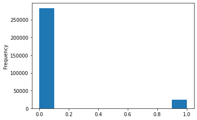

```python
datasets["application_train"]['TARGET'].astype(int).plot.hist();
```

### Correlation with the target column

```python
correlations = datasets["application_train"].corr()['TARGET'].sort_values()
print('Most Positive Correlations:\n', correlations.tail(20))
print('\nMost Negative Correlations:\n', correlations.head(20))
```

```
Most Positive Correlations:
 OBS_30_CNT_SOCIAL_CIRCLE       0.009131
CNT_FAM_MEMBERS                0.009308
CNT_CHILDREN                   0.019187
AMT_REQ_CREDIT_BUREAU_YEAR     0.019930
FLAG_WORK_PHONE                0.028524
DEF_60_CNT_SOCIAL_CIRCLE       0.031276
DEF_30_CNT_SOCIAL_CIRCLE       0.032248
LIVE_CITY_NOT_WORK_CITY        0.032518
OWN_CAR_AGE                    0.037612
DAYS_REGISTRATION              0.041975
FLAG_DOCUMENT_3                0.044346
REG_CITY_NOT_LIVE_CITY         0.044395
FLAG_EMP_PHONE                 0.045982
REG_CITY_NOT_WORK_CITY         0.050994
DAYS_ID_PUBLISH                0.051457
DAYS_LAST_PHONE_CHANGE         0.055219
REGION_RATING_CLIENT           0.058899
REGION_RATING_CLIENT_W_CITY    0.060893
DAYS_BIRTH                     0.078239
TARGET                         1.000000
Name: TARGET, dtype: float64

Most Negative Correlations:
 EXT_SOURCE_3                 -0.178918
EXT_SOURCE_2                 -0.160471
EXT_SOURCE_1                 -0.155318
DAYS_EMPLOYED                -0.044932
FLOORSMAX_AVG                -0.044005
FLOORSMAX_MEDI               -0.043769
FLOORSMAX_MODE               -0.043228
AMT_GOODS_PRICE              -0.039645
REGION_POPULATION_RELATIVE   -0.037231
ELEVATORS_AVG                -0.034199
ELEVATORS_MEDI               -0.033863
FLOORSMIN_AVG                -0.033615
FLOORSMIN_MEDI               -0.033396
LIVINGAREA_AVG               -0.032998
LIVINGAREA_MEDI              -0.032740
FLOORSMIN_MODE               -0.032699
TOTALAREA_MODE               -0.032596
ELEVATORS_MODE               -0.032132
LIVINGAREA_MODE              -0.030684
AMT_CREDIT                   -0.030369
Name: TARGET, dtype: float64
```

### EDA

#### Applicants occupations

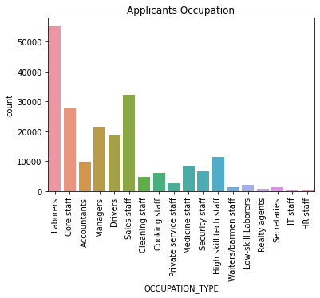

```python
sns.countplot(x='OCCUPATION_TYPE', data=datasets["application_train"]);
plt.title('Applicants Occupation');
plt.xticks(rotation=90);
```

#### Contract Type or Type of Loan

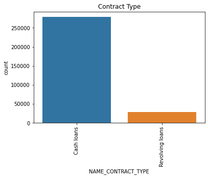

```python
sns.countplot(x='NAME_CONTRACT_TYPE', data=datasets["application_train"]);
plt.title('Contract Type');
plt.xticks(rotation=90);
```

#### Owning a car vs real estate

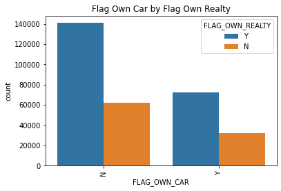

```python
sns.countplot(x='FLAG_OWN_CAR',hue='FLAG_OWN_REALTY', data=application_train);
plt.title('Flag Own Car by Flag Own Realty');
plt.xticks(rotation=90);
```

#### Suite Type - Who accompanied client when applying for loan

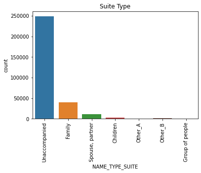

```python
sns.countplot(x='NAME_TYPE_SUITE', data=datasets["application_train"]);
plt.title('Suite Type');
plt.xticks(rotation=90);
# can check by gender
#another option is to check by the type of loan applied for
```

#### Loan Amount by Occupation Type

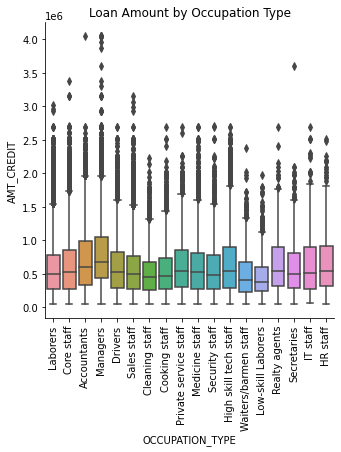

```python
sns.catplot(x="OCCUPATION_TYPE", y="AMT_CREDIT", kind="box", data=application_train);
plt.title('Loan Amount by Occupation Type');
plt.xticks(rotation=90);
```

#### Loan Amount by Income Type

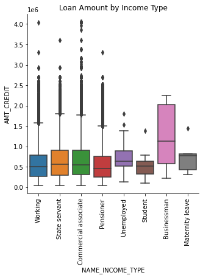

```python
sns.catplot(x="NAME_INCOME_TYPE", y="AMT_CREDIT", kind="box", data=application_train);
plt.title('Loan Amount by Income Type');
plt.xticks(rotation=90);
```

### Feature Selection

Start with the categorical variables first i.e. (chi square) correlation between the categorical variables and the target

```python
# Differentiate between categorical, binary and continuous variables

#cat_var= ["NAME_CONTRACT_TYPE","CODE_GENDER","FLAG_OWN_CAR","FLAG_OWN_REALTY","NAME_TYPE_SUITE","NAME_INCOME_TYPE","NAME_EDUCATION_TYPE",
#          "NAME_FAMILY_STATUS","NAME_HOUSING_TYPE","OCCUPATION_TYPE","WEEKDAY_APPR_PROCESS_START","ORGANIZATION_TYPE","FONDKAPREMONT_MODE",
#         "HOUSETYPE_MODE","WALLSMATERIAL_MODE","EMERGENCYSTATE_MODE"]
#bin_var

g = application_train.columns.to_series().groupby(application_train.dtypes).groups
cat_var=[]
bin_var=[]
cont_var=[]

for key, value in g.items():
    if key=='float64':
        cont_var=value
    elif key=='object':
        cat_var=value
    elif key=='int64':
        bin_var=value

cont_var=list(cont_var)#.tolist()
print(type(cont_var))
print(cont_var)
print(len(cont_var))

print('********************************')

cat_var=list(cat_var)#.tolist()
print(type(cat_var))
print(cat_var)
print(len(cat_var))

print('********************************')

bin_var=list(bin_var)#.tolist()
print(type(bin_var))
print(bin_var)
print(len(bin_var))
```

```
<class 'list'>
[]
0
<class 'list'>
['NAME_CONTRACT_TYPE', 'CODE_GENDER', 'FLAG_OWN_CAR', 'FLAG_OWN_REALTY', 'NAME_TYPE_SUITE', 'NAME_INCOME_TYPE', 'NAME_EDUCATION_TYPE', 'NAME_FAMILY_STATUS', 'NAME_HOUSING_TYPE', 'OCCUPATION_TYPE', 'WEEKDAY_APPR_PROCESS_START', 'ORGANIZATION_TYPE', 'FONDKAPREMONT_MODE', 'HOUSETYPE_MODE', 'WALLSMATERI…
16
<class 'list'>
[]
0
```

```python
# fill all NaN cells with a string 'NaN'
for col in cat_var:
    application_train[col].fillna("NaN", inplace = True)
#application_train[application_train.NAME_TYPE_SUITE=='NaN']
```

```python
y = application_train['TARGET']
cat_train=pd.DataFrame()

for col in cat_var:
    dummy=pd.get_dummies(application_train[col],prefix=col)
    cat_train=pd.concat([cat_train,dummy],axis=1)
cat_train.head()
#print(feature_summary(cat_train))
# copied this code from : https://www.kaggle.com/rahullalu/home-credit-default-risk-eda
print(len(cat_train.columns))
```

```
146
```

```python
chi2_selector_cat = SelectKBest(chi2, k=146)
X_kbest = chi2_selector_cat.fit_transform(cat_train, y)
df_chi_cat=pd.DataFrame(chi2_selector_cat.scores_,columns=['chi_score'])
df_chi_cat['columns']=cat_train.columns
df_chi_cat_s=df_chi_cat.sort_values(by='chi_score')
#display(df_chi_cat_s)
#print(df_chi_cat_s[df_chi_cat_s.chi_score<1])
```

```python
cat_vars_to_drop=df_chi_cat_s[df_chi_cat_s.chi_score>=1]['columns']
cat_vars_to_drop
```

```
90       ORGANIZATION_TYPE_Industry: type 5
84      ORGANIZATION_TYPE_Industry: type 11
63      WEEKDAY_APPR_PROCESS_START_SATURDAY
22                 NAME_INCOME_TYPE_Student
49                 OCCUPATION_TYPE_IT staff
                       ...
24                 NAME_INCOME_TYPE_Working
125                   ORGANIZATION_TYPE_XNA
20               NAME_INCOME_TYPE_Pensioner
3                             CODE_GENDER_M
26     NAME_EDUCATION_TYPE_Higher education
Name: columns, Length: 113, dtype: object
```

```python
dropCols = {}
dropCols['cat_cols'] = cat_vars_to_drop
```

```python
Bin_vars_to_analyze_2 = ['REGION_RATING_CLIENT', 'REGION_RATING_CLIENT_W_CITY', 'HOUR_APPR_PROCESS_START',
                         'REG_REGION_NOT_LIVE_REGION', 'REG_REGION_NOT_WORK_REGION', 'LIVE_REGION_NOT_WORK_REGION',
                         'REG_CITY_NOT_LIVE_CITY', 'REG_CITY_NOT_WORK_CITY', 'LIVE_CITY_NOT_WORK_CITY']
# fill all NaN cells with a string 'NaN'
for col in Bin_vars_to_analyze_2:
    application_train[col].fillna("NaN", inplace = True)
#application_train[application_train.REG_CITY_NOT_LIVE_CITY=='NaN']
```

```python
Bin_vars_to_analyze_2_train=pd.DataFrame()
for col in Bin_vars_to_analyze_2:
    dummy=pd.get_dummies(application_train[col],prefix=col)
    #print(dummy)
    Bin_vars_to_analyze_2_train=pd.concat([Bin_vars_to_analyze_2_train,dummy],axis=1)
Bin_vars_to_analyze_2_train
#print(feature_summary(cat_train))
# copied this code from : https://www.kaggle.com/rahullalu/home-credit-default-risk-eda
print(len(Bin_vars_to_analyze_2_train.columns))
```

```
42
```

```python
chi2_selector_bin = SelectKBest(chi2, k=42)
X_kbest = chi2_selector_bin.fit_transform(Bin_vars_to_analyze_2_train, y)
df_chi_bin=pd.DataFrame(chi2_selector_bin.scores_,columns=['chi_score'])
df_chi_bin['columns']=Bin_vars_to_analyze_2_train.columns
df_chi_bin_s=df_chi_bin.sort_values(by='chi_score')
#display(df_chi_bin_s)
print(df_chi_bin_s[df_chi_bin_s.chi_score<1])
```

```
    chi_score                        columns
17   0.000108     HOUR_APPR_PROCESS_START_11
7    0.000515      HOUR_APPR_PROCESS_START_1
19   0.088800     HOUR_APPR_PROCESS_START_13
34   0.099392  LIVE_REGION_NOT_WORK_REGION_0
10   0.117927      HOUR_APPR_PROCESS_START_4
16   0.132406     HOUR_APPR_PROCESS_START_10
30   0.144792   REG_REGION_NOT_LIVE_REGION_0
15   0.649188      HOUR_APPR_PROCESS_START_9
9    0.650137      HOUR_APPR_PROCESS_START_3
28   0.750647     HOUR_APPR_PROCESS_START_22
32   0.752344   REG_REGION_NOT_WORK_REGION_0
29   0.938811     HOUR_APPR_PROCESS_START_23
```

```python
bin_columns_to_drop = df_chi_bin_s[df_chi_bin_s.chi_score>=1]['columns']
bin_columns_to_drop
```

```
20       HOUR_APPR_PROCESS_START_14
8         HOUR_APPR_PROCESS_START_2
18       HOUR_APPR_PROCESS_START_12
26       HOUR_APPR_PROCESS_START_20
27       HOUR_APPR_PROCESS_START_21
35    LIVE_REGION_NOT_WORK_REGION_1
6         HOUR_APPR_PROCESS_START_0
4     REGION_RATING_CLIENT_W_CITY_2
25       HOUR_APPR_PROCESS_START_19
21       HOUR_APPR_PROCESS_START_15
31     REG_REGION_NOT_LIVE_REGION_1
22       HOUR_APPR_PROCESS_START_16
1            REGION_RATING_CLIENT_2
24       HOUR_APPR_PROCESS_START_18
33     REG_REGION_NOT_WORK_REGION_1
```

[output cut: 16 more lines]

```python
dropCols['bin_cols'] = bin_columns_to_drop
```

A number of documents are required to be submitted by a client when applying for a loan. The dataset description provided outlines 20 documents. Therefore, check correlation between documents and the target.

```python
DOCUMENTS=["FLAG_DOCUMENT_2","FLAG_DOCUMENT_3","FLAG_DOCUMENT_4","FLAG_DOCUMENT_5","FLAG_DOCUMENT_6","FLAG_DOCUMENT_7","FLAG_DOCUMENT_8","FLAG_DOCUMENT_9",
          "FLAG_DOCUMENT_10","FLAG_DOCUMENT_11","FLAG_DOCUMENT_12","FLAG_DOCUMENT_13","FLAG_DOCUMENT_14","FLAG_DOCUMENT_15","FLAG_DOCUMENT_16","FLAG_DOCUMENT_17",
          "FLAG_DOCUMENT_18","FLAG_DOCUMENT_19","FLAG_DOCUMENT_20","FLAG_DOCUMENT_21"]

documents_df = application_train.loc[:, DOCUMENTS]
```

```python
# check which documents are correlated with the target
chi2_selector_doc = SelectKBest(chi2)
X_kbest = chi2_selector_doc.fit_transform(documents_df, y)
df_chi_doc=pd.DataFrame(chi2_selector_doc.scores_,columns=['chi_score'])
df_chi_doc['columns']=documents_df.columns
df_chi_doc_s=df_chi_doc.sort_values(by='chi_score')
#display(df_chi_doc_s)
print(df_chi_doc_s[df_chi_doc_s.chi_score<1])
```

```
    chi_score           columns
18   0.014260  FLAG_DOCUMENT_20
3    0.030200   FLAG_DOCUMENT_5
10   0.175637  FLAG_DOCUMENT_12
17   0.566361  FLAG_DOCUMENT_19
8    0.614728  FLAG_DOCUMENT_10
5    0.709873   FLAG_DOCUMENT_7
```

```python
doc_vars_to_drop=df_chi_doc_s[df_chi_doc_s.chi_score>=1]['columns']
doc_vars_to_drop
```

```
2      FLAG_DOCUMENT_4
15    FLAG_DOCUMENT_17
19    FLAG_DOCUMENT_21
9     FLAG_DOCUMENT_11
7      FLAG_DOCUMENT_9
0      FLAG_DOCUMENT_2
13    FLAG_DOCUMENT_15
6      FLAG_DOCUMENT_8
16    FLAG_DOCUMENT_18
12    FLAG_DOCUMENT_14
14    FLAG_DOCUMENT_16
11    FLAG_DOCUMENT_13
1      FLAG_DOCUMENT_3
4      FLAG_DOCUMENT_6
Name: columns, dtype: object
```

```python
dropCols['doc_vars'] = doc_vars_to_drop
```

```python
Bin_vars_to_analyze =['FLAG_MOBIL', 'FLAG_EMP_PHONE', 'FLAG_WORK_PHONE', 'FLAG_CONT_MOBILE', 'FLAG_PHONE', 'FLAG_EMAIL']

Bin_vars_df = application_train.loc[:, Bin_vars_to_analyze]
```

```python
# check which COLUMNS FROM Bin_vars_to_analyze  are correlated with the target
chi2_selector_flags = SelectKBest(chi2,k=6)
chi2_selector_flags
X_kbest = chi2_selector_flags.fit_transform(Bin_vars_df, y)
df_chi_flags=pd.DataFrame(chi2_selector_flags.scores_,columns=['chi_score'])
df_chi_flags['columns']=Bin_vars_df.columns
df_chi_flags_s=df_chi_flags.sort_values(by='chi_score')
#display(df_chi_flags_s)
print(df_chi_flags_s[df_chi_flags_s.chi_score<1])
```

```
      chi_score           columns
0  2.855786e-07        FLAG_MOBIL
3  7.863447e-05  FLAG_CONT_MOBILE
5  8.968679e-01        FLAG_EMAIL
```

```python
flag_vars_to_drop=df_chi_flags_s[df_chi_flags_s.chi_score>=1]['columns']
flag_vars_to_drop
```

```
1     FLAG_EMP_PHONE
4         FLAG_PHONE
2    FLAG_WORK_PHONE
Name: columns, dtype: object
```

```python
dropCols['flag_vars'] = flag_vars_to_drop
```

```python
#From the above analysis, the following columns are selected:
'''
     chi_score                                   columns
92    0.002709        ORGANIZATION_TYPE_Industry: type 7
68    0.004238             ORGANIZATION_TYPE_Advertising
97    0.017109          ORGANIZATION_TYPE_Legal Services
36    0.029895         NAME_HOUSING_TYPE_Co-op apartment
71    0.034580  ORGANIZATION_TYPE_Business Entity Type 1
56    0.047517             OCCUPATION_TYPE_Realty agents
65    0.051080       WEEKDAY_APPR_PROCESS_START_THURSDAY
11    0.062650           NAME_TYPE_SUITE_Group of people
81    0.065637                 ORGANIZATION_TYPE_Housing
139   0.120730                 WALLSMATERIAL_MODE_Others
91    0.130537        ORGANIZATION_TYPE_Industry: type 6
112   0.155514                 ORGANIZATION_TYPE_Telecom
34    0.175637                NAME_FAMILY_STATUS_Unknown
121   0.214727       ORGANIZATION_TYPE_Transport: type 2
117   0.251180           ORGANIZATION_TYPE_Trade: type 5
134   0.295641             HOUSETYPE_MODE_terraced house
113   0.327077           ORGANIZATION_TYPE_Trade: type 1
4     0.351273                           CODE_GENDER_XNA
61    0.371889         WEEKDAY_APPR_PROCESS_START_FRIDAY
103   0.386722                  ORGANIZATION_TYPE_Postal
32    0.392307              NAME_FAMILY_STATUS_Separated
83    0.400292       ORGANIZATION_TYPE_Industry: type 10
64    0.451054         WEEKDAY_APPR_PROCESS_START_SUNDAY
87    0.464595        ORGANIZATION_TYPE_Industry: type 2
100   0.493985                  ORGANIZATION_TYPE_Mobile
67    0.535490      WEEKDAY_APPR_PROCESS_START_WEDNESDAY
105   0.549597                ORGANIZATION_TYPE_Religion
13    0.576872                   NAME_TYPE_SUITE_Other_A
15    0.620773           NAME_TYPE_SUITE_Spouse, partner
93    0.633842        ORGANIZATION_TYPE_Industry: type 8
78    0.652687               ORGANIZATION_TYPE_Emergency
17    0.878183              NAME_INCOME_TYPE_Businessman
136   0.895626                  WALLSMATERIAL_MODE_Mixed

    chi_score                        columns
17   0.000108     HOUR_APPR_PROCESS_START_11
7    0.000515      HOUR_APPR_PROCESS_START_1
19   0.088800     HOUR_APPR_PROCESS_START_13
34   0.099392  LIVE_REGION_NOT_WORK_REGION_0
10   0.117927      HOUR_APPR_PROCESS_START_4
16   0.132406     HOUR_APPR_PROCESS_START_10
30   0.144792   REG_REGION_NOT_LIVE_REGION_0
15   0.649188      HOUR_APPR_PROCESS_START_9
9    0.650137      HOUR_APPR_PROCESS_START_3
28   0.750647     HOUR_APPR_PROCESS_START_22
32   0.752344   REG_REGION_NOT_WORK_REGION_0
29   0.938811     HOUR_APPR_PROCESS_START_23

    chi_score           columns
18   0.014260  FLAG_DOCUMENT_20
3    0.030200   FLAG_DOCUMENT_5
10   0.175637  FLAG_DOCUMENT_12
17   0.566361  FLAG_DOCUMENT_19
8    0.614728  FLAG_DOCUMENT_10
5    0.709873   FLAG_DOCUMENT_7

      chi_score           columns
0  2.855786e-07        FLAG_MOBIL
3  7.863447e-05  FLAG_CONT_MOBILE
5  8.968679e-01        FLAG_EMAIL

'''
# Additionally, we will continue to use all continuous variables since PCA analysis will be conducted after merging all
# datasets
```

```
'\n     chi_score                                   columns\n92    0.002709        ORGANIZATION_TYPE_Industry: type 7\n68    0.004238             ORGANIZATION_TYPE_Advertising\n97    0.017109          ORGANIZATION_TYPE_Legal Services\n36    0.029895         NAME_HOUSING_TYPE_Co-op apartment\n71    0…
```

```python
# In Application_Train, convert the columns in cat_var to catgorical variables
for col in cat_var:
    application_train[col] = pd.Categorical(application_train[col])
    dfDummies = pd.get_dummies(application_train[col], prefix = col)
    application_train = pd.concat([application_train, dfDummies], axis=1)
#application_train

# Now drop the actual columns (i.e. cat_var)
application_train=application_train.drop(cat_var,axis=1)
#application_train
# Lets try dropping the categorical variables we dont need i.e. cat_vars_to_drop
for col in cat_vars_to_drop:
    application_train=application_train.drop(col,axis=1)
application_train
```

|  | SK_ID_CURR | TARGET | CNT_CHILDREN | AMT_INCOME_TOTAL | AMT_CREDIT | AMT_ANNUITY | AMT_GOODS_PRICE | REGION_POPULATION_RELATIVE | DAYS_BIRTH | DAYS_EMPLOYED | DAYS_REGISTRATION | DAYS_ID_PUBLISH | OWN_CAR_AGE | FLAG_MOBIL | FLAG_EMP_PHONE | FLAG_WORK_PHONE | FLAG_CONT_MOBILE | FLAG_PHONE | FLAG_EMAIL | CNT_FAM_MEMBERS | REGION_RATING_CLIENT | REGION_RATING_CLIENT_W_CITY | HOUR_APPR_PROCESS_START | REG_REGION_NOT_LIVE_REGION | REG_REGION_NOT_WORK_REGION | LIVE_REGION_NOT_WORK_REGION | REG_CITY_NOT_LIVE_CITY | REG_CITY_NOT_WORK_CITY | LIVE_CITY_NOT_WORK_CITY | … |
| --- | --- | --- | --- | --- | --- | --- | --- | --- | --- | --- | --- | --- | --- | --- | --- | --- | --- | --- | --- | --- | --- | --- | --- | --- | --- | --- | --- | --- | --- | --- |
| 0 | 100002 | 1 | 0 | 202500.0 | 406597.5 | 24700.5 | 351000.0 | 0.018799 | -9461 | -637 | -3648.0 | -2120 | NaN | 1 | 1 | 0 | 1 | 1 | 0 | 1.0 | 2 | 2 | 10 | 0 | 0 | 0 | 0 | 0 | 0 | … |
| 1 | 100003 | 0 | 0 | 270000.0 | 1293502.5 | 35698.5 | 1129500.0 | 0.003542 | -16765 | -1188 | -1186.0 | -291 | NaN | 1 | 1 | 0 | 1 | 1 | 0 | 2.0 | 1 | 1 | 11 | 0 | 0 | 0 | 0 | 0 | 0 | … |
| 2 | 100004 | 0 | 0 | 67500.0 | 135000.0 | 6750.0 | 135000.0 | 0.010033 | -19046 | -225 | -4260.0 | -2531 | 26.0 | 1 | 1 | 1 | 1 | 1 | 0 | 1.0 | 2 | 2 | 9 | 0 | 0 | 0 | 0 | 0 | 0 | … |
| 3 | 100006 | 0 | 0 | 135000.0 | 312682.5 | 29686.5 | 297000.0 | 0.008018 | -19005 | -3039 | -9832.0 | -2437 | NaN | 1 | 1 | 0 | 1 | 0 | 0 | 2.0 | 2 | 2 | 17 | 0 | 0 | 0 | 0 | 0 | 0 | … |
| 4 | 100007 | 0 | 0 | 121500.0 | 513000.0 | 21865.5 | 513000.0 | 0.028656 | -19932 | -3038 | -4312.0 | -3458 | NaN | 1 | 1 | 0 | 1 | 0 | 0 | 1.0 | 2 | 2 | 11 | 0 | 0 | 0 | 0 | 1 | 1 | … |
| ... | ... | ... | ... | ... | ... | ... | ... | ... | ... | ... | ... | ... | ... | ... | ... | ... | ... | ... | ... | ... | ... | ... | ... | ... | ... | ... | ... | ... | ... | … |
| 307506 | 456251 | 0 | 0 | 157500.0 | 254700.0 | 27558.0 | 225000.0 | 0.032562 | -9327 | -236 | -8456.0 | -1982 | NaN | 1 | 1 | 0 | 1 | 0 | 0 | 1.0 | 1 | 1 | 15 | 0 | 0 | 0 | 0 | 0 | 0 | … |
| 307507 | 456252 | 0 | 0 | 72000.0 | 269550.0 | 12001.5 | 225000.0 | 0.025162 | -20775 | 365243 | -4388.0 | -4090 | NaN | 1 | 0 | 0 | 1 | 1 | 0 | 1.0 | 2 | 2 | 8 | 0 | 0 | 0 | 0 | 0 | 0 | … |
| 307508 | 456253 | 0 | 0 | 153000.0 | 677664.0 | 29979.0 | 585000.0 | 0.005001 | -14966 | -7921 | -6736.0 | -5150 | NaN | 1 | 1 | 0 | 1 | 0 | 1 | 1.0 | 3 | 3 | 9 | 0 | 0 | 0 | 0 | 1 | 1 | … |
| 307509 | 456254 | 1 | 0 | 171000.0 | 370107.0 | 20205.0 | 319500.0 | 0.005314 | -11961 | -4786 | -2562.0 | -931 | NaN | 1 | 1 | 0 | 1 | 0 | 0 | 2.0 | 2 | 2 | 9 | 0 | 0 | 0 | 1 | 1 | 0 | … |
| 307510 | 456255 | 0 | 0 | 157500.0 | 675000.0 | 49117.5 | 675000.0 | 0.046234 | -16856 | -1262 | -5128.0 | -410 | NaN | 1 | 1 | 1 | 1 | 1 | 0 | 2.0 | 1 | 1 | 20 | 0 | 0 | 0 | 0 | 1 | 1 | … |

307511 rows × 139 columns

```python
# In Application_Train, convert the columns in Bin_vars_to_analyze_2 to catgorical variables
for col in Bin_vars_to_analyze_2:
    application_train[col] = pd.Categorical(application_train[col])
    dfDummies = pd.get_dummies(application_train[col], prefix = col)
    application_train = pd.concat([application_train, dfDummies], axis=1)
#application_train

# Now drop the actual columns (i.e. cat_var)
application_train=application_train.drop(Bin_vars_to_analyze_2,axis=1)
#application_train
# Lets try dropping the categorical variables we dont need i.e. cat_vars_to_drop
for col in bin_columns_to_drop:
    application_train=application_train.drop(col,axis=1)
application_train
```

|  | SK_ID_CURR | TARGET | CNT_CHILDREN | AMT_INCOME_TOTAL | AMT_CREDIT | AMT_ANNUITY | AMT_GOODS_PRICE | REGION_POPULATION_RELATIVE | DAYS_BIRTH | DAYS_EMPLOYED | DAYS_REGISTRATION | DAYS_ID_PUBLISH | OWN_CAR_AGE | FLAG_MOBIL | FLAG_EMP_PHONE | FLAG_WORK_PHONE | FLAG_CONT_MOBILE | FLAG_PHONE | FLAG_EMAIL | CNT_FAM_MEMBERS | EXT_SOURCE_1 | EXT_SOURCE_2 | EXT_SOURCE_3 | APARTMENTS_AVG | BASEMENTAREA_AVG | YEARS_BEGINEXPLUATATION_AVG | YEARS_BUILD_AVG | COMMONAREA_AVG | ELEVATORS_AVG | … |
| --- | --- | --- | --- | --- | --- | --- | --- | --- | --- | --- | --- | --- | --- | --- | --- | --- | --- | --- | --- | --- | --- | --- | --- | --- | --- | --- | --- | --- | --- | --- |
| 0 | 100002 | 1 | 0 | 202500.0 | 406597.5 | 24700.5 | 351000.0 | 0.018799 | -9461 | -637 | -3648.0 | -2120 | NaN | 1 | 1 | 0 | 1 | 1 | 0 | 1.0 | 0.083008 | 0.262939 | 0.139404 | 0.024704 | 0.036896 | 0.972168 | 0.619141 | 0.014297 | 0.000000 | … |
| 1 | 100003 | 0 | 0 | 270000.0 | 1293502.5 | 35698.5 | 1129500.0 | 0.003542 | -16765 | -1188 | -1186.0 | -291 | NaN | 1 | 1 | 0 | 1 | 1 | 0 | 2.0 | 0.311279 | 0.622070 | NaN | 0.095886 | 0.052887 | 0.984863 | 0.795898 | 0.060486 | 0.080017 | … |
| 2 | 100004 | 0 | 0 | 67500.0 | 135000.0 | 6750.0 | 135000.0 | 0.010033 | -19046 | -225 | -4260.0 | -2531 | 26.0 | 1 | 1 | 1 | 1 | 1 | 0 | 1.0 | NaN | 0.556152 | 0.729492 | NaN | NaN | NaN | NaN | NaN | NaN | … |
| 3 | 100006 | 0 | 0 | 135000.0 | 312682.5 | 29686.5 | 297000.0 | 0.008018 | -19005 | -3039 | -9832.0 | -2437 | NaN | 1 | 1 | 0 | 1 | 0 | 0 | 2.0 | NaN | 0.650391 | NaN | NaN | NaN | NaN | NaN | NaN | NaN | … |
| 4 | 100007 | 0 | 0 | 121500.0 | 513000.0 | 21865.5 | 513000.0 | 0.028656 | -19932 | -3038 | -4312.0 | -3458 | NaN | 1 | 1 | 0 | 1 | 0 | 0 | 1.0 | NaN | 0.322754 | NaN | NaN | NaN | NaN | NaN | NaN | NaN | … |
| ... | ... | ... | ... | ... | ... | ... | ... | ... | ... | ... | ... | ... | ... | ... | ... | ... | ... | ... | ... | ... | ... | ... | ... | ... | ... | ... | ... | ... | ... | … |
| 307506 | 456251 | 0 | 0 | 157500.0 | 254700.0 | 27558.0 | 225000.0 | 0.032562 | -9327 | -236 | -8456.0 | -1982 | NaN | 1 | 1 | 0 | 1 | 0 | 0 | 1.0 | 0.145630 | 0.681641 | NaN | 0.202148 | 0.088684 | 0.987793 | 0.830078 | 0.020203 | 0.219971 | … |
| 307507 | 456252 | 0 | 0 | 72000.0 | 269550.0 | 12001.5 | 225000.0 | 0.025162 | -20775 | 365243 | -4388.0 | -4090 | NaN | 1 | 0 | 0 | 1 | 1 | 0 | 1.0 | NaN | 0.115967 | NaN | 0.024704 | 0.043488 | 0.972656 | 0.625977 | 0.002199 | 0.000000 | … |
| 307508 | 456253 | 0 | 0 | 153000.0 | 677664.0 | 29979.0 | 585000.0 | 0.005001 | -14966 | -7921 | -6736.0 | -5150 | NaN | 1 | 1 | 0 | 1 | 0 | 1 | 1.0 | 0.744141 | 0.535645 | 0.218872 | 0.103088 | 0.086182 | 0.981445 | 0.748535 | 0.012299 | 0.000000 | … |
| 307509 | 456254 | 1 | 0 | 171000.0 | 370107.0 | 20205.0 | 319500.0 | 0.005314 | -11961 | -4786 | -2562.0 | -931 | NaN | 1 | 1 | 0 | 1 | 0 | 0 | 2.0 | NaN | 0.514160 | 0.661133 | 0.012398 | NaN | 0.977051 | NaN | NaN | NaN | … |
| 307510 | 456255 | 0 | 0 | 157500.0 | 675000.0 | 49117.5 | 675000.0 | 0.046234 | -16856 | -1262 | -5128.0 | -410 | NaN | 1 | 1 | 1 | 1 | 1 | 0 | 2.0 | 0.734375 | 0.708496 | 0.113953 | 0.074219 | 0.052612 | 0.988281 | NaN | 0.017593 | 0.080017 | … |

307511 rows × 142 columns

```python
# Drop columns from doc_vars_to_drop
for col in doc_vars_to_drop:
    application_train=application_train.drop(col,axis=1)
application_train
```

|  | SK_ID_CURR | TARGET | CNT_CHILDREN | AMT_INCOME_TOTAL | AMT_CREDIT | AMT_ANNUITY | AMT_GOODS_PRICE | REGION_POPULATION_RELATIVE | DAYS_BIRTH | DAYS_EMPLOYED | DAYS_REGISTRATION | DAYS_ID_PUBLISH | OWN_CAR_AGE | FLAG_MOBIL | FLAG_EMP_PHONE | FLAG_WORK_PHONE | FLAG_CONT_MOBILE | FLAG_PHONE | FLAG_EMAIL | CNT_FAM_MEMBERS | EXT_SOURCE_1 | EXT_SOURCE_2 | EXT_SOURCE_3 | APARTMENTS_AVG | BASEMENTAREA_AVG | YEARS_BEGINEXPLUATATION_AVG | YEARS_BUILD_AVG | COMMONAREA_AVG | ELEVATORS_AVG | … |
| --- | --- | --- | --- | --- | --- | --- | --- | --- | --- | --- | --- | --- | --- | --- | --- | --- | --- | --- | --- | --- | --- | --- | --- | --- | --- | --- | --- | --- | --- | --- |
| 0 | 100002 | 1 | 0 | 202500.0 | 406597.5 | 24700.5 | 351000.0 | 0.018799 | -9461 | -637 | -3648.0 | -2120 | NaN | 1 | 1 | 0 | 1 | 1 | 0 | 1.0 | 0.083008 | 0.262939 | 0.139404 | 0.024704 | 0.036896 | 0.972168 | 0.619141 | 0.014297 | 0.000000 | … |
| 1 | 100003 | 0 | 0 | 270000.0 | 1293502.5 | 35698.5 | 1129500.0 | 0.003542 | -16765 | -1188 | -1186.0 | -291 | NaN | 1 | 1 | 0 | 1 | 1 | 0 | 2.0 | 0.311279 | 0.622070 | NaN | 0.095886 | 0.052887 | 0.984863 | 0.795898 | 0.060486 | 0.080017 | … |
| 2 | 100004 | 0 | 0 | 67500.0 | 135000.0 | 6750.0 | 135000.0 | 0.010033 | -19046 | -225 | -4260.0 | -2531 | 26.0 | 1 | 1 | 1 | 1 | 1 | 0 | 1.0 | NaN | 0.556152 | 0.729492 | NaN | NaN | NaN | NaN | NaN | NaN | … |
| 3 | 100006 | 0 | 0 | 135000.0 | 312682.5 | 29686.5 | 297000.0 | 0.008018 | -19005 | -3039 | -9832.0 | -2437 | NaN | 1 | 1 | 0 | 1 | 0 | 0 | 2.0 | NaN | 0.650391 | NaN | NaN | NaN | NaN | NaN | NaN | NaN | … |
| 4 | 100007 | 0 | 0 | 121500.0 | 513000.0 | 21865.5 | 513000.0 | 0.028656 | -19932 | -3038 | -4312.0 | -3458 | NaN | 1 | 1 | 0 | 1 | 0 | 0 | 1.0 | NaN | 0.322754 | NaN | NaN | NaN | NaN | NaN | NaN | NaN | … |
| ... | ... | ... | ... | ... | ... | ... | ... | ... | ... | ... | ... | ... | ... | ... | ... | ... | ... | ... | ... | ... | ... | ... | ... | ... | ... | ... | ... | ... | ... | … |
| 307506 | 456251 | 0 | 0 | 157500.0 | 254700.0 | 27558.0 | 225000.0 | 0.032562 | -9327 | -236 | -8456.0 | -1982 | NaN | 1 | 1 | 0 | 1 | 0 | 0 | 1.0 | 0.145630 | 0.681641 | NaN | 0.202148 | 0.088684 | 0.987793 | 0.830078 | 0.020203 | 0.219971 | … |
| 307507 | 456252 | 0 | 0 | 72000.0 | 269550.0 | 12001.5 | 225000.0 | 0.025162 | -20775 | 365243 | -4388.0 | -4090 | NaN | 1 | 0 | 0 | 1 | 1 | 0 | 1.0 | NaN | 0.115967 | NaN | 0.024704 | 0.043488 | 0.972656 | 0.625977 | 0.002199 | 0.000000 | … |
| 307508 | 456253 | 0 | 0 | 153000.0 | 677664.0 | 29979.0 | 585000.0 | 0.005001 | -14966 | -7921 | -6736.0 | -5150 | NaN | 1 | 1 | 0 | 1 | 0 | 1 | 1.0 | 0.744141 | 0.535645 | 0.218872 | 0.103088 | 0.086182 | 0.981445 | 0.748535 | 0.012299 | 0.000000 | … |
| 307509 | 456254 | 1 | 0 | 171000.0 | 370107.0 | 20205.0 | 319500.0 | 0.005314 | -11961 | -4786 | -2562.0 | -931 | NaN | 1 | 1 | 0 | 1 | 0 | 0 | 2.0 | NaN | 0.514160 | 0.661133 | 0.012398 | NaN | 0.977051 | NaN | NaN | NaN | … |
| 307510 | 456255 | 0 | 0 | 157500.0 | 675000.0 | 49117.5 | 675000.0 | 0.046234 | -16856 | -1262 | -5128.0 | -410 | NaN | 1 | 1 | 1 | 1 | 1 | 0 | 2.0 | 0.734375 | 0.708496 | 0.113953 | 0.074219 | 0.052612 | 0.988281 | NaN | 0.017593 | 0.080017 | … |

307511 rows × 128 columns

```python
# Drop columns from flag_vars_to_drop
for col in flag_vars_to_drop:
    application_train=application_train.drop(col,axis=1)
application_train
```

|  | SK_ID_CURR | TARGET | CNT_CHILDREN | AMT_INCOME_TOTAL | AMT_CREDIT | AMT_ANNUITY | AMT_GOODS_PRICE | REGION_POPULATION_RELATIVE | DAYS_BIRTH | DAYS_EMPLOYED | DAYS_REGISTRATION | DAYS_ID_PUBLISH | OWN_CAR_AGE | FLAG_MOBIL | FLAG_CONT_MOBILE | FLAG_EMAIL | CNT_FAM_MEMBERS | EXT_SOURCE_1 | EXT_SOURCE_2 | EXT_SOURCE_3 | APARTMENTS_AVG | BASEMENTAREA_AVG | YEARS_BEGINEXPLUATATION_AVG | YEARS_BUILD_AVG | COMMONAREA_AVG | ELEVATORS_AVG | ENTRANCES_AVG | FLOORSMAX_AVG | FLOORSMIN_AVG | … |
| --- | --- | --- | --- | --- | --- | --- | --- | --- | --- | --- | --- | --- | --- | --- | --- | --- | --- | --- | --- | --- | --- | --- | --- | --- | --- | --- | --- | --- | --- | --- |
| 0 | 100002 | 1 | 0 | 202500.0 | 406597.5 | 24700.5 | 351000.0 | 0.018799 | -9461 | -637 | -3648.0 | -2120 | NaN | 1 | 1 | 0 | 1.0 | 0.083008 | 0.262939 | 0.139404 | 0.024704 | 0.036896 | 0.972168 | 0.619141 | 0.014297 | 0.000000 | 0.068970 | 0.083313 | 0.125000 | … |
| 1 | 100003 | 0 | 0 | 270000.0 | 1293502.5 | 35698.5 | 1129500.0 | 0.003542 | -16765 | -1188 | -1186.0 | -291 | NaN | 1 | 1 | 0 | 2.0 | 0.311279 | 0.622070 | NaN | 0.095886 | 0.052887 | 0.984863 | 0.795898 | 0.060486 | 0.080017 | 0.034485 | 0.291748 | 0.333252 | … |
| 2 | 100004 | 0 | 0 | 67500.0 | 135000.0 | 6750.0 | 135000.0 | 0.010033 | -19046 | -225 | -4260.0 | -2531 | 26.0 | 1 | 1 | 0 | 1.0 | NaN | 0.556152 | 0.729492 | NaN | NaN | NaN | NaN | NaN | NaN | NaN | NaN | NaN | … |
| 3 | 100006 | 0 | 0 | 135000.0 | 312682.5 | 29686.5 | 297000.0 | 0.008018 | -19005 | -3039 | -9832.0 | -2437 | NaN | 1 | 1 | 0 | 2.0 | NaN | 0.650391 | NaN | NaN | NaN | NaN | NaN | NaN | NaN | NaN | NaN | NaN | … |
| 4 | 100007 | 0 | 0 | 121500.0 | 513000.0 | 21865.5 | 513000.0 | 0.028656 | -19932 | -3038 | -4312.0 | -3458 | NaN | 1 | 1 | 0 | 1.0 | NaN | 0.322754 | NaN | NaN | NaN | NaN | NaN | NaN | NaN | NaN | NaN | NaN | … |
| ... | ... | ... | ... | ... | ... | ... | ... | ... | ... | ... | ... | ... | ... | ... | ... | ... | ... | ... | ... | ... | ... | ... | ... | ... | ... | ... | ... | ... | ... | … |
| 307506 | 456251 | 0 | 0 | 157500.0 | 254700.0 | 27558.0 | 225000.0 | 0.032562 | -9327 | -236 | -8456.0 | -1982 | NaN | 1 | 1 | 0 | 1.0 | 0.145630 | 0.681641 | NaN | 0.202148 | 0.088684 | 0.987793 | 0.830078 | 0.020203 | 0.219971 | 0.103394 | 0.604004 | 0.270752 | … |
| 307507 | 456252 | 0 | 0 | 72000.0 | 269550.0 | 12001.5 | 225000.0 | 0.025162 | -20775 | 365243 | -4388.0 | -4090 | NaN | 1 | 1 | 0 | 1.0 | NaN | 0.115967 | NaN | 0.024704 | 0.043488 | 0.972656 | 0.625977 | 0.002199 | 0.000000 | 0.103394 | 0.083313 | 0.125000 | … |
| 307508 | 456253 | 0 | 0 | 153000.0 | 677664.0 | 29979.0 | 585000.0 | 0.005001 | -14966 | -7921 | -6736.0 | -5150 | NaN | 1 | 1 | 1 | 1.0 | 0.744141 | 0.535645 | 0.218872 | 0.103088 | 0.086182 | 0.981445 | 0.748535 | 0.012299 | 0.000000 | 0.206909 | 0.166748 | 0.208252 | … |
| 307509 | 456254 | 1 | 0 | 171000.0 | 370107.0 | 20205.0 | 319500.0 | 0.005314 | -11961 | -4786 | -2562.0 | -931 | NaN | 1 | 1 | 0 | 2.0 | NaN | 0.514160 | 0.661133 | 0.012398 | NaN | 0.977051 | NaN | NaN | NaN | 0.068970 | 0.041687 | NaN | … |
| 307510 | 456255 | 0 | 0 | 157500.0 | 675000.0 | 49117.5 | 675000.0 | 0.046234 | -16856 | -1262 | -5128.0 | -410 | NaN | 1 | 1 | 0 | 2.0 | 0.734375 | 0.708496 | 0.113953 | 0.074219 | 0.052612 | 0.988281 | NaN | 0.017593 | 0.080017 | 0.068970 | 0.375000 | NaN | … |

307511 rows × 125 columns

```python
def pct(x):
    return round(100*x,3)
```

```python
'''
# Create a class to select numerical or categorical columns
# since Scikit-Learn doesn't handle DataFrames yet
class DataFrameSelector(BaseEstimator, TransformerMixin):
    def __init__(self, attribute_names):
        self.attribute_names = attribute_names
    def fit(self, X, y=None):
        return self
    def transform(self, X):
        return X[self.attribute_names].values
'''
```

```
"\n# Create a class to select numerical or categorical columns \n# since Scikit-Learn doesn't handle DataFrames yet\nclass DataFrameSelector(BaseEstimator, TransformerMixin):\n    def __init__(self, attribute_names):\n        self.attribute_names = attribute_names\n    def fit(self, X, y=None):\n   …
```

```python
selected_columns=list(application_train.columns)
selected_columns.remove('SK_ID_CURR')
selected_columns.remove('TARGET')
```

```python
from sklearn.model_selection import train_test_split
x_train, x_test, y_train, y_test = train_test_split(application_train[selected_columns], application_train['TARGET'], test_size=0.25, random_state=0)
```

```python
num_pipeline = Pipeline([
        ('selector', DataFrameSelector(cont_var)),
        ('imputer', SimpleImputer(strategy='mean')),
        ('std_scaler', StandardScaler()),
    ])
```

```python
'''%%time
np.random.seed(42)
full_pipeline = Pipeline([
        ("preparation", num_pipeline),
        ("linear", LogisticRegression())
    ])
model = full_pipeline.fit(x_train, y_train)'''
```

```
'%%time \nnp.random.seed(42)\nfull_pipeline = Pipeline([\n        ("preparation", num_pipeline),\n        ("linear", LogisticRegression())\n    ])\nmodel = full_pipeline.fit(x_train, y_train)'
```

```python
'''from sklearn.metrics import accuracy_score
np.round(accuracy_score(y_test, model.predict(x_test)), 3)'''
```

```
'from sklearn.metrics import accuracy_score\nnp.round(accuracy_score(y_test, model.predict(x_test)), 3)'
```

```python
# Continuous variables

# convert the birth_days to years
application_train['YEARS_BIRTH']=(application_train['DAYS_BIRTH']/-365)
application_train['YEARS_BIRTH']=application_train['DAYS_BIRTH'].astype(int)
application_train

# convert the days_employed to years
application_train['YEARS_EMPLOYED']=(application_train['DAYS_EMPLOYED']/-365)
application_train['YEARS_EMPLOYED']=application_train['DAYS_EMPLOYED'].astype(int)
application_train

# convert the DAYS_REGISTRATION to years
application_train['YEARS_REGISTRATION']=(application_train['DAYS_REGISTRATION']/-365)
application_train['YEARS_REGISTRATION']=application_train['DAYS_REGISTRATION'].astype(int)
application_train

# convert the DAYS_ID_PUBLISH to years
application_train['YEARS_ID_PUBLISH']=(application_train['DAYS_ID_PUBLISH']/-365)
application_train['YEARS_ID_PUBLISH']=application_train['DAYS_ID_PUBLISH'].astype(int)
application_train

cont_vars_to_drop = ['DAYS_BIRTH','DAYS_EMPLOYED','DAYS_REGISTRATION','DAYS_ID_PUBLISH']
for col in cont_vars_to_drop:
    application_train=application_train.drop(col,axis=1)
```

```python
dropCols['cont_vars'] = cont_vars_to_drop
```

```python
dictlist = []
for key, value in dropCols.items():
    for val in value:
        temp = [key,val]
        dictlist.append(temp)
#dfDropCols = pd.DataFrame(dictlist,columns=['dropCat','dropCol'])
#dfDropCols.to_csv("/content/drive/My Drive/HCDR/dropCols.csv", index=False)
```

## Bureau

### Summary

```python
bureaudf = datasets["bureau"]
```

```python
bureaudf.info()
```

```
<class 'pandas.core.frame.DataFrame'>
RangeIndex: 1716428 entries, 0 to 1716427
Data columns (total 17 columns):
 #   Column                  Dtype
---  ------                  -----
 0   SK_ID_CURR              int32
 1   SK_ID_BUREAU            int32
 2   CREDIT_ACTIVE           object
 3   CREDIT_CURRENCY         object
 4   DAYS_CREDIT             int16
 5   CREDIT_DAY_OVERDUE      int16
 6   DAYS_CREDIT_ENDDATE     float16
 7   DAYS_ENDDATE_FACT       float16
 8   AMT_CREDIT_MAX_OVERDUE  float32
 9   CNT_CREDIT_PROLONG      int8
 10  AMT_CREDIT_SUM          float32
 11  AMT_CREDIT_SUM_DEBT     float32
 12  AMT_CREDIT_SUM_LIMIT    float32
 13  AMT_CREDIT_SUM_OVERDUE  float32
 14  CREDIT_TYPE             object
 15  DAYS_CREDIT_UPDATE      int32
 16  AMT_ANNUITY             float32
dtypes: float16(2), float32(6), int16(2), int32(3), int8(1), object(3)
memory usage: 112.9+ MB
```

```python
bureaudf.head()
```

|  | SK_ID_CURR | SK_ID_BUREAU | CREDIT_ACTIVE | CREDIT_CURRENCY | DAYS_CREDIT | CREDIT_DAY_OVERDUE | DAYS_CREDIT_ENDDATE | DAYS_ENDDATE_FACT | AMT_CREDIT_MAX_OVERDUE | CNT_CREDIT_PROLONG | AMT_CREDIT_SUM | AMT_CREDIT_SUM_DEBT | AMT_CREDIT_SUM_LIMIT | AMT_CREDIT_SUM_OVERDUE | CREDIT_TYPE | DAYS_CREDIT_UPDATE | AMT_ANNUITY |
| --- | --- | --- | --- | --- | --- | --- | --- | --- | --- | --- | --- | --- | --- | --- | --- | --- | --- |
| 0 | 215354 | 5714462 | Closed | currency 1 | -497 | 0 | -153.0 | -153.0 | NaN | 0 | 91323.0 | 0.0 | NaN | 0.0 | Consumer credit | -131 | NaN |
| 1 | 215354 | 5714463 | Active | currency 1 | -208 | 0 | 1075.0 | NaN | NaN | 0 | 225000.0 | 171342.0 | NaN | 0.0 | Credit card | -20 | NaN |
| 2 | 215354 | 5714464 | Active | currency 1 | -203 | 0 | 528.0 | NaN | NaN | 0 | 464323.5 | NaN | NaN | 0.0 | Consumer credit | -16 | NaN |
| 3 | 215354 | 5714465 | Active | currency 1 | -203 | 0 | NaN | NaN | NaN | 0 | 90000.0 | NaN | NaN | 0.0 | Credit card | -16 | NaN |
| 4 | 215354 | 5714466 | Active | currency 1 | -629 | 0 | 1197.0 | NaN | 77674.5 | 0 | 2700000.0 | NaN | NaN | 0.0 | Consumer credit | -21 | NaN |

```python
day_convert(bureaudf)
bureaudf.head()
```

|  | SK_ID_CURR | SK_ID_BUREAU | CREDIT_ACTIVE | CREDIT_CURRENCY | DAYS_CREDIT | CREDIT_DAY_OVERDUE | DAYS_CREDIT_ENDDATE | DAYS_ENDDATE_FACT | AMT_CREDIT_MAX_OVERDUE | CNT_CREDIT_PROLONG | AMT_CREDIT_SUM | AMT_CREDIT_SUM_DEBT | AMT_CREDIT_SUM_LIMIT | AMT_CREDIT_SUM_OVERDUE | CREDIT_TYPE | DAYS_CREDIT_UPDATE | AMT_ANNUITY |
| --- | --- | --- | --- | --- | --- | --- | --- | --- | --- | --- | --- | --- | --- | --- | --- | --- | --- |
| 0 | 215354 | 5714462 | Closed | currency 1 | 497 | 0 | 153.0 | 153.0 | NaN | 0 | 91323.0 | 0.0 | NaN | 0.0 | Consumer credit | 131 | NaN |
| 1 | 215354 | 5714463 | Active | currency 1 | 208 | 0 | 1075.0 | NaN | NaN | 0 | 225000.0 | 171342.0 | NaN | 0.0 | Credit card | 20 | NaN |
| 2 | 215354 | 5714464 | Active | currency 1 | 203 | 0 | 528.0 | NaN | NaN | 0 | 464323.5 | NaN | NaN | 0.0 | Consumer credit | 16 | NaN |
| 3 | 215354 | 5714465 | Active | currency 1 | 203 | 0 | NaN | NaN | NaN | 0 | 90000.0 | NaN | NaN | 0.0 | Credit card | 16 | NaN |
| 4 | 215354 | 5714466 | Active | currency 1 | 629 | 0 | 1197.0 | NaN | 77674.5 | 0 | 2700000.0 | NaN | NaN | 0.0 | Consumer credit | 21 | NaN |

```python
bureaudf.describe(include='all')
```

|  | SK_ID_CURR | SK_ID_BUREAU | CREDIT_ACTIVE | CREDIT_CURRENCY | DAYS_CREDIT | CREDIT_DAY_OVERDUE | DAYS_CREDIT_ENDDATE | DAYS_ENDDATE_FACT | AMT_CREDIT_MAX_OVERDUE | CNT_CREDIT_PROLONG | AMT_CREDIT_SUM | AMT_CREDIT_SUM_DEBT | AMT_CREDIT_SUM_LIMIT | AMT_CREDIT_SUM_OVERDUE | CREDIT_TYPE | DAYS_CREDIT_UPDATE | AMT_ANNUITY |
| --- | --- | --- | --- | --- | --- | --- | --- | --- | --- | --- | --- | --- | --- | --- | --- | --- | --- |
| count | 1.716428e+06 | 1.716428e+06 | 1716428 | 1716428 | 1.716428e+06 | 1.716428e+06 | 1610875.0 | 1082775.0 | 5.919400e+05 | 1.716428e+06 | 1.716415e+06 | 1.458759e+06 | 1.124648e+06 | 1.716428e+06 | 1716428 | 1.716428e+06 | 4.896370e+05 |
| unique | NaN | NaN | 4 | 4 | NaN | NaN | NaN | NaN | NaN | NaN | NaN | NaN | NaN | NaN | 15 | NaN | NaN |
| top | NaN | NaN | Closed | currency 1 | NaN | NaN | NaN | NaN | NaN | NaN | NaN | NaN | NaN | NaN | Consumer credit | NaN | NaN |
| freq | NaN | NaN | 1079273 | 1715020 | NaN | NaN | NaN | NaN | NaN | NaN | NaN | NaN | NaN | NaN | 1251615 | NaN | NaN |
| mean | 2.782149e+05 | 5.924434e+06 | NaN | NaN | 1.142108e+03 | 8.181666e-01 | NaN | NaN | 3.825358e+03 | 6.410406e-03 | 3.545773e+05 | 1.370818e+05 | 6.229781e+03 | 3.791263e+01 | NaN | 5.937491e+02 | 1.571327e+04 |
| std | 1.029386e+05 | 5.322657e+05 | NaN | NaN | 7.951649e+02 | 3.654443e+01 | NaN | NaN | 2.059873e+05 | 9.622391e-02 | 1.150277e+06 | 6.790749e+05 | 4.489666e+04 | 5.937519e+03 | NaN | 7.207467e+02 | 3.256556e+05 |
| min | 1.000010e+05 | 5.000000e+06 | NaN | NaN | 0.000000e+00 | 0.000000e+00 | 0.0 | 0.0 | 0.000000e+00 | 0.000000e+00 | 0.000000e+00 | -4.705600e+06 | -5.864061e+05 | 0.000000e+00 | NaN | 0.000000e+00 | 0.000000e+00 |
| 25% | 1.888668e+05 | 5.463954e+06 | NaN | NaN | 4.740000e+02 | 0.000000e+00 | 381.0 | 425.0 | 0.000000e+00 | 0.000000e+00 | 5.130000e+04 | 0.000000e+00 | 0.000000e+00 | 0.000000e+00 | NaN | 3.300000e+01 | 0.000000e+00 |
| 50% | 2.780550e+05 | 5.926304e+06 | NaN | NaN | 9.870000e+02 | 0.000000e+00 | 862.0 | 897.0 | 0.000000e+00 | 0.000000e+00 | 1.255185e+05 | 0.000000e+00 | 0.000000e+00 | 0.000000e+00 | NaN | 3.950000e+02 | 0.000000e+00 |
| 75% | 3.674260e+05 | 6.385681e+06 | NaN | NaN | 1.666000e+03 | 0.000000e+00 | 1504.0 | 1489.0 | 0.000000e+00 | 0.000000e+00 | 3.150000e+05 | 4.015350e+04 | 0.000000e+00 | 0.000000e+00 | NaN | 9.080000e+02 | 1.350000e+04 |
| max | 4.562550e+05 | 6.843457e+06 | NaN | NaN | 2.922000e+03 | 2.792000e+03 | 42048.0 | 42016.0 | 1.159872e+08 | 9.000000e+00 | 5.850000e+08 | 1.701000e+08 | 4.705600e+06 | 3.756681e+06 | NaN | 4.194700e+04 | 1.184534e+08 |

```python
bureau = bureaudf.groupby(['SK_ID_CURR']).agg(['mean', 'count', 'std', 'sum', 'min', 'max'])
bureau.columns = [ '_'.join(str(i) for i in col) for col in bureau.columns]
bureau.reset_index(inplace=True)
```

```python
bureau
```

|  | SK_ID_CURR | SK_ID_BUREAU_mean | SK_ID_BUREAU_count | SK_ID_BUREAU_std | SK_ID_BUREAU_sum | SK_ID_BUREAU_min | SK_ID_BUREAU_max | DAYS_CREDIT_mean | DAYS_CREDIT_count | DAYS_CREDIT_std | DAYS_CREDIT_sum | DAYS_CREDIT_min | DAYS_CREDIT_max | CREDIT_DAY_OVERDUE_mean | CREDIT_DAY_OVERDUE_count | CREDIT_DAY_OVERDUE_std | CREDIT_DAY_OVERDUE_sum | CREDIT_DAY_OVERDUE_min | CREDIT_DAY_OVERDUE_max | DAYS_CREDIT_ENDDATE_mean | DAYS_CREDIT_ENDDATE_count | DAYS_CREDIT_ENDDATE_std | DAYS_CREDIT_ENDDATE_sum | DAYS_CREDIT_ENDDATE_min | DAYS_CREDIT_ENDDATE_max | DAYS_ENDDATE_FACT_mean | DAYS_ENDDATE_FACT_count | DAYS_ENDDATE_FACT_std | DAYS_ENDDATE_FACT_sum | … |
| --- | --- | --- | --- | --- | --- | --- | --- | --- | --- | --- | --- | --- | --- | --- | --- | --- | --- | --- | --- | --- | --- | --- | --- | --- | --- | --- | --- | --- | --- | --- |
| 0 | 100001 | 5896633.000 | 7 | 2.160247 | 41276431 | 5896630 | 5896636 | 735.000000 | 7 | 489.942514 | 5145.0 | 49 | 1572 | 0.0 | 7 | 0.0 | 0 | 0 | 0 | 800.5 | 7 | inf | 5604.0 | 179.0 | 1778.0 | 825.5 | 4 | inf | 3302.0 | … |
| 1 | 100002 | 6153272.125 | 8 | 15935.004993 | 49226177 | 6113835 | 6158909 | 874.000000 | 8 | 431.451040 | 6992.0 | 103 | 1437 | 0.0 | 8 | 0.0 | 0 | 0 | 0 | 658.0 | 6 | inf | 3948.0 | 62.0 | 1072.0 | 697.5 | 6 | inf | 4184.0 | … |
| 2 | 100003 | 5885878.500 | 4 | 1.290994 | 23543514 | 5885877 | 5885880 | 1400.750000 | 4 | 909.826128 | 5603.0 | 606 | 2586 | 0.0 | 4 | 0.0 | 0 | 0 | 0 | 1152.0 | 4 | inf | 4608.0 | 420.0 | 2434.0 | 1098.0 | 3 | inf | 3292.0 | … |
| 3 | 100004 | 6829133.500 | 2 | 0.707107 | 13658267 | 6829133 | 6829134 | 867.000000 | 2 | 649.124025 | 1734.0 | 408 | 1326 | 0.0 | 2 | 0.0 | 0 | 0 | 0 | 488.5 | 2 | 150.625 | 977.0 | 382.0 | 595.0 | 532.5 | 2 | 212.875 | 1065.0 | … |
| 4 | 100005 | 6735201.000 | 3 | 1.000000 | 20205603 | 6735200 | 6735202 | 190.666667 | 3 | 162.297053 | 572.0 | 62 | 373 | 0.0 | 3 | 0.0 | 0 | 0 | 0 | 524.5 | 3 | inf | 1574.0 | 122.0 | 1324.0 | 123.0 | 1 | NaN | 123.0 | … |
| ... | ... | ... | ... | ... | ... | ... | ... | ... | ... | ... | ... | ... | ... | ... | ... | ... | ... | ... | ... | ... | ... | ... | ... | ... | ... | ... | ... | ... | ... | … |
| 305806 | 456249 | 5371700.000 | 13 | 3.894440 | 69832100 | 5371694 | 5371706 | 1667.076923 | 13 | 638.202353 | 21672.0 | 483 | 2713 | 0.0 | 13 | 0.0 | 0 | 0 | 0 | 1460.0 | 12 | inf | 17520.0 | 658.0 | 2500.0 | 1365.0 | 12 | inf | 16376.0 | … |
| 305807 | 456250 | 6817237.000 | 3 | 1.000000 | 20451711 | 6817236 | 6817238 | 862.000000 | 3 | 125.395375 | 2586.0 | 760 | 1002 | 0.0 | 3 | 0.0 | 0 | 0 | 0 | 1470.0 | 3 | inf | 4408.0 | 272.0 | 2340.0 | 760.0 | 1 | NaN | 760.0 | … |
| 305808 | 456253 | 5885018.500 | 4 | 518375.097332 | 23540074 | 5113039 | 6230038 | 867.500000 | 4 | 103.000000 | 3470.0 | 713 | 919 | 0.0 | 4 | 0.0 | 0 | 0 | 0 | 469.5 | 4 | inf | 1878.0 | 189.0 | 1113.0 | 794.0 | 2 | 0.000 | 1588.0 | … |
| 305809 | 456254 | 6669849.000 | 1 | NaN | 6669849 | 6669849 | 6669849 | 1104.000000 | 1 | NaN | 1104.0 | 1104 | 1104 | 0.0 | 1 | NaN | 0 | 0 | 0 | 859.0 | 1 | NaN | 859.0 | 859.0 | 859.0 | 859.0 | 1 | NaN | 859.0 | … |
| 305810 | 456255 | 5126332.000 | 11 | 3.316625 | 56389652 | 5126327 | 5126337 | 1089.454545 | 11 | 709.074518 | 11984.0 | 363 | 2337 | 0.0 | 11 | 0.0 | 0 | 0 | 0 | 3920.0 | 11 | inf | 43136.0 | 279.0 | 27328.0 | 968.5 | 6 | inf | 5808.0 | … |

305811 rows × 79 columns

```python
credit= bureaudf.groupby(['SK_ID_CURR']).transform('count')
```

```python
credit
```

|  | SK_ID_BUREAU | CREDIT_ACTIVE | CREDIT_CURRENCY | DAYS_CREDIT | CREDIT_DAY_OVERDUE | DAYS_CREDIT_ENDDATE | DAYS_ENDDATE_FACT | AMT_CREDIT_MAX_OVERDUE | CNT_CREDIT_PROLONG | AMT_CREDIT_SUM | AMT_CREDIT_SUM_DEBT | AMT_CREDIT_SUM_LIMIT | AMT_CREDIT_SUM_OVERDUE | CREDIT_TYPE | DAYS_CREDIT_UPDATE | AMT_ANNUITY |
| --- | --- | --- | --- | --- | --- | --- | --- | --- | --- | --- | --- | --- | --- | --- | --- | --- |
| 0 | 11 | 11 | 11 | 11 | 11 | 10 | 5 | 3 | 11 | 11 | 6 | 3 | 11 | 11 | 11 | 0 |
| 1 | 11 | 11 | 11 | 11 | 11 | 10 | 5 | 3 | 11 | 11 | 6 | 3 | 11 | 11 | 11 | 0 |
| 2 | 11 | 11 | 11 | 11 | 11 | 10 | 5 | 3 | 11 | 11 | 6 | 3 | 11 | 11 | 11 | 0 |
| 3 | 11 | 11 | 11 | 11 | 11 | 10 | 5 | 3 | 11 | 11 | 6 | 3 | 11 | 11 | 11 | 0 |
| 4 | 11 | 11 | 11 | 11 | 11 | 10 | 5 | 3 | 11 | 11 | 6 | 3 | 11 | 11 | 11 | 0 |
| ... | ... | ... | ... | ... | ... | ... | ... | ... | ... | ... | ... | ... | ... | ... | ... | ... |
| 1716423 | 3 | 3 | 3 | 3 | 3 | 3 | 0 | 3 | 3 | 3 | 3 | 3 | 3 | 3 | 3 | 0 |
| 1716424 | 11 | 11 | 11 | 11 | 11 | 11 | 5 | 7 | 11 | 11 | 9 | 9 | 11 | 11 | 11 | 0 |
| 1716425 | 11 | 11 | 11 | 11 | 11 | 11 | 5 | 7 | 11 | 11 | 9 | 9 | 11 | 11 | 11 | 0 |
| 1716426 | 31 | 31 | 31 | 31 | 31 | 19 | 23 | 4 | 31 | 31 | 31 | 10 | 31 | 31 | 31 | 0 |
| 1716427 | 31 | 31 | 31 | 31 | 31 | 19 | 23 | 4 | 31 | 31 | 31 | 10 | 31 | 31 | 31 | 0 |

1716428 rows × 16 columns

```python
other = datasets["application_train"]
other1= other[['SK_ID_CURR', 'TARGET']]
bureautrain = bureau.set_index('SK_ID_CURR').join(other1.set_index('SK_ID_CURR'))
```

```python
correlations = bureautrain.corr()['TARGET'].sort_values()
print('Most Positive Correlations:\n', correlations.tail(10))
print('\nMost Negative Correlations:\n', correlations.head(10))
```

```
Most Positive Correlations:
 AMT_CREDIT_MAX_OVERDUE_count    0.008226
AMT_CREDIT_SUM_OVERDUE_max      0.010614
AMT_CREDIT_SUM_OVERDUE_std      0.011157
DAYS_CREDIT_ENDDATE_min         0.012364
AMT_CREDIT_SUM_OVERDUE_sum      0.013335
AMT_ANNUITY_count               0.015387
DAYS_CREDIT_ENDDATE_sum         0.016715
DAYS_CREDIT_ENDDATE_mean        0.028485
DAYS_CREDIT_ENDDATE_max         0.031617
TARGET                          1.000000
Name: TARGET, dtype: float64

Most Negative Correlations:
 DAYS_CREDIT_mean          -0.089729
DAYS_CREDIT_max           -0.075248
DAYS_CREDIT_UPDATE_mean   -0.068928
DAYS_ENDDATE_FACT_max     -0.055886
DAYS_ENDDATE_FACT_mean    -0.053199
DAYS_CREDIT_std           -0.050064
DAYS_CREDIT_min           -0.049782
DAYS_ENDDATE_FACT_sum     -0.048862
DAYS_CREDIT_UPDATE_max    -0.042864
DAYS_CREDIT_sum           -0.042000
Name: TARGET, dtype: float64
```

## bureau_balance

### Summary

```python
bureaubaldf = datasets["bureau_balance"]
```

```python
bureaubaldf.info()
```

```
<class 'pandas.core.frame.DataFrame'>
RangeIndex: 27299925 entries, 0 to 27299924
Data columns (total 3 columns):
 #   Column          Dtype
---  ------          -----
 0   SK_ID_BUREAU    int32
 1   MONTHS_BALANCE  int8
 2   STATUS          object
dtypes: int32(1), int8(1), object(1)
memory usage: 338.5+ MB
```

```python
bureaubaldf.head()
```

|  | SK_ID_BUREAU | MONTHS_BALANCE | STATUS |
| --- | --- | --- | --- |
| 0 | 5715448 | 0 | C |
| 1 | 5715448 | -1 | C |
| 2 | 5715448 | -2 | C |
| 3 | 5715448 | -3 | C |
| 4 | 5715448 | -4 | C |

```python
bureaubaldf.describe(include='all')
```

|  | SK_ID_BUREAU | MONTHS_BALANCE | STATUS |
| --- | --- | --- | --- |
| count | 2.729992e+07 | 2.729992e+07 | 27299925 |
| unique | NaN | NaN | 8 |
| top | NaN | NaN | C |
| freq | NaN | NaN | 13646993 |
| mean | 6.036297e+06 | -3.074169e+01 | NaN |
| std | 4.923489e+05 | 2.386451e+01 | NaN |
| min | 5.001709e+06 | -9.600000e+01 | NaN |
| 25% | 5.730933e+06 | -4.600000e+01 | NaN |
| 50% | 6.070821e+06 | -2.500000e+01 | NaN |
| 75% | 6.431951e+06 | -1.100000e+01 | NaN |
| max | 6.842888e+06 | 0.000000e+00 | NaN |

## Previous Applications Dataset

### Summary

- **SK_ID_PREV** ID of previous credit in Home credit related to loan in our sample. (One loan in our sample can have 0,1,2 or more previous loan applications in Home Credit, previous application could, but not necessarily have to lead to credit)
- **SK_ID_CURR** ID of loan in our sample
- **NAME_CONTRACT_TYPE** Contract product type (Cash loan, consumer loan [POS] ,...) of the previous application
- **AMT_ANNUITY** Annuity of previous application
- **AMT_APPLICATION** For how much credit did client ask on the previous application
- **AMT_CREDIT** Final credit amount on the previous application. This differs from AMT_APPLICATION in a way that the AMT_APPLICATION is the amount for which the client initially applied for, but during our approval process he could have received different amount - AMT_CREDIT
- **AMT_DOWN_PAYMENT** Down payment on the previous application
- **AMT_GOODS_PRICE** Goods price of good that client asked for (if applicable) on the previous application
- **WEEKDAY_APPR_PROCESS_START** On which day of the week did the client apply for previous application
- **HOUR_APPR_PROCESS_START** Approximately at what day hour did the client apply for the previous application
- **FLAG_LAST_APPL_PER_CONTRACT** Flag if it was last application for the previous contract. Sometimes by mistake of client or our clerk there could be more applications for one single contract
- **NFLAG_LAST_APPL_IN_DAY** Flag if the application was the last application per day of the client. Sometimes clients apply for more applications a day. Rarely it could also be error in our system that one application is in the database twice
- **NFLAG_MICRO_CASH** Flag Micro finance loan
- **RATE_DOWN_PAYMENT** Down payment rate normalized on previous credit
- **RATE_INTEREST_PRIMARY** Interest rate normalized on previous credit
- **RATE_INTEREST_PRIVILEGED** Interest rate normalized on previous credit
- **NAME_CASH_LOAN_PURPOSE** Purpose of the cash loan
- **NAME_CONTRACT_STATUS** Contract status (approved, cancelled, ...) of previous application
- **DAYS_DECISION** Relative to current application when was the decision about previous application made
- **NAME_PAYMENT_TYPE** Payment method that client chose to pay for the previous application
- **CODE_REJECT_REASON** Why was the previous application rejected
- **NAME_TYPE_SUITE** Who accompanied client when applying for the previous application
- **NAME_CLIENT_TYPE** Was the client old or new client when applying for the previous application
- **NAME_GOODS_CATEGORY** What kind of goods did the client apply for in the previous application
- **NAME_PORTFOLIO** Was the previous application for CASH, POS, CAR, …
- **NAME_PRODUCT_TYPE** Was the previous application x-sell o walk-in
- **CHANNEL_TYPE** Through which channel we acquired the client on the previous application
- **SELLERPLACE_AREA** Selling area of seller place of the previous application
- **NAME_SELLER_INDUSTRY** The industry of the seller
- **CNT_PAYMENT** Term of previous credit at application of the previous application
- **NAME_YIELD_GROUP** Grouped interest rate into small medium and high of the previous application
- **PRODUCT_COMBINATION** Detailed product combination of the previous application
- **DAYS_FIRST_DRAWING** Relative to application date of current application when was the first disbursement of the previous application
- **DAYS_FIRST_DUE** Relative to application date of current application when was the first due supposed to be of the previous application
- **DAYS_LAST_DUE_1ST_VERSION** Relative to application date of current application when was the first due of the previous application
- **DAYS_LAST_DUE** Relative to application date of current application when was the last due date of the previous application
- **DAYS_TERMINATION** Relative to application date of current application when was the expected termination of the previous application
- **NFLAG_INSURED_ON_APPROVAL** Did the client requested insurance during the previous application

```python
appsDF = datasets["previous_application"]
appsDF.info()
```

```
<class 'pandas.core.frame.DataFrame'>
RangeIndex: 1670214 entries, 0 to 1670213
Data columns (total 37 columns):
SK_ID_PREV                     1670214 non-null int32
SK_ID_CURR                     1670214 non-null int32
NAME_CONTRACT_TYPE             1670214 non-null object
AMT_ANNUITY                    1297979 non-null float32
AMT_APPLICATION                1670214 non-null float32
AMT_CREDIT                     1670213 non-null float32
AMT_DOWN_PAYMENT               774370 non-null float32
AMT_GOODS_PRICE                1284699 non-null float32
WEEKDAY_APPR_PROCESS_START     1670214 non-null object
HOUR_APPR_PROCESS_START        1670214 non-null int8
FLAG_LAST_APPL_PER_CONTRACT    1670214 non-null object
NFLAG_LAST_APPL_IN_DAY         1670214 non-null int8
RATE_DOWN_PAYMENT              774370 non-null float16
RATE_INTEREST_PRIMARY          5951 non-null float16
RATE_INTEREST_PRIVILEGED       5951 non-null float16
NAME_CASH_LOAN_PURPOSE         1670214 non-null object
NAME_CONTRACT_STATUS           1670214 non-null object
DAYS_DECISION                  1670214 non-null int16
NAME_PAYMENT_TYPE              1670214 non-null object
CODE_REJECT_REASON             1670214 non-null object
NAME_TYPE_SUITE                849809 non-null object
NAME_CLIENT_TYPE               1670214 non-null object
NAME_GOODS_CATEGORY            1670214 non-null object
NAME_PORTFOLIO                 1670214 non-null object
NAME_PRODUCT_TYPE              1670214 non-null object
CHANNEL_TYPE                   1670214 non-null object
SELLERPLACE_AREA               1670214 non-null int32
NAME_SELLER_INDUSTRY           1670214 non-null object
CNT_PAYMENT                    1297984 non-null float16
NAME_YIELD_GROUP               1670214 non-null object
PRODUCT_COMBINATION            1669868 non-null object
DAYS_FIRST_DRAWING             997149 non-null float32
DAYS_FIRST_DUE                 997149 non-null float32
DAYS_LAST_DUE_1ST_VERSION      997149 non-null float32
DAYS_LAST_DUE                  997149 non-null float32
DAYS_TERMINATION               997149 non-null float32
NFLAG_INSURED_ON_APPROVAL      997149 non-null float16
dtypes: float16(5), float32(10), int16(1), int32(3), int8(2), object(16)
memory usage: 309.0+ MB
```

```python
appsDF.isna().sum()
```

```
SK_ID_PREV                           0
SK_ID_CURR                           0
NAME_CONTRACT_TYPE                   0
AMT_ANNUITY                     372235
AMT_APPLICATION                      0
AMT_CREDIT                           1
AMT_DOWN_PAYMENT                895844
AMT_GOODS_PRICE                 385515
WEEKDAY_APPR_PROCESS_START           0
HOUR_APPR_PROCESS_START              0
FLAG_LAST_APPL_PER_CONTRACT          0
NFLAG_LAST_APPL_IN_DAY               0
RATE_DOWN_PAYMENT               895844
RATE_INTEREST_PRIMARY          1664263
RATE_INTEREST_PRIVILEGED       1664263
NAME_CASH_LOAN_PURPOSE               0
NAME_CONTRACT_STATUS                 0
DAYS_DECISION                        0
NAME_PAYMENT_TYPE                    0
CODE_REJECT_REASON                   0
NAME_TYPE_SUITE                 820405
NAME_CLIENT_TYPE                     0
NAME_GOODS_CATEGORY                  0
NAME_PORTFOLIO                       0
NAME_PRODUCT_TYPE                    0
CHANNEL_TYPE                         0
SELLERPLACE_AREA                     0
NAME_SELLER_INDUSTRY                 0
CNT_PAYMENT                     372230
NAME_YIELD_GROUP                     0
PRODUCT_COMBINATION                346
DAYS_FIRST_DRAWING              673065
DAYS_FIRST_DUE                  673065
DAYS_LAST_DUE_1ST_VERSION       673065
DAYS_LAST_DUE                   673065
DAYS_TERMINATION                673065
NFLAG_INSURED_ON_APPROVAL       673065
dtype: int64
```

```python
print("There are ",appsDF.shape[0]," previous applications which are from ", len(np.intersect1d(appsDF["SK_ID_CURR"], datasets["application_test"]["SK_ID_CURR"])), "unique applicants")
```

```
There are  1670214  previous applications which are from  47800 unique applicants
```

```python
apps_all = appsDF['SK_ID_CURR'].nunique()
apps_5plus = appsDF['SK_ID_CURR'].value_counts()>=5
apps_40plus = appsDF['SK_ID_CURR'].value_counts()>=40
print('Percentage with 5 or more previous apps:', np.round(100.*(sum(apps_5plus)/apps_all),5))
print('Percentage with 40 or more previous apps:', np.round(100.*(sum(apps_40plus)/apps_all),5))
```

```
Percentage with 5 or more previous apps: 41.76895
Percentage with 40 or more previous apps: 0.03453
```

```python
appsDF.describe(include='all')
```

|  | SK_ID_PREV | SK_ID_CURR | NAME_CONTRACT_TYPE | AMT_ANNUITY | AMT_APPLICATION | AMT_CREDIT | AMT_DOWN_PAYMENT | AMT_GOODS_PRICE | WEEKDAY_APPR_PROCESS_START | HOUR_APPR_PROCESS_START | FLAG_LAST_APPL_PER_CONTRACT | NFLAG_LAST_APPL_IN_DAY | RATE_DOWN_PAYMENT | RATE_INTEREST_PRIMARY | RATE_INTEREST_PRIVILEGED | NAME_CASH_LOAN_PURPOSE | NAME_CONTRACT_STATUS | DAYS_DECISION | NAME_PAYMENT_TYPE | CODE_REJECT_REASON | NAME_TYPE_SUITE | NAME_CLIENT_TYPE | NAME_GOODS_CATEGORY | NAME_PORTFOLIO | NAME_PRODUCT_TYPE | CHANNEL_TYPE | SELLERPLACE_AREA | NAME_SELLER_INDUSTRY | CNT_PAYMENT | … |
| --- | --- | --- | --- | --- | --- | --- | --- | --- | --- | --- | --- | --- | --- | --- | --- | --- | --- | --- | --- | --- | --- | --- | --- | --- | --- | --- | --- | --- | --- | --- |
| count | 1.670214e+06 | 1.670214e+06 | 1670214 | 1.297979e+06 | 1.670214e+06 | 1.670213e+06 | 7.743700e+05 | 1.284699e+06 | 1670214 | 1.670214e+06 | 1670214 | 1.670214e+06 | 774370.000000 | 5951.000000 | 5951.000000 | 1670214 | 1670214 | 1.670214e+06 | 1670214 | 1670214 | 849809 | 1670214 | 1670214 | 1670214 | 1670214 | 1670214 | 1.670214e+06 | 1670214 | 1297984.0 | … |
| unique | NaN | NaN | 4 | NaN | NaN | NaN | NaN | NaN | 7 | NaN | 2 | NaN | NaN | NaN | NaN | 25 | 4 | NaN | 4 | 9 | 7 | 4 | 28 | 5 | 3 | 8 | NaN | 11 | NaN | … |
| top | NaN | NaN | Cash loans | NaN | NaN | NaN | NaN | NaN | TUESDAY | NaN | Y | NaN | NaN | NaN | NaN | XAP | Approved | NaN | Cash through the bank | XAP | Unaccompanied | Repeater | XNA | POS | XNA | Credit and cash offices | NaN | XNA | NaN | … |
| freq | NaN | NaN | 747553 | NaN | NaN | NaN | NaN | NaN | 255118 | NaN | 1661739 | NaN | NaN | NaN | NaN | 922661 | 1036781 | NaN | 1033552 | 1353093 | 508970 | 1231261 | 950809 | 691011 | 1063666 | 719968 | NaN | 855720 | NaN | … |
| mean | 1.923089e+06 | 2.783572e+05 | NaN | 1.594889e+04 | 1.749806e+05 | 1.960131e+05 | 6.699080e+03 | 2.275182e+05 | NaN | 1.248418e+01 | NaN | 9.964675e-01 | 0.079651 | 0.188599 | 0.774902 | NaN | NaN | -8.806797e+02 | NaN | NaN | NaN | NaN | NaN | NaN | NaN | NaN | 3.139511e+02 | NaN | NaN | … |
| std | 5.325980e+05 | 1.028148e+05 | NaN | 1.477695e+04 | 2.933005e+05 | 3.177837e+05 | 2.090572e+04 | 3.154605e+05 | NaN | 3.334028e+00 | NaN | 5.932963e-02 | 0.107788 | 0.087708 | 0.100952 | NaN | NaN | 7.790997e+02 | NaN | NaN | NaN | NaN | NaN | NaN | NaN | NaN | 7.127443e+03 | NaN | 0.0 | … |
| min | 1.000001e+06 | 1.000010e+05 | NaN | 0.000000e+00 | 0.000000e+00 | 0.000000e+00 | -9.000000e-01 | 0.000000e+00 | NaN | 0.000000e+00 | NaN | 0.000000e+00 | -0.000015 | 0.034790 | 0.373047 | NaN | NaN | -2.922000e+03 | NaN | NaN | NaN | NaN | NaN | NaN | NaN | NaN | -1.000000e+00 | NaN | 0.0 | … |
| 25% | 1.461857e+06 | 1.893290e+05 | NaN | 6.321780e+03 | 1.872000e+04 | 2.416050e+04 | 0.000000e+00 | 5.084100e+04 | NaN | 1.000000e+01 | NaN | 1.000000e+00 | 0.000000 | 0.160767 | 0.715820 | NaN | NaN | -1.300000e+03 | NaN | NaN | NaN | NaN | NaN | NaN | NaN | NaN | -1.000000e+00 | NaN | 6.0 | … |
| 50% | 1.923110e+06 | 2.787145e+05 | NaN | 1.125000e+04 | 7.104600e+04 | 8.054100e+04 | 1.638000e+03 | 1.123200e+05 | NaN | 1.200000e+01 | NaN | 1.000000e+00 | 0.051605 | 0.189087 | 0.834961 | NaN | NaN | -5.810000e+02 | NaN | NaN | NaN | NaN | NaN | NaN | NaN | NaN | 3.000000e+00 | NaN | 12.0 | … |
| 75% | 2.384280e+06 | 3.675140e+05 | NaN | 2.065842e+04 | 1.803600e+05 | 2.164185e+05 | 7.740000e+03 | 2.340000e+05 | NaN | 1.500000e+01 | NaN | 1.000000e+00 | 0.108887 | 0.193359 | 0.852539 | NaN | NaN | -2.800000e+02 | NaN | NaN | NaN | NaN | NaN | NaN | NaN | NaN | 8.200000e+01 | NaN | 24.0 | … |
| max | 2.845382e+06 | 4.562550e+05 | NaN | 4.180582e+05 | 6.905160e+06 | 6.905160e+06 | 3.060045e+06 | 6.905160e+06 | NaN | 2.300000e+01 | NaN | 1.000000e+00 | 1.000000 | 1.000000 | 1.000000 | NaN | NaN | -1.000000e+00 | NaN | NaN | NaN | NaN | NaN | NaN | NaN | NaN | 4.000000e+06 | NaN | 84.0 | … |

### Categorical Data

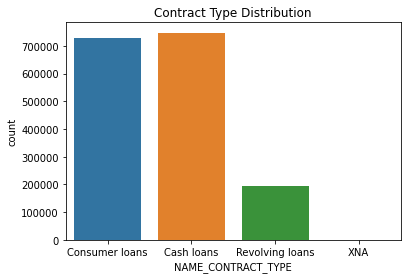

```python
ax = sns.countplot(x="NAME_CONTRACT_TYPE", data=appsDF).set(title="Contract Type Distribution")
```

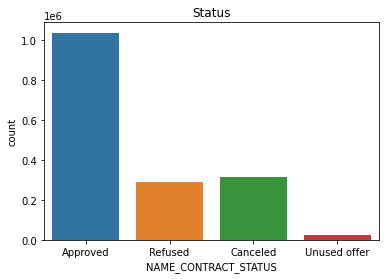

```python
ax = sns.countplot(x="NAME_CONTRACT_STATUS", data=appsDF).set(title="Status")
```

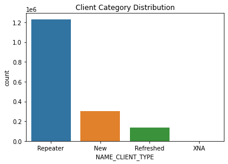

```python
ax = sns.countplot(x="NAME_CLIENT_TYPE", data=appsDF).set(title="Client Category Distribution")
```

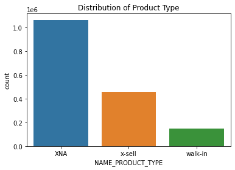

```python
ax = sns.countplot(x="NAME_PRODUCT_TYPE", data=appsDF).set(title="Distribution of Product Type")
```

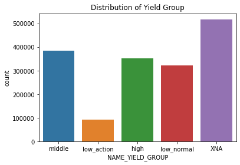

```python
ax = sns.countplot(x="NAME_YIELD_GROUP", data=appsDF).set(title="Distribution of Yield Group")
```

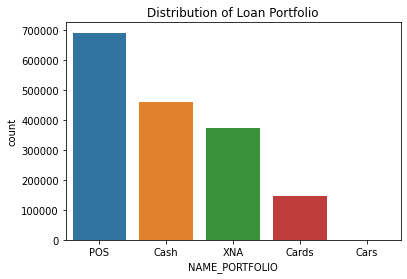

```python
ax = sns.countplot(x="NAME_PORTFOLIO", data=appsDF).set(title="Distribution of Loan Portfolio")
```

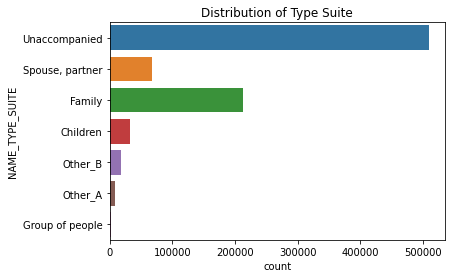

```python
ax = sns.countplot(y="NAME_TYPE_SUITE", data=appsDF).set(title="Distribution of Type Suite")
```

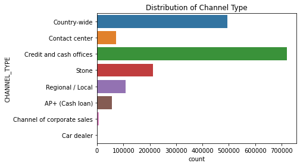

```python
ax = sns.countplot(y="CHANNEL_TYPE", data=appsDF).set(title="Distribution of Channel Type")
```

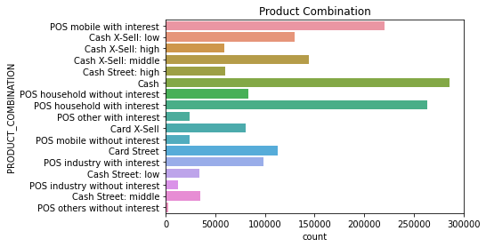

```python
ax = sns.countplot(y="PRODUCT_COMBINATION", data=appsDF).set(title="Product Combination")
```

### Numerical Data

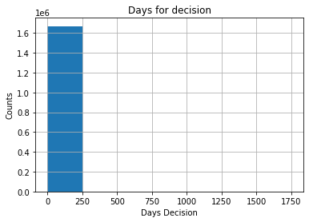

```python
bins = np.arange(0,2000,250)
ax = plt.hist(np.clip(appsDF["DAYS_DECISION"], bins[0], bins[-1]), bins=bins)
plt.xlabel('Days Decision')
plt.ylabel('Counts')
plt.title('Days for decision')
plt.grid(True)
plt.show()
```

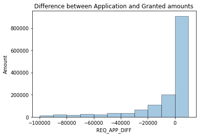

```python
appsDF["REQ_APP_DIFF"] = appsDF["AMT_APPLICATION"] - appsDF["AMT_CREDIT"]
bins = np.arange(-100000,20000,10000)
plt.ylabel('Amount')
plt.title('Difference between Application and Granted amounts')
sns.distplot(appsDF["REQ_APP_DIFF"], hist=True, kde=False,
             bins=bins,hist_kws={'edgecolor':'black'})
plt.show()
```

```python
features = ['SK_ID_CURR','SK_ID_PREV','AMT_ANNUITY', 'AMT_APPLICATION', 'AMT_CREDIT', 'AMT_DOWN_PAYMENT', 'AMT_GOODS_PRICE',
       'REQ_APP_DIFF','RATE_DOWN_PAYMENT', 'RATE_INTEREST_PRIMARY', 'RATE_INTEREST_PRIVILEGED',
       'DAYS_DECISION', 'NAME_PAYMENT_TYPE', 'CNT_PAYMENT', 'DAYS_FIRST_DRAWING',
        'DAYS_FIRST_DUE', 'DAYS_LAST_DUE_1ST_VERSION', 'DAYS_LAST_DUE', 'DAYS_TERMINATION']
```

```python
appsNum = appsDF[features]
appl = appsNum.groupby(['SK_ID_CURR']).agg(['nunique','mean', 'count', 'std', 'sum', 'min', 'max'])
appl.columns = [ '_'.join(str(i) for i in col) for col in appl.columns]
appl.reset_index(inplace=True)
```

```python
appl["APPL_RANGE"] = appl["AMT_APPLICATION_max"] - appl["AMT_APPLICATION_min"]
```

```python
appl.head()
```

|  | SK_ID_CURR | SK_ID_PREV_nunique | SK_ID_PREV_mean | SK_ID_PREV_count | SK_ID_PREV_std | SK_ID_PREV_sum | SK_ID_PREV_min | SK_ID_PREV_max | AMT_ANNUITY_nunique | AMT_ANNUITY_mean | AMT_ANNUITY_count | AMT_ANNUITY_std | AMT_ANNUITY_sum | AMT_ANNUITY_min | AMT_ANNUITY_max | AMT_APPLICATION_nunique | AMT_APPLICATION_mean | AMT_APPLICATION_count | AMT_APPLICATION_std | AMT_APPLICATION_sum | AMT_APPLICATION_min | AMT_APPLICATION_max | AMT_CREDIT_nunique | AMT_CREDIT_mean | AMT_CREDIT_count | AMT_CREDIT_std | AMT_CREDIT_sum | AMT_CREDIT_min | AMT_CREDIT_max | … |
| --- | --- | --- | --- | --- | --- | --- | --- | --- | --- | --- | --- | --- | --- | --- | --- | --- | --- | --- | --- | --- | --- | --- | --- | --- | --- | --- | --- | --- | --- | --- |
| 0 | 100001 | 1 | 1.369693e+06 | 1 | NaN | 1369693 | 1369693 | 1369693 | 1 | 3951.000000 | 1 | NaN | 3951.000000 | 3951.000000 | 3951.000000 | 1 | 24835.50 | 1 | NaN | 24835.5 | 24835.5 | 24835.5 | 1 | 23787.00 | 1 | NaN | 23787.0 | 23787.0 | 23787.0 | … |
| 1 | 100002 | 1 | 1.038818e+06 | 1 | NaN | 1038818 | 1038818 | 1038818 | 1 | 9251.775391 | 1 | NaN | 9251.775391 | 9251.775391 | 9251.775391 | 1 | 179055.00 | 1 | NaN | 179055.0 | 179055.0 | 179055.0 | 1 | 179055.00 | 1 | NaN | 179055.0 | 179055.0 | 179055.0 | … |
| 2 | 100003 | 3 | 2.281150e+06 | 3 | 424796.348991 | 6843451 | 1810518 | 2636178 | 3 | 56553.988281 | 3 | 46332.554688 | 169661.968750 | 6737.310059 | 98356.992188 | 3 | 435436.50 | 3 | 424161.625000 | 1306309.5 | 68809.5 | 900000.0 | 3 | 484191.00 | 3 | 497949.8750 | 1452573.0 | 68053.5 | 1035882.0 | … |
| 3 | 100004 | 1 | 1.564014e+06 | 1 | NaN | 1564014 | 1564014 | 1564014 | 1 | 5357.250000 | 1 | NaN | 5357.250000 | 5357.250000 | 5357.250000 | 1 | 24282.00 | 1 | NaN | 24282.0 | 24282.0 | 24282.0 | 1 | 20106.00 | 1 | NaN | 20106.0 | 20106.0 | 20106.0 | … |
| 4 | 100005 | 2 | 2.176837e+06 | 2 | 450905.023800 | 4353674 | 1857999 | 2495675 | 1 | 4813.200195 | 1 | NaN | 4813.200195 | 4813.200195 | 4813.200195 | 2 | 22308.75 | 2 | 31549.335938 | 44617.5 | 0.0 | 44617.5 | 2 | 20076.75 | 2 | 28392.8125 | 40153.5 | 0.0 | 40153.5 | … |

### Target Correlation

```python
applTrain = appl.set_index('SK_ID_CURR').join(other1.set_index('SK_ID_CURR'))
```

```python
applTrain.shape
```

```
(338857, 121)
```

```python
correlations = applTrain.corr()['TARGET'].sort_values()
print('Most Positive Correlations:\n', correlations.tail(10))
print('\nMost Negative Correlations:\n', correlations.head(10))
```

```
Most Positive Correlations:
 RATE_INTEREST_PRIVILEGED_mean     0.031139
DAYS_LAST_DUE_1ST_VERSION_mean    0.031203
RATE_INTEREST_PRIVILEGED_max      0.031420
DAYS_FIRST_DRAWING_nunique        0.041077
DAYS_LAST_DUE_1ST_VERSION_std     0.041546
DAYS_DECISION_mean                0.046864
CNT_PAYMENT_std                   0.048335
DAYS_DECISION_min                 0.053434
DAYS_FIRST_DRAWING_std            0.067594
TARGET                            1.000000
Name: TARGET, dtype: float64

Most Negative Correlations:
 DAYS_DECISION_std          -0.059792
DAYS_FIRST_DRAWING_mean    -0.048803
DAYS_FIRST_DRAWING_min     -0.044643
RATE_DOWN_PAYMENT_sum      -0.041693
DAYS_FIRST_DRAWING_sum     -0.041671
RATE_DOWN_PAYMENT_max      -0.040095
DAYS_TERMINATION_nunique   -0.035970
DAYS_LAST_DUE_nunique      -0.035396
AMT_ANNUITY_mean           -0.034871
AMT_DOWN_PAYMENT_nunique   -0.034858
Name: TARGET, dtype: float64
```

## POS_cash_balanace

### Summary

```python
POS_CASH_balance=datasets["POS_CASH_balance"]
day_convert(POS_CASH_balance)
```

|  | SK_ID_PREV | SK_ID_CURR | MONTHS_BALANCE | CNT_INSTALMENT | CNT_INSTALMENT_FUTURE | NAME_CONTRACT_STATUS | SK_DPD | SK_DPD_DEF |
| --- | --- | --- | --- | --- | --- | --- | --- | --- |
| 0 | 1803195 | 182943 | -31 | 48.0 | 45.0 | Active | 0 | 0 |
| 1 | 1715348 | 367990 | -33 | 36.0 | 35.0 | Active | 0 | 0 |
| 2 | 1784872 | 397406 | -32 | 12.0 | 9.0 | Active | 0 | 0 |
| 3 | 1903291 | 269225 | -35 | 48.0 | 42.0 | Active | 0 | 0 |
| 4 | 2341044 | 334279 | -35 | 36.0 | 35.0 | Active | 0 | 0 |
| 5 | 2207092 | 342166 | -32 | 12.0 | 12.0 | Active | 0 | 0 |
| 6 | 1110516 | 204376 | -38 | 48.0 | 43.0 | Active | 0 | 0 |
| 7 | 1387235 | 153211 | -35 | 36.0 | 36.0 | Active | 0 | 0 |
| 8 | 1220500 | 112740 | -31 | 12.0 | 12.0 | Active | 0 | 0 |
| 9 | 2371489 | 274851 | -32 | 24.0 | 16.0 | Active | 0 | 0 |
| 10 | 2328294 | 287361 | -32 | 12.0 | 12.0 | Active | 0 | 0 |
| 11 | 2023570 | 237959 | -39 | 12.0 | 12.0 | Active | 0 | 0 |
| 12 | 1258390 | 278261 | -32 | 36.0 | 36.0 | Active | 0 | 0 |
| 13 | 1627166 | 146161 | -33 | 24.0 | 24.0 | Active | 0 | 0 |
| 14 | 1711625 | 131467 | -34 | 12.0 | 5.0 | Active | 0 | 0 |
| 15 | 2374177 | 204722 | -35 | 24.0 | 15.0 | Active | 0 | 0 |
| 16 | 1716688 | 405549 | -33 | 12.0 | 1.0 | Active | 0 | 0 |
| 17 | 1846127 | 380050 | -31 | 36.0 | 28.0 | Active | 0 | 0 |
| 18 | 1911764 | 312551 | -32 | 24.0 | 16.0 | Active | 0 | 0 |
| 19 | 2645133 | 152810 | -35 | 24.0 | 23.0 | Active | 0 | 0 |
| 20 | 1381005 | 195362 | -34 | 60.0 | 56.0 | Active | 0 | 0 |
| 21 | 1366811 | 169489 | -38 | 24.0 | 24.0 | Active | 0 | 0 |
| 22 | 1260621 | 244684 | -32 | 18.0 | 12.0 | Active | 0 | 0 |
| 23 | 1445556 | 220181 | -41 | 12.0 | 12.0 | Active | 0 | 0 |
| 24 | 1420240 | 386836 | -41 | 12.0 | 11.0 | Active | 0 | 0 |
| 25 | 2631694 | 337149 | -33 | 12.0 | 11.0 | Active | 0 | 0 |
| 26 | 1059679 | 139637 | -31 | 12.0 | 12.0 | Active | 0 | 0 |
| 27 | 1865970 | 202091 | -35 | 12.0 | 7.0 | Active | 0 | 0 |
| 28 | 2683316 | 454237 | -32 | 18.0 | 15.0 | Active | 0 | 0 |
| 29 | 2759941 | 428330 | -32 | 18.0 | 18.0 | Active | 0 | 0 |
| ... | ... | ... | ... | ... | ... | ... | ... | ... |
| 10001328 | 2256531 | 422685 | -20 | 6.0 | 0.0 | Active | 0 | 0 |
| 10001329 | 1540335 | 104779 | -27 | 6.0 | 0.0 | Active | 0 | 0 |
| 10001330 | 1717234 | 141565 | -18 | 12.0 | 0.0 | Active | 630 | 0 |
| 10001331 | 2476257 | 210494 | -18 | 6.0 | 0.0 | Active | 0 | 0 |
| 10001332 | 2700641 | 448867 | -18 | 6.0 | 0.0 | Active | 871 | 0 |
| 10001333 | 2715817 | 417692 | -18 | 6.0 | 0.0 | Active | 948 | 0 |
| 10001334 | 2149359 | 305835 | -19 | 12.0 | 0.0 | Active | 903 | 0 |
| 10001335 | 1074985 | 433445 | -22 | 12.0 | 0.0 | Active | 0 | 0 |
| 10001336 | 1214793 | 292180 | -21 | 12.0 | 0.0 | Active | 850 | 0 |
| 10001337 | 2305826 | 356195 | -18 | 12.0 | 0.0 | Active | 804 | 0 |
| 10001338 | 1013514 | 305218 | -27 | 16.0 | 0.0 | Signed | 0 | 0 |
| 10001339 | 1609165 | 370184 | -21 | 15.0 | 0.0 | Signed | 0 | 0 |
| 10001340 | 1413755 | 233660 | -19 | 24.0 | 0.0 | Signed | 0 | 0 |
| 10001341 | 2275842 | 293579 | -20 | 6.0 | 0.0 | Signed | 0 | 0 |
| 10001342 | 1641388 | 165586 | -19 | 10.0 | 0.0 | Active | 1063 | 0 |
| 10001343 | 1816071 | 383432 | -23 | 6.0 | 0.0 | Signed | 0 | 0 |
| 10001344 | 1086035 | 102784 | -26 | 24.0 | 0.0 | Active | 654 | 0 |
| 10001345 | 1773550 | 412155 | -18 | 6.0 | 0.0 | Signed | 0 | 0 |
| 10001346 | 2210119 | 381218 | -22 | 12.0 | 0.0 | Active | 1016 | 0 |
| 10001347 | 1522999 | 385297 | -21 | 12.0 | 0.0 | Active | 0 | 0 |
| 10001348 | 2234984 | 191559 | -22 | 6.0 | 0.0 | Active | 797 | 0 |
| 10001349 | 2340692 | 104125 | -24 | 6.0 | 0.0 | Active | 944 | 0 |
| 10001350 | 2593362 | 198894 | -20 | 12.0 | 0.0 | Completed | 0 | 0 |
| 10001351 | 2639809 | 288279 | -25 | 6.0 | 0.0 | Active | 925 | 0 |
| 10001352 | 2700641 | 448867 | -19 | 6.0 | 0.0 | Active | 843 | 0 |
| 10001353 | 2448283 | 226558 | -20 | 6.0 | 0.0 | Active | 843 | 0 |
| 10001354 | 1717234 | 141565 | -19 | 12.0 | 0.0 | Active | 602 | 0 |
| 10001355 | 1283126 | 315695 | -21 | 10.0 | 0.0 | Active | 609 | 0 |
| 10001356 | 1082516 | 450255 | -22 | 12.0 | 0.0 | Active | 614 | 0 |
| 10001357 | 1259607 | 174278 | -52 | 16.0 | 0.0 | Completed | 0 | 0 |

10001358 rows × 8 columns

```python
POS_CASH_balance.info()
```

```
<class 'pandas.core.frame.DataFrame'>
RangeIndex: 10001358 entries, 0 to 10001357
Data columns (total 8 columns):
SK_ID_PREV               int32
SK_ID_CURR               int32
MONTHS_BALANCE           int8
CNT_INSTALMENT           float16
CNT_INSTALMENT_FUTURE    float16
NAME_CONTRACT_STATUS     object
SK_DPD                   int16
SK_DPD_DEF               int16
dtypes: float16(2), int16(2), int32(2), int8(1), object(1)
memory usage: 238.5+ MB
```

```python
#removing all rows where CNT_INSTALMENT_FUTURE = 0
zeros = POS_CASH_balance[ POS_CASH_balance['CNT_INSTALMENT_FUTURE'] == 0.0 ].index
POS_CASH_balance.drop(zeros , inplace=True)
```

```python
POS_CASH_balance.describe(include='all') # numerical and categorical features
```

|  | SK_ID_PREV | SK_ID_CURR | MONTHS_BALANCE | CNT_INSTALMENT | CNT_INSTALMENT_FUTURE | NAME_CONTRACT_STATUS | SK_DPD | SK_DPD_DEF |
| --- | --- | --- | --- | --- | --- | --- | --- | --- |
| count | 8.815398e+06 | 8.815398e+06 | 8.815398e+06 | 8789327.0 | 8789311.0 | 8815398 | 8.815398e+06 | 8.815398e+06 |
| unique | NaN | NaN | NaN | NaN | NaN | 8 | NaN | NaN |
| top | NaN | NaN | NaN | NaN | NaN | Active | NaN | NaN |
| freq | NaN | NaN | NaN | NaN | NaN | 8718618 | NaN | NaN |
| mean | 1.903373e+06 | 2.783789e+05 | -3.436210e+01 | NaN | NaN | NaN | 1.443824e-01 | 6.908695e-02 |
| std | 5.357622e+05 | 1.027664e+05 | 2.568452e+01 | 0.0 | 0.0 | NaN | 1.626021e+00 | 1.064389e+00 |
| min | 1.000001e+06 | 1.000010e+05 | -9.600000e+01 | 1.0 | 1.0 | NaN | 0.000000e+00 | 0.000000e+00 |
| 25% | 1.434580e+06 | 1.894960e+05 | -5.300000e+01 | 10.0 | 4.0 | NaN | 0.000000e+00 | 0.000000e+00 |
| 50% | 1.896792e+06 | 2.786570e+05 | -2.700000e+01 | 12.0 | 8.0 | NaN | 0.000000e+00 | 0.000000e+00 |
| 75% | 2.368951e+06 | 3.674028e+05 | -1.300000e+01 | 24.0 | 16.0 | NaN | 0.000000e+00 | 0.000000e+00 |
| max | 2.843499e+06 | 4.562550e+05 | -1.000000e+00 | 92.0 | 85.0 | NaN | 3.650000e+02 | 2.800000e+02 |

```python
POS_CASH_balance.isna().sum()
```

```
SK_ID_PREV                   0
SK_ID_CURR                   0
MONTHS_BALANCE               0
CNT_INSTALMENT           26071
CNT_INSTALMENT_FUTURE    26087
NAME_CONTRACT_STATUS         0
SK_DPD                       0
SK_DPD_DEF                   0
dtype: int64
```

```python
# unique catagorical variable values:
print('NAME_CONTRACT_STATUS'," ",POS_CASH_balance['NAME_CONTRACT_STATUS'].unique())
```

```
NAME_CONTRACT_STATUS   ['Active' 'Signed' 'Approved' 'Returned to the store' 'Canceled' 'Demand'
 'XNA' 'Completed']
```

```python
POS_CASH_balance.NAME_CONTRACT_STATUS.value_counts()
```

```
Active                   8718618
Signed                     86420
Returned to the store       5461
Approved                    4862
Demand                        16
Canceled                      15
Completed                      4
XNA                            2
Name: NAME_CONTRACT_STATUS, dtype: int64
```

```python
apps = datasets["application_train"]
apps1= apps[['SK_ID_CURR', 'TARGET']]
posapps = POS_CASH_balance.set_index('SK_ID_CURR').join(apps1.set_index('SK_ID_CURR'))
```

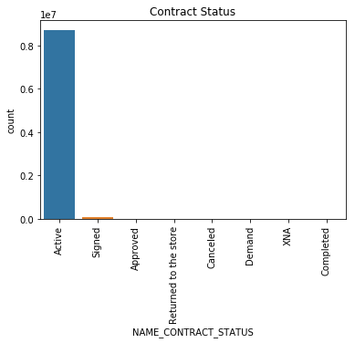

```python
sns.countplot(x='NAME_CONTRACT_STATUS', data=POS_CASH_balance);
plt.title('Contract Status');
plt.xticks(rotation=90);
```

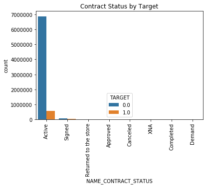

```python
sns.countplot(x='NAME_CONTRACT_STATUS',hue='TARGET', data=posapps);
plt.title('Contract Status by Target');
plt.xticks(rotation=90);
```

```python
POS_CASH_balance['INSTALLMENTS_MADE'] = POS_CASH_balance.CNT_INSTALMENT - POS_CASH_balance.CNT_INSTALMENT_FUTURE
```

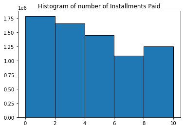

```python
bins= [0,2,4,6,8,10]
plt.hist(POS_CASH_balance.INSTALLMENTS_MADE, bins=bins, edgecolor="k")
plt.xticks(bins)
plt.title('Histogram of number of Installments Paid')
plt.show()
```

```python
POS_CASH_balance['INSTALLMENT_TIME']=["On-time" if x <= 0 else "Late" for x in POS_CASH_balance.SK_DPD]
```

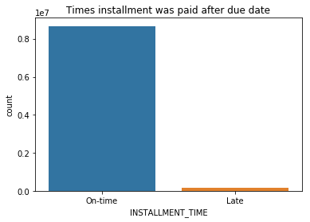

```python
sns.countplot(x="INSTALLMENT_TIME", data=POS_CASH_balance)
plt.title("Times installment was paid after due date")
```

```python
posapps['INSTALLMENT_TIME']=["On-time" if x <= 0 else "Late" for x in POS_CASH_balance.SK_DPD]
```

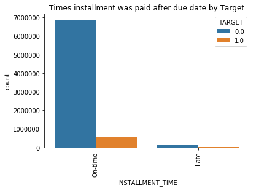

```python
sns.countplot(x="INSTALLMENT_TIME",hue='TARGET', data=posapps);
plt.title('Times installment was paid after due date by Target');
plt.xticks(rotation=90);
```

```python
cash_bal = POS_CASH_balance.groupby(['SK_ID_CURR']).agg(['mean', 'count', 'std', 'sum', 'min', 'max'])
cash_bal.columns = [ '_'.join(str(i) for i in col) for col in cash_bal.columns]
cash_bal.reset_index(inplace=True)
cash_bal
```

|  | SK_ID_CURR | SK_ID_PREV_mean | SK_ID_PREV_count | SK_ID_PREV_std | SK_ID_PREV_sum | SK_ID_PREV_min | SK_ID_PREV_max | MONTHS_BALANCE_mean | MONTHS_BALANCE_count | MONTHS_BALANCE_std | MONTHS_BALANCE_sum | MONTHS_BALANCE_min | MONTHS_BALANCE_max | CNT_INSTALMENT_mean | CNT_INSTALMENT_count | CNT_INSTALMENT_std | CNT_INSTALMENT_sum | CNT_INSTALMENT_min | CNT_INSTALMENT_max | CNT_INSTALMENT_FUTURE_mean | CNT_INSTALMENT_FUTURE_count | CNT_INSTALMENT_FUTURE_std | CNT_INSTALMENT_FUTURE_sum | CNT_INSTALMENT_FUTURE_min | CNT_INSTALMENT_FUTURE_max | SK_DPD_mean | SK_DPD_count | SK_DPD_std | SK_DPD_sum | … |
| --- | --- | --- | --- | --- | --- | --- | --- | --- | --- | --- | --- | --- | --- | --- | --- | --- | --- | --- | --- | --- | --- | --- | --- | --- | --- | --- | --- | --- | --- | --- |
| 0 | 100001 | 1.530457e+06 | 6 | 249054.001470 | 9182740 | 1369693 | 1851984 | -68.833333 | 6 | 20.682521 | -413.0 | -96 | -54 | 4.000000 | 6 | 0.000000 | 24.0 | 4.0 | 4.0 | 2.166016 | 6 | 1.168945 | 13.0 | 1.0 | 4.0 | 1.166667 | 6 | 2.857738 | 7 | … |
| 1 | 100002 | 1.038818e+06 | 19 | 0.000000 | 19737542 | 1038818 | 1038818 | -10.000000 | 19 | 5.627314 | -190.0 | -19 | -1 | 24.000000 | 19 | 0.000000 | 456.0 | 24.0 | 24.0 | 15.000000 | 19 | 5.628906 | 285.0 | 6.0 | 24.0 | 0.000000 | 19 | 0.000000 | 0 | … |
| 2 | 100003 | 2.290070e+06 | 25 | 320488.923470 | 57251754 | 1810518 | 2636178 | -46.600000 | 25 | 24.610296 | -1165.0 | -77 | -19 | 10.562500 | 25 | 2.615234 | 264.0 | 6.0 | 12.0 | 6.480469 | 25 | 3.453125 | 162.0 | 1.0 | 12.0 | 0.000000 | 25 | 0.000000 | 0 | … |
| 3 | 100004 | 1.564014e+06 | 3 | 0.000000 | 4692042 | 1564014 | 1564014 | -26.000000 | 3 | 1.000000 | -78.0 | -27 | -25 | 4.000000 | 3 | 0.000000 | 12.0 | 4.0 | 4.0 | 3.000000 | 3 | 1.000000 | 9.0 | 2.0 | 4.0 | 0.000000 | 3 | 0.000000 | 0 | … |
| 4 | 100005 | 2.495675e+06 | 10 | 0.000000 | 24956750 | 2495675 | 2495675 | -20.500000 | 10 | 3.027650 | -205.0 | -25 | -16 | 12.000000 | 9 | 0.000000 | 108.0 | 12.0 | 12.0 | 8.000000 | 9 | 2.738281 | 72.0 | 4.0 | 12.0 | 0.000000 | 10 | 0.000000 | 0 | … |
| ... | ... | ... | ... | ... | ... | ... | ... | ... | ... | ... | ... | ... | ... | ... | ... | ... | ... | ... | ... | ... | ... | ... | ... | ... | ... | ... | ... | ... | ... | … |
| 336604 | 456251 | 2.248017e+06 | 8 | 0.000000 | 17984136 | 2248017 | 2248017 | -5.500000 | 8 | 2.449490 | -44.0 | -9 | -2 | 8.000000 | 7 | 0.000000 | 56.0 | 8.0 | 8.0 | 5.000000 | 7 | 2.160156 | 35.0 | 2.0 | 8.0 | 0.000000 | 8 | 0.000000 | 0 | … |
| 336605 | 456252 | 1.503599e+06 | 6 | 0.000000 | 9021594 | 1503599 | 1503599 | -79.500000 | 6 | 1.870829 | -477.0 | -82 | -77 | 6.000000 | 6 | 0.000000 | 36.0 | 6.0 | 6.0 | 3.500000 | 6 | 1.871094 | 21.0 | 1.0 | 6.0 | 0.000000 | 6 | 0.000000 | 0 | … |
| 336606 | 456253 | 1.737400e+06 | 12 | 136607.906630 | 20848796 | 1668235 | 2029307 | -77.000000 | 12 | 17.325756 | -924.0 | -96 | -58 | 6.332031 | 12 | 2.806641 | 76.0 | 4.0 | 12.0 | 2.833984 | 12 | 1.642578 | 34.0 | 1.0 | 6.0 | 0.416667 | 12 | 1.443376 | 5 | … |
| 336607 | 456254 | 1.893484e+06 | 20 | 114076.843814 | 37869673 | 1792910 | 2016407 | -5.550000 | 20 | 3.034451 | -111.0 | -11 | -1 | 14.898438 | 20 | 1.020508 | 298.0 | 14.0 | 16.0 | 10.351562 | 20 | 3.359375 | 207.0 | 4.0 | 16.0 | 0.000000 | 20 | 0.000000 | 0 | … |
| 336608 | 456255 | 1.936755e+06 | 63 | 636335.682026 | 122015584 | 1179690 | 2729207 | -16.888889 | 63 | 7.403380 | -1064.0 | -33 | -3 | 24.578125 | 63 | 10.375000 | 1548.0 | 6.0 | 36.0 | 17.062500 | 63 | 8.820312 | 1075.0 | 3.0 | 36.0 | 0.079365 | 63 | 0.629941 | 5 | … |

336609 rows × 43 columns

### Target Corelation

```python
cash_balTrain = POS_CASH_balance.set_index('SK_ID_CURR').join(other1.set_index('SK_ID_CURR'))
correlations = cash_balTrain.corr()['TARGET'].sort_values()
print('Most Positive Correlations:\n', correlations.tail(10))
print('\nMost Negative Correlations:\n', correlations.head(10))
```

```
Most Positive Correlations:
 INSTALLMENTS_MADE       -0.004985
SK_ID_PREV              -0.000371
SK_DPD                   0.014750
SK_DPD_DEF               0.017795
MONTHS_BALANCE           0.019468
CNT_INSTALMENT           0.021332
CNT_INSTALMENT_FUTURE    0.026114
TARGET                   1.000000
Name: TARGET, dtype: float64

Most Negative Correlations:
 INSTALLMENTS_MADE       -0.004985
SK_ID_PREV              -0.000371
SK_DPD                   0.014750
SK_DPD_DEF               0.017795
MONTHS_BALANCE           0.019468
CNT_INSTALMENT           0.021332
CNT_INSTALMENT_FUTURE    0.026114
TARGET                   1.000000
Name: TARGET, dtype: float64
```

## credit_card_balance

### Summary

```python
credit_bal = datasets["credit_card_balance"]
day_convert(credit_bal)
```

|  | SK_ID_PREV | SK_ID_CURR | MONTHS_BALANCE | AMT_BALANCE | AMT_CREDIT_LIMIT_ACTUAL | AMT_DRAWINGS_ATM_CURRENT | AMT_DRAWINGS_CURRENT | AMT_DRAWINGS_OTHER_CURRENT | AMT_DRAWINGS_POS_CURRENT | AMT_INST_MIN_REGULARITY | AMT_PAYMENT_CURRENT | AMT_PAYMENT_TOTAL_CURRENT | AMT_RECEIVABLE_PRINCIPAL | AMT_RECIVABLE | AMT_TOTAL_RECEIVABLE | CNT_DRAWINGS_ATM_CURRENT | CNT_DRAWINGS_CURRENT | CNT_DRAWINGS_OTHER_CURRENT | CNT_DRAWINGS_POS_CURRENT | CNT_INSTALMENT_MATURE_CUM | NAME_CONTRACT_STATUS | SK_DPD | SK_DPD_DEF |
| --- | --- | --- | --- | --- | --- | --- | --- | --- | --- | --- | --- | --- | --- | --- | --- | --- | --- | --- | --- | --- | --- | --- | --- |
| 0 | 2562384 | 378907 | -6 | 56.970001 | 135000 | 0.0 | 877.500000 | 0.0 | 877.500000 | 1700.324951 | 1800.000000 | 1800.000000 | 0.000000 | 0.000000 | 0.000000 | 0.0 | 1 | 0.0 | 1.0 | 35.0 | Active | 0 | 0 |
| 1 | 2582071 | 363914 | -1 | 63975.554688 | 45000 | 2250.0 | 2250.000000 | 0.0 | 0.000000 | 2250.000000 | 2250.000000 | 2250.000000 | 60175.078125 | 64875.554688 | 64875.554688 | 1.0 | 1 | 0.0 | 0.0 | 69.0 | Active | 0 | 0 |
| 2 | 1740877 | 371185 | -7 | 31815.224609 | 450000 | 0.0 | 0.000000 | 0.0 | 0.000000 | 2250.000000 | 2250.000000 | 2250.000000 | 26926.425781 | 31460.085938 | 31460.085938 | 0.0 | 0 | 0.0 | 0.0 | 30.0 | Active | 0 | 0 |
| 3 | 1389973 | 337855 | -4 | 236572.109375 | 225000 | 2250.0 | 2250.000000 | 0.0 | 0.000000 | 11795.759766 | 11925.000000 | 11925.000000 | 224949.281250 | 233048.968750 | 233048.968750 | 1.0 | 1 | 0.0 | 0.0 | 10.0 | Active | 0 | 0 |
| 4 | 1891521 | 126868 | -1 | 453919.468750 | 450000 | 0.0 | 11547.000000 | 0.0 | 11547.000000 | 22924.890625 | 27000.000000 | 27000.000000 | 443044.406250 | 453919.468750 | 453919.468750 | 0.0 | 1 | 0.0 | 1.0 | 101.0 | Active | 0 | 0 |
| 5 | 2646502 | 380010 | -7 | 82903.812500 | 270000 | 0.0 | 0.000000 | 0.0 | 0.000000 | 4449.104980 | 3825.000000 | 3825.000000 | 80519.039062 | 82773.312500 | 82773.312500 | 0.0 | 0 | 0.0 | 0.0 | 2.0 | Active | 7 | 0 |
| 6 | 1079071 | 171320 | -6 | 353451.656250 | 585000 | 67500.0 | 67500.000000 | 0.0 | 0.000000 | 14684.174805 | 15750.000000 | 15750.000000 | 345433.875000 | 351881.156250 | 351881.156250 | 1.0 | 1 | 0.0 | 0.0 | 6.0 | Active | 0 | 0 |
| 7 | 2095912 | 118650 | -7 | 47962.125000 | 45000 | 45000.0 | 45000.000000 | 0.0 | 0.000000 | 0.000000 | 264.690002 | 0.000000 | 44735.308594 | 47962.125000 | 47962.125000 | 1.0 | 1 | 0.0 | 0.0 | 51.0 | Active | 0 | 0 |
| 8 | 2181852 | 367360 | -4 | 291543.062500 | 292500 | 90000.0 | 289339.437500 | 0.0 | 199339.421875 | 130.500000 | 4093.514893 | 4093.514893 | 285376.406250 | 286831.562500 | 286831.562500 | 3.0 | 8 | 0.0 | 5.0 | 3.0 | Active | 0 | 0 |
| 9 | 1235299 | 203885 | -5 | 201261.187500 | 225000 | 76500.0 | 111026.703125 | 0.0 | 34526.699219 | 6338.339844 | 45000.000000 | 45000.000000 | 192793.281250 | 197224.687500 | 197224.687500 | 3.0 | 9 | 0.0 | 6.0 | 38.0 | Active | 0 | 0 |
| 10 | 1108284 | 209660 | -7 | 102076.562500 | 180000 | 92250.0 | 92250.000000 | 0.0 | 0.000000 | 0.000000 | 4500.000000 | 4500.000000 | 92237.351562 | 94224.062500 | 94224.062500 | 5.0 | 5 | 0.0 | 0.0 | 0.0 | Active | 0 | 0 |
| 11 | 2740914 | 340339 | -1 | 131669.140625 | 225000 | 10800.0 | 10800.000000 | 0.0 | 0.000000 | 6000.479980 | 6322.500000 | 6322.500000 | 121430.703125 | 127891.937500 | 127891.937500 | 2.0 | 2 | 0.0 | 0.0 | 6.0 | Active | 0 | 0 |
| 12 | 1985699 | 302517 | -4 | 1427.265015 | 135000 | 4500.0 | 101304.718750 | 0.0 | 96804.718750 | 3023.955078 | 85500.000000 | 85500.000000 | 0.000000 | 0.000000 | 0.000000 | 1.0 | 30 | 0.0 | 29.0 | 27.0 | Active | 0 | 0 |
| 13 | 1441883 | 171537 | -5 | 0.000000 | 270000 | 0.0 | 0.000000 | 0.0 | 0.000000 | 12218.490234 | 2607.794922 | 1448.640015 | 0.000000 | 0.000000 | 0.000000 | 0.0 | 0 | 0.0 | 0.0 | 2.0 | Active | 0 | 0 |
| 14 | 1864742 | 303581 | -1 | 0.000000 | 45000 | 0.0 | 0.000000 | 0.0 | 0.000000 | 0.000000 | 2.295000 | 0.000000 | 0.000000 | 0.000000 | 0.000000 | 0.0 | 0 | 0.0 | 0.0 | 59.0 | Active | 0 | 0 |
| 15 | 2037377 | 289902 | -1 | 131294.343750 | 135000 | 0.0 | 0.000000 | 0.0 | 0.000000 | 6774.660156 | 6975.000000 | 6975.000000 | 128518.023438 | 131294.343750 | 131294.343750 | 0.0 | 0 | 0.0 | 0.0 | 11.0 | Active | 0 | 0 |
| 16 | 1816636 | 255981 | -6 | 72899.953125 | 450000 | 67500.0 | 67500.000000 | 0.0 | 0.000000 | 2457.719971 | 25200.000000 | 25200.000000 | 68954.804688 | 71554.453125 | 71554.453125 | 1.0 | 1 | 0.0 | 0.0 | 42.0 | Active | 0 | 0 |
| 17 | 1039039 | 276642 | -6 | 0.000000 | 67500 | 0.0 | 0.000000 | 0.0 | 0.000000 | 0.000000 | 0.000000 | 0.000000 | 0.000000 | 0.000000 | 0.000000 | 0.0 | 0 | 0.0 | 0.0 | 33.0 | Completed | 0 | 0 |
| 18 | 2016842 | 302450 | -3 | 0.000000 | 0 | 0.0 | 0.000000 | 0.0 | 0.000000 | 0.000000 | 0.000000 | 0.000000 | 0.000000 | 0.000000 | 0.000000 | 0.0 | 0 | 0.0 | 0.0 | 2.0 | Completed | 0 | 0 |
| 19 | 1189095 | 231608 | -4 | 452774.687500 | 450000 | 9000.0 | 9000.000000 | 0.0 | 0.000000 | 22916.474609 | 27000.000000 | 27000.000000 | 440329.062500 | 451429.187500 | 451429.187500 | 1.0 | 1 | 0.0 | 0.0 | 22.0 | Active | 0 | 0 |
| 20 | 1104090 | 259807 | -6 | 45413.730469 | 45000 | 105750.0 | 105750.000000 | 0.0 | 0.000000 | 1471.005005 | 86887.976562 | 84637.976562 | 43650.855469 | 44068.230469 | 44068.230469 | 3.0 | 3 | 0.0 | 0.0 | 16.0 | Active | 0 | 0 |
| 21 | 1683604 | 217113 | -1 | 68710.140625 | 67500 | 0.0 | 4412.250000 | 0.0 | 4412.250000 | 3315.239990 | 3375.000000 | 3375.000000 | 67341.867188 | 68710.140625 | 68710.140625 | 0.0 | 4 | 0.0 | 4.0 | 6.0 | Active | 0 | 0 |
| 22 | 2392920 | 132481 | -1 | 85792.093750 | 135000 | 45000.0 | 63337.816406 | 0.0 | 18337.814453 | 2250.000000 | 23181.570312 | 18521.550781 | 85086.945312 | 85792.093750 | 85792.093750 | 1.0 | 9 | 0.0 | 8.0 | 5.0 | Active | 0 | 0 |
| 23 | 2021411 | 105755 | -5 | 464452.468750 | 450000 | 135000.0 | 279112.500000 | 137700.0 | 6412.500000 | 8921.969727 | 9000.000000 | 9000.000000 | 448552.125000 | 456379.468750 | 456379.468750 | 5.0 | 7 | 1.0 | 1.0 | 25.0 | Active | 0 | 0 |
| 24 | 1927949 | 323730 | -3 | 152801.546875 | 157500 | 0.0 | 0.000000 | 0.0 | 0.000000 | 7875.000000 | 7875.000000 | 7875.000000 | 146858.000000 | 152801.546875 | 152801.546875 | 0.0 | 0 | 0.0 | 0.0 | 70.0 | Active | 0 | 0 |
| 25 | 1885349 | 195164 | -6 | 134249.437500 | 157500 | 0.0 | 0.000000 | 0.0 | 0.000000 | 6906.555176 | 7200.000000 | 7200.000000 | 130930.968750 | 134249.437500 | 134249.437500 | 0.0 | 0 | 0.0 | 0.0 | 35.0 | Active | 0 | 0 |
| 26 | 2024137 | 184131 | -3 | 67609.125000 | 450000 | 42750.0 | 76131.000000 | 0.0 | 33381.000000 | 2250.000000 | 13500.000000 | 13500.000000 | 65466.539062 | 66263.625000 | 66263.625000 | 1.0 | 2 | 0.0 | 1.0 | 33.0 | Active | 0 | 0 |
| 27 | 2272688 | 387286 | -6 | 76235.937500 | 180000 | 31500.0 | 32985.000000 | 0.0 | 1485.000000 | 2250.000000 | 18919.035156 | 14175.855469 | 75963.781250 | 76235.937500 | 76235.937500 | 2.0 | 4 | 0.0 | 2.0 | 1.0 | Active | 0 | 0 |
| 28 | 2561523 | 213409 | -2 | 137812.187500 | 180000 | 0.0 | 3100.500000 | 0.0 | 3100.500000 | 7041.645020 | 9000.000000 | 9000.000000 | 134933.171875 | 137812.187500 | 137812.187500 | 0.0 | 1 | 0.0 | 1.0 | 5.0 | Active | 0 | 0 |
| 29 | 1288249 | 406607 | -4 | 0.000000 | 270000 | 0.0 | 0.000000 | 0.0 | 0.000000 | 0.000000 | 2394.179932 | 0.000000 | 0.000000 | 0.000000 | 0.000000 | 0.0 | 0 | 0.0 | 0.0 | 80.0 | Active | 0 | 0 |
| ... | ... | ... | ... | ... | ... | ... | ... | ... | ... | ... | ... | ... | ... | ... | ... | ... | ... | ... | ... | ... | ... | ... | ... |
| 1048545 | 2184721 | 273203 | -2 | 177485.984375 | 180000 | 0.0 | 0.000000 | 0.0 | 0.000000 | 9142.605469 | 9225.000000 | 9225.000000 | 173627.093750 | 177485.984375 | 177485.984375 | 0.0 | 0 | 0.0 | 0.0 | 13.0 | Active | 0 | 0 |
| 1048546 | 1876762 | 102408 | -3 | 85915.484375 | 180000 | 0.0 | 0.000000 | 0.0 | 0.000000 | 4794.569824 | 4950.000000 | 208.125000 | 82665.812500 | 85694.984375 | 85694.984375 | 0.0 | 0 | 0.0 | 0.0 | 4.0 | Active | 0 | 0 |
| 1048547 | 2442600 | 427967 | -4 | 172381.765625 | 180000 | 40500.0 | 40500.000000 | 0.0 | 0.000000 | 6688.080078 | 6750.000000 | 6750.000000 | 167511.187500 | 171036.265625 | 171036.265625 | 1.0 | 1 | 0.0 | 0.0 | 13.0 | Active | 0 | 0 |
| 1048548 | 1100630 | 288918 | -2 | 137726.500000 | 225000 | 18000.0 | 18000.000000 | 0.0 | 0.000000 | 5983.649902 | 6750.000000 | 6750.000000 | 130923.132812 | 134590.000000 | 134590.000000 | 2.0 | 2 | 0.0 | 0.0 | 12.0 | Active | 0 | 0 |
| 1048549 | 1916260 | 452269 | -1 | 166734.812500 | 247500 | 0.0 | 35772.660156 | 0.0 | 35772.660156 | 7346.609863 | 8441.594727 | 8441.594727 | 162644.125000 | 166734.812500 | 166734.812500 | 0.0 | 18 | 0.0 | 18.0 | 13.0 | Active | 0 | 0 |
| 1048550 | 1465185 | 194909 | -4 | 301982.187500 | 315000 | 0.0 | 0.000000 | 0.0 | 0.000000 | 16362.179688 | 16650.000000 | 16650.000000 | 293943.687500 | 301982.187500 | 301982.187500 | 0.0 | 0 | 0.0 | 0.0 | 13.0 | Active | 0 | 0 |
| 1048551 | 2659515 | 270161 | -3 | 36814.859375 | 45000 | 0.0 | 0.000000 | 0.0 | 0.000000 | 2250.000000 | 2250.000000 | 0.000000 | 36270.945312 | 36814.859375 | 36814.859375 | 0.0 | 0 | 0.0 | 0.0 | 12.0 | Active | 0 | 0 |
| 1048552 | 2363265 | 437501 | -3 | 149307.750000 | 180000 | 144000.0 | 144000.000000 | 0.0 | 0.000000 | 30770.865234 | 619425.000000 | 619425.000000 | 139992.296875 | 146616.750000 | 146616.750000 | 2.0 | 2 | 0.0 | 0.0 | 13.0 | Active | 0 | 0 |
| 1048553 | 1295718 | 272910 | -3 | 158452.968750 | 180000 | 45000.0 | 51988.320312 | 0.0 | 6988.319824 | 5715.584961 | 5850.000000 | 5850.000000 | 154600.375000 | 157107.468750 | 157107.468750 | 1.0 | 2 | 0.0 | 1.0 | 13.0 | Active | 0 | 0 |
| 1048554 | 1716550 | 336711 | -6 | 3134.475098 | 198000 | 0.0 | 156551.046875 | 0.0 | 156551.046875 | 7320.015137 | 150450.890625 | 150450.890625 | 0.000000 | 0.000000 | 0.000000 | 0.0 | 22 | 0.0 | 22.0 | 13.0 | Active | 0 | 0 |
| 1048555 | 2103498 | 327776 | -4 | 199416.328125 | 216000 | 0.0 | 0.000000 | 0.0 | 0.000000 | 11859.705078 | 22500.000000 | 22500.000000 | 192194.453125 | 199416.328125 | 199416.328125 | 0.0 | 0 | 0.0 | 0.0 | 13.0 | Active | 0 | 0 |
| 1048556 | 2673584 | 304080 | -4 | 196673.265625 | 211500 | 22500.0 | 22500.000000 | 0.0 | 0.000000 | 9340.379883 | 9450.000000 | 9450.000000 | 187021.265625 | 194751.765625 | 194751.765625 | 1.0 | 1 | 0.0 | 0.0 | 7.0 | Active | 0 | 0 |
| 1048557 | 1316091 | 297038 | -5 | 75659.625000 | 81000 | 0.0 | 75661.875000 | 0.0 | 75661.875000 | 2184.300049 | 2186.550049 | 2186.550049 | 75659.625000 | 75659.625000 | 75659.625000 | 0.0 | 2 | 0.0 | 2.0 | 10.0 | Active | 0 | 0 |
| 1048558 | 2023473 | 226784 | -4 | 270332.812500 | 337500 | 0.0 | 0.000000 | 0.0 | 0.000000 | 13624.424805 | 13950.000000 | 13950.000000 | 258538.546875 | 267896.562500 | 267896.562500 | 0.0 | 0 | 0.0 | 0.0 | 10.0 | Active | 0 | 0 |
| 1048559 | 1743422 | 381748 | -6 | 0.000000 | 9000 | 18000.0 | 18000.000000 | 0.0 | 0.000000 | 2250.000000 | 22541.130859 | 21581.099609 | 0.000000 | 0.000000 | 0.000000 | 2.0 | 2 | 0.0 | 0.0 | 13.0 | Active | 0 | 0 |
| 1048560 | 1395110 | 375975 | -2 | 300871.562500 | 765000 | 0.0 | 11738.384766 | 0.0 | 11738.384766 | 12757.995117 | 36000.000000 | 19094.939453 | 297605.375000 | 300871.562500 | 300871.562500 | 0.0 | 4 | 0.0 | 4.0 | 11.0 | Active | 0 | 0 |
| 1048561 | 1985118 | 299254 | -1 | 397666.656250 | 450000 | 0.0 | 0.000000 | 0.0 | 0.000000 | 20251.304688 | 20272.500000 | 20272.500000 | 384753.687500 | 397666.656250 | 397666.656250 | 0.0 | 0 | 0.0 | 0.0 | 13.0 | Active | 0 | 0 |
| 1048562 | 2429257 | 248677 | -6 | 94511.070312 | 180000 | 0.0 | 18531.404297 | 0.0 | 18531.404297 | 6670.169922 | 23134.455078 | 17338.275391 | 93423.781250 | 94511.070312 | 94511.070312 | 0.0 | 10 | 0.0 | 10.0 | 12.0 | Active | 0 | 0 |
| 1048563 | 1312535 | 189902 | -6 | 466732.312500 | 450000 | 15750.0 | 15750.000000 | 0.0 | 0.000000 | 22938.839844 | 23850.000000 | 23850.000000 | 448144.656250 | 465386.812500 | 465386.812500 | 1.0 | 1 | 0.0 | 0.0 | 13.0 | Active | 0 | 0 |
| 1048564 | 1683510 | 446983 | -4 | 162610.203125 | 162000 | 0.0 | 11464.650391 | 0.0 | 11464.650391 | 7850.339844 | 10393.650391 | 10393.650391 | 158077.843750 | 162610.203125 | 162610.203125 | 0.0 | 7 | 0.0 | 7.0 | 13.0 | Active | 0 | 0 |
| 1048565 | 1001332 | 191404 | -4 | 207847.484375 | 225000 | 0.0 | 0.000000 | 0.0 | 0.000000 | 11498.804688 | 13500.000000 | 13500.000000 | 202975.921875 | 207847.484375 | 207847.484375 | 0.0 | 0 | 0.0 | 0.0 | 11.0 | Active | 0 | 0 |
| 1048566 | 2272889 | 275459 | -4 | 181270.171875 | 765000 | 135000.0 | 135000.000000 | 0.0 | 0.000000 | 10708.019531 | 180000.000000 | 180000.000000 | 169160.578125 | 175888.171875 | 175888.171875 | 4.0 | 4 | 0.0 | 0.0 | 4.0 | Active | 0 | 0 |
| 1048567 | 1538750 | 206496 | -3 | 124094.742188 | 121500 | 0.0 | 79512.257812 | 0.0 | 79512.257812 | 2250.000000 | 2700.000000 | 2700.000000 | 121439.882812 | 122723.507812 | 122723.507812 | 0.0 | 7 | 0.0 | 7.0 | 12.0 | Active | 0 | 0 |
| 1048568 | 1394024 | 381428 | -5 | 478252.843750 | 486000 | 4500.0 | 4500.000000 | 0.0 | 0.000000 | 25855.919922 | 27000.000000 | 27000.000000 | 452531.218750 | 476990.781250 | 476990.781250 | 1.0 | 1 | 0.0 | 0.0 | 13.0 | Active | 0 | 0 |
| 1048569 | 1880520 | 216062 | -4 | 93692.070312 | 450000 | 0.0 | 1348.604980 | 0.0 | 1348.604980 | 6731.100098 | 23850.000000 | 23850.000000 | 89621.906250 | 93692.070312 | 93692.070312 | 0.0 | 1 | 0.0 | 1.0 | 11.0 | Active | 0 | 0 |
| 1048570 | 1219260 | 414171 | -6 | 95013.406250 | 90000 | 3150.0 | 3150.000000 | 0.0 | 0.000000 | 4540.544922 | 5400.000000 | 5400.000000 | 86807.742188 | 92423.476562 | 92423.476562 | 1.0 | 1 | 0.0 | 0.0 | 13.0 | Active | 0 | 0 |
| 1048571 | 2161613 | 304027 | -6 | 40635.988281 | 45000 | 0.0 | 3519.810059 | 0.0 | 3519.810059 | 2260.800049 | 5191.424805 | 5191.424805 | 39044.656250 | 40635.988281 | 40635.988281 | 0.0 | 2 | 0.0 | 2.0 | 12.0 | Active | 0 | 0 |
| 1048572 | 1564601 | 155404 | -2 | 217662.484375 | 270000 | 0.0 | 157721.984375 | 0.0 | 157721.984375 | 9274.679688 | 134024.765625 | 134024.765625 | 213350.312500 | 217662.484375 | 217662.484375 | 0.0 | 93 | 0.0 | 93.0 | 12.0 | Active | 0 | 0 |
| 1048573 | 1381978 | 150537 | -3 | 411.524994 | 13500 | 0.0 | 71854.203125 | 0.0 | 71854.203125 | 0.000000 | 64970.234375 | 62720.234375 | 411.524994 | 411.524994 | 411.524994 | 0.0 | 58 | 0.0 | 58.0 | 5.0 | Active | 0 | 0 |
| 1048574 | 2816503 | 401473 | -3 | 176772.781250 | 198000 | 4500.0 | 33975.000000 | 0.0 | 29475.000000 | 8247.059570 | 13500.000000 | 13500.000000 | 171915.937500 | 175427.281250 | 175427.281250 | 1.0 | 3 | 0.0 | 2.0 | 13.0 | Active | 0 | 0 |

```python
credit_bal.info()
```

```
<class 'pandas.core.frame.DataFrame'>
RangeIndex: 3840312 entries, 0 to 3840311
Data columns (total 23 columns):
 #   Column                      Dtype
---  ------                      -----
 0   SK_ID_PREV                  int32
 1   SK_ID_CURR                  int32
 2   MONTHS_BALANCE              int8
 3   AMT_BALANCE                 float32
 4   AMT_CREDIT_LIMIT_ACTUAL     int32
 5   AMT_DRAWINGS_ATM_CURRENT    float32
 6   AMT_DRAWINGS_CURRENT        float32
 7   AMT_DRAWINGS_OTHER_CURRENT  float32
 8   AMT_DRAWINGS_POS_CURRENT    float32
 9   AMT_INST_MIN_REGULARITY     float32
 10  AMT_PAYMENT_CURRENT         float32
 11  AMT_PAYMENT_TOTAL_CURRENT   float32
 12  AMT_RECEIVABLE_PRINCIPAL    float32
 13  AMT_RECIVABLE               float32
 14  AMT_TOTAL_RECEIVABLE        float32
 15  CNT_DRAWINGS_ATM_CURRENT    float16
 16  CNT_DRAWINGS_CURRENT        int16
 17  CNT_DRAWINGS_OTHER_CURRENT  float16
 18  CNT_DRAWINGS_POS_CURRENT    float16
 19  CNT_INSTALMENT_MATURE_CUM   float16
 20  NAME_CONTRACT_STATUS        object
 21  SK_DPD                      int16
 22  SK_DPD_DEF                  int16
dtypes: float16(4), float32(11), int16(3), int32(3), int8(1), object(1)
memory usage: 289.3+ MB
```

```python
credit_bal.head()
```

|  | SK_ID_PREV | SK_ID_CURR | MONTHS_BALANCE | AMT_BALANCE | AMT_CREDIT_LIMIT_ACTUAL | AMT_DRAWINGS_ATM_CURRENT | AMT_DRAWINGS_CURRENT | AMT_DRAWINGS_OTHER_CURRENT | AMT_DRAWINGS_POS_CURRENT | AMT_INST_MIN_REGULARITY | AMT_PAYMENT_CURRENT | AMT_PAYMENT_TOTAL_CURRENT | AMT_RECEIVABLE_PRINCIPAL | AMT_RECIVABLE | AMT_TOTAL_RECEIVABLE | CNT_DRAWINGS_ATM_CURRENT | CNT_DRAWINGS_CURRENT | CNT_DRAWINGS_OTHER_CURRENT | CNT_DRAWINGS_POS_CURRENT | CNT_INSTALMENT_MATURE_CUM | NAME_CONTRACT_STATUS | SK_DPD | SK_DPD_DEF |
| --- | --- | --- | --- | --- | --- | --- | --- | --- | --- | --- | --- | --- | --- | --- | --- | --- | --- | --- | --- | --- | --- | --- | --- |
| 0 | 2562384 | 378907 | -6 | 56.970001 | 135000 | 0.0 | 877.5 | 0.0 | 877.5 | 1700.324951 | 1800.0 | 1800.0 | 0.000000 | 0.000000 | 0.000000 | 0.0 | 1 | 0.0 | 1.0 | 35.0 | Active | 0 | 0 |
| 1 | 2582071 | 363914 | -1 | 63975.554688 | 45000 | 2250.0 | 2250.0 | 0.0 | 0.0 | 2250.000000 | 2250.0 | 2250.0 | 60175.078125 | 64875.554688 | 64875.554688 | 1.0 | 1 | 0.0 | 0.0 | 69.0 | Active | 0 | 0 |
| 2 | 1740877 | 371185 | -7 | 31815.224609 | 450000 | 0.0 | 0.0 | 0.0 | 0.0 | 2250.000000 | 2250.0 | 2250.0 | 26926.425781 | 31460.085938 | 31460.085938 | 0.0 | 0 | 0.0 | 0.0 | 30.0 | Active | 0 | 0 |
| 3 | 1389973 | 337855 | -4 | 236572.109375 | 225000 | 2250.0 | 2250.0 | 0.0 | 0.0 | 11795.759766 | 11925.0 | 11925.0 | 224949.281250 | 233048.968750 | 233048.968750 | 1.0 | 1 | 0.0 | 0.0 | 10.0 | Active | 0 | 0 |
| 4 | 1891521 | 126868 | -1 | 453919.468750 | 450000 | 0.0 | 11547.0 | 0.0 | 11547.0 | 22924.890625 | 27000.0 | 27000.0 | 443044.406250 | 453919.468750 | 453919.468750 | 0.0 | 1 | 0.0 | 1.0 | 101.0 | Active | 0 | 0 |

```python
credit_bal.describe(include='all') # numerical and categorical features
```

|  | SK_ID_PREV | SK_ID_CURR | MONTHS_BALANCE | AMT_BALANCE | AMT_CREDIT_LIMIT_ACTUAL | AMT_DRAWINGS_ATM_CURRENT | AMT_DRAWINGS_CURRENT | AMT_DRAWINGS_OTHER_CURRENT | AMT_DRAWINGS_POS_CURRENT | AMT_INST_MIN_REGULARITY | AMT_PAYMENT_CURRENT | AMT_PAYMENT_TOTAL_CURRENT | AMT_RECEIVABLE_PRINCIPAL | AMT_RECIVABLE | AMT_TOTAL_RECEIVABLE | CNT_DRAWINGS_ATM_CURRENT | CNT_DRAWINGS_CURRENT | CNT_DRAWINGS_OTHER_CURRENT | CNT_DRAWINGS_POS_CURRENT | CNT_INSTALMENT_MATURE_CUM | NAME_CONTRACT_STATUS | SK_DPD | SK_DPD_DEF |
| --- | --- | --- | --- | --- | --- | --- | --- | --- | --- | --- | --- | --- | --- | --- | --- | --- | --- | --- | --- | --- | --- | --- | --- |
| count | 3.840312e+06 | 3.840312e+06 | 3.840312e+06 | 3.840312e+06 | 3.840312e+06 | 3.090496e+06 | 3.840312e+06 | 3.090496e+06 | 3.090496e+06 | 3.535076e+06 | 3.072324e+06 | 3.840312e+06 | 3.840312e+06 | 3.840312e+06 | 3.840312e+06 | 3090496.0 | 3.840312e+06 | 3.090496e+06 | 3090496.0 | 3535076.0 | 3840312 | 3.840312e+06 | 3.840312e+06 |
| unique | NaN | NaN | NaN | NaN | NaN | NaN | NaN | NaN | NaN | NaN | NaN | NaN | NaN | NaN | NaN | NaN | NaN | NaN | NaN | NaN | 7 | NaN | NaN |
| top | NaN | NaN | NaN | NaN | NaN | NaN | NaN | NaN | NaN | NaN | NaN | NaN | NaN | NaN | NaN | NaN | NaN | NaN | NaN | NaN | Active | NaN | NaN |
| freq | NaN | NaN | NaN | NaN | NaN | NaN | NaN | NaN | NaN | NaN | NaN | NaN | NaN | NaN | NaN | NaN | NaN | NaN | NaN | NaN | 3698436 | NaN | NaN |
| mean | 1.904504e+06 | 2.783242e+05 | -3.452192e+01 | 5.827686e+04 | 1.538080e+05 | 5.962299e+03 | 7.432263e+03 | 2.881647e+02 | 2.968840e+03 | 3.541778e+03 | 1.021103e+04 | 7.564767e+03 | 5.595036e+04 | 5.808502e+04 | 5.809459e+04 | NaN | 7.031439e-01 | 4.810333e-03 | NaN | NaN | NaN | 9.283667e+00 | 3.316220e-01 |
| std | 5.364695e+05 | 1.027045e+05 | 2.666775e+01 | 1.074641e+05 | 1.651457e+05 | 2.803397e+04 | 3.336682e+04 | 8.197021e+03 | 2.066321e+04 | 5.525350e+03 | 3.579142e+04 | 3.159429e+04 | 1.015177e+05 | 1.071769e+05 | 1.071802e+05 | 0.0 | 3.190347e+00 | 8.239746e-02 | 0.0 | 0.0 | NaN | 9.751570e+01 | 2.147923e+01 |
| min | 1.000018e+06 | 1.000060e+05 | -9.600000e+01 | -4.202502e+05 | 0.000000e+00 | -6.827310e+03 | -6.211620e+03 | 0.000000e+00 | 0.000000e+00 | 0.000000e+00 | 0.000000e+00 | 0.000000e+00 | -4.233058e+05 | -4.202502e+05 | -4.202502e+05 | 0.0 | 0.000000e+00 | 0.000000e+00 | 0.0 | 0.0 | NaN | 0.000000e+00 | 0.000000e+00 |
| 25% | 1.434385e+06 | 1.895170e+05 | -5.500000e+01 | 0.000000e+00 | 4.500000e+04 | 0.000000e+00 | 0.000000e+00 | 0.000000e+00 | 0.000000e+00 | 0.000000e+00 | 1.523700e+02 | 0.000000e+00 | 0.000000e+00 | 0.000000e+00 | 0.000000e+00 | 0.0 | 0.000000e+00 | 0.000000e+00 | 0.0 | 4.0 | NaN | 0.000000e+00 | 0.000000e+00 |
| 50% | 1.897122e+06 | 2.783960e+05 | -2.800000e+01 | 0.000000e+00 | 1.125000e+05 | 0.000000e+00 | 0.000000e+00 | 0.000000e+00 | 0.000000e+00 | 0.000000e+00 | 2.702700e+03 | 0.000000e+00 | 0.000000e+00 | 0.000000e+00 | 0.000000e+00 | 0.0 | 0.000000e+00 | 0.000000e+00 | 0.0 | 15.0 | NaN | 0.000000e+00 | 0.000000e+00 |
| 75% | 2.369328e+06 | 3.675800e+05 | -1.100000e+01 | 8.904669e+04 | 1.800000e+05 | 0.000000e+00 | 0.000000e+00 | 0.000000e+00 | 0.000000e+00 | 6.633911e+03 | 9.000000e+03 | 6.750000e+03 | 8.535924e+04 | 8.889949e+04 | 8.891451e+04 | 0.0 | 0.000000e+00 | 0.000000e+00 | 0.0 | 32.0 | NaN | 0.000000e+00 | 0.000000e+00 |
| max | 2.843496e+06 | 4.562500e+05 | -1.000000e+00 | 1.505902e+06 | 1.350000e+06 | 2.115000e+06 | 2.287098e+06 | 1.529847e+06 | 2.239274e+06 | 2.028820e+05 | 4.289208e+06 | 4.278316e+06 | 1.472317e+06 | 1.493338e+06 | 1.493338e+06 | 51.0 | 1.650000e+02 | 1.200000e+01 | 165.0 | 120.0 | NaN | 3.260000e+03 | 3.260000e+03 |

```python
credit_bal.isna().sum()
```

```
SK_ID_PREV                         0
SK_ID_CURR                         0
MONTHS_BALANCE                     0
AMT_BALANCE                        0
AMT_CREDIT_LIMIT_ACTUAL            0
AMT_DRAWINGS_ATM_CURRENT      749816
AMT_DRAWINGS_CURRENT               0
AMT_DRAWINGS_OTHER_CURRENT    749816
AMT_DRAWINGS_POS_CURRENT      749816
AMT_INST_MIN_REGULARITY       305236
AMT_PAYMENT_CURRENT           767988
AMT_PAYMENT_TOTAL_CURRENT          0
AMT_RECEIVABLE_PRINCIPAL           0
AMT_RECIVABLE                      0
AMT_TOTAL_RECEIVABLE               0
CNT_DRAWINGS_ATM_CURRENT      749816
CNT_DRAWINGS_CURRENT               0
CNT_DRAWINGS_OTHER_CURRENT    749816
CNT_DRAWINGS_POS_CURRENT      749816
CNT_INSTALMENT_MATURE_CUM     305236
NAME_CONTRACT_STATUS               0
SK_DPD                             0
SK_DPD_DEF                         0
dtype: int64
```

```python
# unique catagorical variable values:
print('NAME_CONTRACT_STATUS'," ",credit_bal['NAME_CONTRACT_STATUS'].unique())
```

```
NAME_CONTRACT_STATUS   ['Active' 'Completed' 'Demand' 'Signed' 'Sent proposal' 'Refused'
 'Approved']
```

```python
credit_bal.NAME_CONTRACT_STATUS.value_counts()
```

```
Active           3698436
Completed         128918
Signed             11058
Demand              1365
Sent proposal        513
Refused               17
Approved               5
Name: NAME_CONTRACT_STATUS, dtype: int64
```

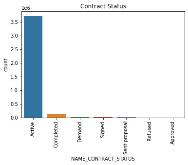

```python
sns.countplot(x='NAME_CONTRACT_STATUS', data=credit_bal);
plt.title('Contract Status');
plt.xticks(rotation=90);
```

```python
apps2 = datasets["application_train"]
apps3= apps[['SK_ID_CURR', 'TARGET']]
credit_joined = credit_bal.set_index('SK_ID_CURR').join(apps3.set_index('SK_ID_CURR'))
```

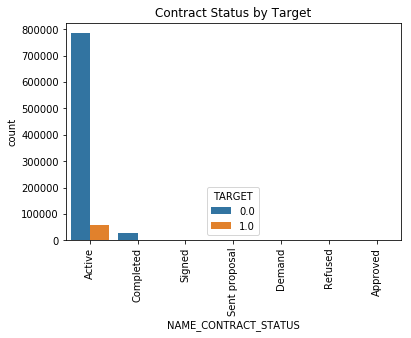

```python
sns.countplot(x='NAME_CONTRACT_STATUS',hue='TARGET', data=credit_joined);
plt.title('Contract Status by Target');
plt.xticks(rotation=90);
```

```python
credit_bal["TOTAL_SPENT_PREV_MONTH"] = credit_bal.AMT_DRAWINGS_ATM_CURRENT + credit_bal.AMT_DRAWINGS_CURRENT + credit_bal.AMT_DRAWINGS_OTHER_CURRENT + credit_bal.AMT_DRAWINGS_POS_CURRENT
```

```python
credit_bal["CREDIT_LEFT_PREV_MONTH"] = credit_bal.AMT_CREDIT_LIMIT_ACTUAL - credit_bal.TOTAL_SPENT_PREV_MONTH
```

```python
credit_bal["AMT_LEFT"] = credit_bal.AMT_TOTAL_RECEIVABLE - credit_bal.AMT_PAYMENT_TOTAL_CURRENT
```

```python
credit_bal['LATE_INSTALLMENT']=["On-time" if x <= 0 else "Late" for x in credit_bal.SK_DPD]
```

```
[Text(0.5, 1.0, 'Times installment was paid after due date')]
```

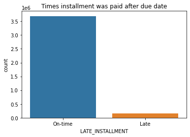

```python
sns.countplot(x="LATE_INSTALLMENT", data=credit_bal).set(title="Times installment was paid after due date")
```

```python
credit_joined['LATE_INSTALLMENT']=["On-time" if x <= 0 else "Late" for x in credit_bal.SK_DPD]
```

```
[Text(0.5, 1.0, 'Times installment was paid after due date by Target')]
```

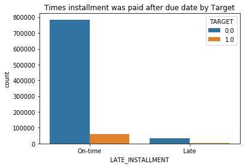

```python
sns.countplot(x="LATE_INSTALLMENT", hue='TARGET' , data=credit_joined).set(title="Times installment was paid after due date by Target")
```

[figure not shown]

```python
bins= [0,2,4,6,8,10]
plt.hist(credit_bal['CNT_INSTALMENT_MATURE_CUM'], bins=bins, edgecolor="k")
plt.xticks(bins)
plt.title('Times installment was paid after due date by Targer')
plt.show()
```

```python
card_bal = credit_bal.groupby(['SK_ID_CURR']).agg(['mean', 'count', 'std', 'sum', 'min', 'max'])
card_bal.columns = [ '_'.join(str(i) for i in col) for col in card_bal.columns]
card_bal.reset_index(inplace=True)
card_bal
```

|  | SK_ID_CURR | SK_ID_PREV_mean | SK_ID_PREV_count | SK_ID_PREV_std | SK_ID_PREV_sum | SK_ID_PREV_min | SK_ID_PREV_max | MONTHS_BALANCE_mean | MONTHS_BALANCE_count | MONTHS_BALANCE_std | MONTHS_BALANCE_sum | MONTHS_BALANCE_min | MONTHS_BALANCE_max | AMT_BALANCE_mean | AMT_BALANCE_count | AMT_BALANCE_std | AMT_BALANCE_sum | AMT_BALANCE_min | AMT_BALANCE_max | AMT_CREDIT_LIMIT_ACTUAL_mean | AMT_CREDIT_LIMIT_ACTUAL_count | AMT_CREDIT_LIMIT_ACTUAL_std | AMT_CREDIT_LIMIT_ACTUAL_sum | AMT_CREDIT_LIMIT_ACTUAL_min | AMT_CREDIT_LIMIT_ACTUAL_max | AMT_DRAWINGS_ATM_CURRENT_mean | AMT_DRAWINGS_ATM_CURRENT_count | AMT_DRAWINGS_ATM_CURRENT_std | AMT_DRAWINGS_ATM_CURRENT_sum | … |
| --- | --- | --- | --- | --- | --- | --- | --- | --- | --- | --- | --- | --- | --- | --- | --- | --- | --- | --- | --- | --- | --- | --- | --- | --- | --- | --- | --- | --- | --- | --- |
| 0 | 100006 | 1489396.0 | 6 | 0.0 | 8936376 | 1489396 | 1489396 | -3.5 | 6 | 1.870829 | -21.0 | -6 | -1 | 0.000000 | 6 | 0.000000 | 0.000000e+00 | 0.00000 | 0.000000 | 270000.000000 | 6 | 0.000000 | 1620000 | 270000 | 270000 | NaN | 0 | NaN | 0.0 | … |
| 1 | 100011 | 1843384.0 | 74 | 0.0 | 136410416 | 1843384 | 1843384 | -38.5 | 74 | 21.505813 | -2849.0 | -75 | -2 | 54482.109375 | 74 | 68127.234375 | 4.031676e+06 | 0.00000 | 189000.000000 | 164189.189189 | 74 | 34482.743620 | 12150000 | 90000 | 180000 | 2432.432373 | 74 | 20924.574219 | 180000.0 | … |
| 2 | 100013 | 2038692.0 | 96 | 0.0 | 195714432 | 2038692 | 2038692 | -48.5 | 96 | 27.856777 | -4656.0 | -96 | -1 | 18159.919922 | 96 | 43237.406250 | 1.743352e+06 | 0.00000 | 161420.218750 | 131718.750000 | 96 | 47531.585759 | 12645000 | 45000 | 157500 | 6350.000000 | 90 | 28722.271484 | 571500.0 | … |
| 3 | 100021 | 2594025.0 | 17 | 0.0 | 44098425 | 2594025 | 2594025 | -10.0 | 17 | 5.049752 | -170.0 | -18 | -2 | 0.000000 | 17 | 0.000000 | 0.000000e+00 | 0.00000 | 0.000000 | 675000.000000 | 17 | 0.000000 | 11475000 | 675000 | 675000 | NaN | 0 | NaN | 0.0 | … |
| 4 | 100023 | 1499902.0 | 8 | 0.0 | 11999216 | 1499902 | 1499902 | -7.5 | 8 | 2.449490 | -60.0 | -11 | -4 | 0.000000 | 8 | 0.000000 | 0.000000e+00 | 0.00000 | 0.000000 | 135000.000000 | 8 | 96214.047088 | 1080000 | 45000 | 225000 | NaN | 0 | NaN | 0.0 | … |
| ... | ... | ... | ... | ... | ... | ... | ... | ... | ... | ... | ... | ... | ... | ... | ... | ... | ... | ... | ... | ... | ... | ... | ... | ... | ... | ... | ... | ... | ... | … |
| 103553 | 456244 | 2181926.0 | 41 | 0.0 | 89458966 | 2181926 | 2181926 | -21.0 | 41 | 11.979149 | -861.0 | -41 | -1 | 131834.734375 | 41 | 181540.703125 | 5.405224e+06 | 0.00000 | 453627.687500 | 296341.463415 | 41 | 216041.154616 | 12150000 | 0 | 450000 | 24475.609375 | 41 | 54198.746094 | 1003500.0 | … |
| 103554 | 456246 | 1079732.0 | 8 | 0.0 | 8637856 | 1079732 | 1079732 | -5.5 | 8 | 2.449490 | -44.0 | -9 | -2 | 13136.731445 | 8 | 18263.380859 | 1.050939e+05 | 0.00000 | 43490.113281 | 135000.000000 | 8 | 0.000000 | 1080000 | 135000 | 135000 | 0.000000 | 8 | 0.000000 | 0.0 | … |
| 103555 | 456247 | 1595171.0 | 95 | 0.0 | 151541245 | 1595171 | 1595171 | -49.0 | 95 | 27.568098 | -4655.0 | -96 | -2 | 23216.396484 | 95 | 56576.242188 | 2.205558e+06 | 0.00000 | 190202.125000 | 144000.000000 | 95 | 72381.965545 | 13680000 | 0 | 180000 | 2136.315674 | 95 | 13508.768555 | 202950.0 | … |
| 103556 | 456248 | 2743495.0 | 23 | 0.0 | 63100385 | 2743495 | 2743495 | -13.0 | 23 | 6.782330 | -299.0 | -24 | -2 | 0.000000 | 23 | 0.000000 | 0.000000e+00 | 0.00000 | 0.000000 | 900000.000000 | 23 | 0.000000 | 20700000 | 900000 | 900000 | NaN | 0 | NaN | 0.0 | … |
| 103557 | 456250 | 1794451.0 | 12 | 0.0 | 21533412 | 1794451 | 1794451 | -6.5 | 12 | 3.605551 | -78.0 | -12 | -1 | 173589.328125 | 12 | 12914.008789 | 2.083072e+06 | 153832.71875 | 200208.921875 | 178875.000000 | 12 | 2035.201576 | 2146500 | 175500 | 180000 | 15000.000000 | 12 | 49195.343750 | 180000.0 | … |

103558 rows × 145 columns

### Target Corelation

```python
card_balTrain = credit_bal.set_index('SK_ID_CURR').join(other1.set_index('SK_ID_CURR'))
correlations = card_balTrain.corr()['TARGET'].sort_values()
print('Most Positive Correlations:\n', correlations.tail(10))
print('\nMost Negative Correlations:\n', correlations.head(10))
```

```
Most Positive Correlations:
 MONTHS_BALANCE              0.035695
CNT_DRAWINGS_CURRENT        0.037793
CNT_DRAWINGS_ATM_CURRENT    0.038437
AMT_INST_MIN_REGULARITY     0.039798
AMT_LEFT                    0.046128
AMT_RECEIVABLE_PRINCIPAL    0.049692
AMT_RECIVABLE               0.049803
AMT_TOTAL_RECEIVABLE        0.049839
AMT_BALANCE                 0.050098
TARGET                      1.000000
Name: TARGET, dtype: float64

Most Negative Correlations:
 CNT_INSTALMENT_MATURE_CUM    -0.023684
SK_DPD                        0.001684
SK_ID_PREV                    0.002571
CNT_DRAWINGS_OTHER_CURRENT    0.003044
AMT_DRAWINGS_OTHER_CURRENT    0.003843
AMT_DRAWINGS_POS_CURRENT      0.005084
SK_DPD_DEF                    0.010538
AMT_PAYMENT_TOTAL_CURRENT     0.012302
AMT_PAYMENT_CURRENT           0.012929
AMT_CREDIT_LIMIT_ACTUAL       0.013823
Name: TARGET, dtype: float64
```